# CONTENTS

### 参与者，场景及舞台隐喻

我们已经发现，动作链与心理互动包括了一些原型角色，诸如：施事、受事、工具、感事与被感。在一个动词性关系中，所有这些都可以并且通常被选作主体或背景。然而，真实世界情景的认知输入也包括了一些没有被选为主体的方面，但这些方面却作为我们会不严格地称之为“后景”（background）的组成部分存在于我们的脑子里。（在Langacker看来，这个“后景”由一大批的认知域构成，参见4.3节）。

一方面，为了解释主体与背景之间，另一方面，解释主体与后景之间的关系，Langacker使用了另一隐喻——＋STAGE＋（＋舞台 ＋）隐喻 。这一隐喻在法国语言学家Tesnière（1959，第48章）的著作中已经有所提及。根据这一隐喻，句中成分的组织与舞台上戏剧中所发生的情况有点相似。后景与戏剧的道具或布景的作用相似，凸显性留给了演员，他们在舞台上四处移动，演说、争斗、厮杀，或者拥抱。将＋舞台＋隐喻应用于普遍的认知知觉，我们就可以把一个事件的场景（setting） 与事件中的参与者（participants） 区分开来，前者是全面而相对稳定的，而后者是较小而可变的，并参与物理接触或心理互动。

当把这种参与者与场景的区别转换为语言表达时，这种区别就清楚地反映在小句结构上了。参与者由主语或者宾语表示，而场景则由状语表示，尤其是表示时间或空间的状语，就像在下面的例子那样：

Susan was eating a banana in the kitchen at nine o'clock in the morning．（Susan早上九点的时候在厨房吃香蕉。）

但是如果认为场景是均质的，那就错了，并与认知解释的要义大相径庭。从其定义上来看，凸显是一种渐变现象，它没有理由只与主体和背景的选择有关。实际上只要看一下位置场景，我们就能很容易地区分凸显的不同程度。对比如下两个句子 <sup>(11)</sup> ：

People drink beer in Munich.（人们在慕尼黑喝啤酒。）

Susan lives in Munich.（Susan住在慕尼黑。）

第一句中地点状语in Munich （在慕尼黑 ）是一个包含了两个参与者（施事people （人们 ）和受事beer （啤酒 ））的动作链的真实场景。而第二句中同样的状语不仅是一个一般的位置后景，而且是与作为句法主体的参与者Susan 相关联的一个必要的部分。换句话说，这里的位置场景起到了可识背景的作用。然而in Munich （在Munich ）不是一个参与者，因为与受事不同，它并没有状态或位置的变化。这种情景由图4.17表示。如图所示，代表句法主体的圆圈并未伴随一个代表背景的在空间上相分离的成分。这是前几个说明动作链和心理互动的图的结构。在图4.17中，圆圈被置于代表第二个成分的方框之内；它好像被“包含”于在个例子里表示场景的第二个成分中。如果我们以意象图式来理解句法，我们就可以说在Susan lives in Munich （Susan住在Munich ）这类句子中的句法关系表示了一种“be in”（在……里）图式或者容器图式，而不是动作链和心理互动中典型的“路径”图式。

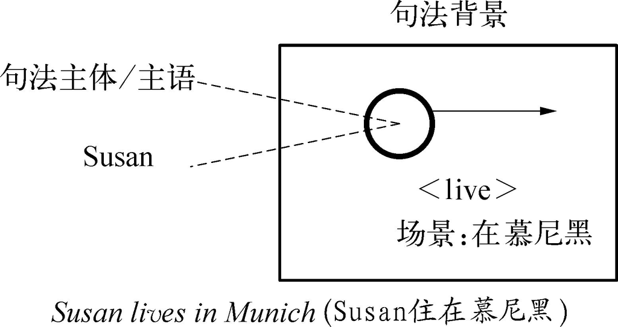

图4.17 作为句法背景的场景

上一节已经提到了一个有关的、但是更复杂的情况。带put/place/set （放、放置）（例如Susan put the banana into the basket （Susan把香蕉放进篮子里 ））的小句型式反映了具有施事-主语、受事-宾语的动作链，但同时也与具有特殊凸显的位置场景有关，这一方位场景必须作为凸显的第三个成分并入句型之内。如何根据句法主体与背景来衡量场景凸出度的问题到目前为止似乎还未解决，因此应进一步探讨。

我们已经看到，场景的凸显程度取决于句法类型的选择。为了进一步说明我们根据梯度来处理场景凸显性时得到了什么，请看以下这组例句：

a．Susan swam in the Channel.（Susan在英吉利海峡中游泳。）

b．Susan swam across the Channel.（Susan游过英吉利海峡。）

c．Susan swam the Channel.（＝例（7），Susan在英吉利海峡中游泳。）

句（a）中施事及句法主体（Susan ）发起了一个动作链，这一动作链中没有包括任何受事，但这一动作链发生于某个特定的场景中（the Channel （海峡 ））；在语言形式上表达为带非强制性状语的不及物结构。句（b）中场景更加具体，有两个边界，完全被施事/主体穿过。所有这些含义都是介词across （穿越）表示的，结果是这个场景比句（a）中的场景更为凸显。最后的句子（c）中，这个介词丢了。认知解释远不认为这只是句（b）的形式变体，而认为the Channel （海峡）获得了句法凸显，已经愈加不是单纯的场景了。场景被看作更像是在与施事-主语的互动中的一个参与者，例如是一个必须打败的敌人，这反映在名词短语类宾语用法中。

如果将场景提升到宾语的地位（正如我们目前所讨论的）看起来还很自然，那么认为场景可以作为主语出现就更大胆了。让我们看看下面的例句（Langacker1991：346以次）：

The garden is swarming with bees.（＝例（8））

在这个句子中，我们不难把句法主体或主语（the garden （花园 ））看作位置场景，而句法背景位置则由bees （蜜蜂 ）占据。它的认知解释在图4.18中得到了证明。其基本原则又是句法主体和背景之间的容器-内容关系。这与图4.17所说明的Susan lives in Munich （Susan住在Munich）这类句子结构相对应，但有一个关键的不同之处，那就是参与者和场景的凸显已经被倒过来了（对比图4.18中相反的粗黑线与黑线）。场景（the garden （花园 ））在容器-内容关系中占有凸显地位，表达了类似“是飞舞行为的场景”的意义，其中涉及的蜜蜂则是句法背景。

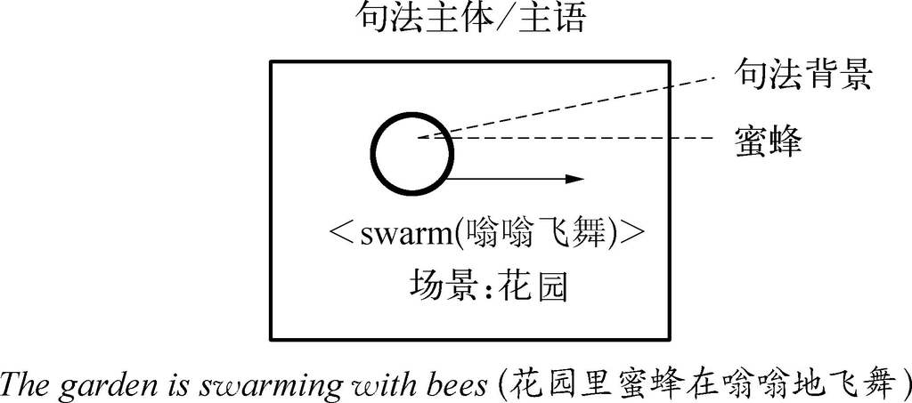

图4.18 作为句法主体（主语）的场景（改自Langacker1991：345）

“场景-主语”（正如Langacker所称呼的）这种例外可能出现，是因为它们不是参与者，它们的基础还是场景的一个可辨认方面。这与类似如下的例句不同：

There was a loud bang.（＝例（9））

There are at least five Asian takeaways in our town.（我们镇上至少有五个亚洲外卖餐饮店。）

这些大家熟知结构中的there 成分，通常被解释为傀儡成分，或者解释为结构主语或形式主语。然而所有这些解释与“所有语法成分都有概念内涵”这个基本认知原则相矛盾。这也就是为什么Langacker同意别的对there 构式的研究（如Lakoff1987：462以次），认为there 被用来表达一种场景，尽管是一种抽象的或不确定的场景，而且这种场景充当主语。问题在于，作为主语，there 在句中应赋予最高的凸显度，而这与我们对于以上两个句子和类似用例的直觉是相反的。另一个看起来似乎是Langacker暂时解决了的问题是，there 构式中的动词形式与句法背景、而非there 主语一致（看上面的第二个例子）。我们的结论是，对there 句的这种解释的处理应谨慎一点儿 <sup>(12)</sup> 。

### 附记：图式主语与原型主语

Langacker试图将there 确立为句法主体的努力，必须在一个更为广阔的语境中思考。原型概念对于认知语言学的巨大影响，鼓励学者们不仅将它用来解释词汇范畴的结构（参见第1、2章），而且也用来描述语法现象。结果，词类、句型、小句结构都用原型范式进行过分析，也收集了一些有说服力的特征来区分名词、陈述句和及物句等的最好样本与较差样本 <sup>(13)</sup> 。对于小句主语来说，结果是——并出乎意料——典型的主语是及物小句中的施事，所有其他主语都以某种方式偏离这一定义。

然而，尽管小句成分的典型分析满足于这种描写，但对于Langacker来说，这仅是其对于所有主语——典型的和非典型的——进行认知定义探索的起点。概括一下本节中他所进行的对于动作小句的讨论 <sup>(14)</sup> ，我们可以区分出以下主语概念：

· 主语是施事原型角色的实现（解释了及物行为小句中的施事主语）

· 主语是动作链中第一个被表达出的成分，即作为动作链特征的能量流的上游（加上行为小句中的工具及不及物受事主语）

· 主语是主动的参与者（加上心理活动中的主语）

· 主语是句法主体（加上场景中的显著成分）

这一结果就是（或是近似于）Langacker所说的与纯粹的原型描写相对的主语图式定义（schematic definition） 。这一图式性或普遍有效性概念——当然一直是科学与哲学的目标之一——渗透于Langacker整个思想中，正如我们将在下一节中看到的那样。

### 练习

1．下列句子中，哪些是表达了动作链，哪些表达了心理互动，哪些则将这两种认知结构连接在一起？

Dad opened the box with a knife.（爸爸用一把刀子打开了那个箱子。）

Little Sue wants a mountain bike.（小Sue想要一辆山地车。）

Jack brings along the most recent CDs.（Jack随身携带最新的CD唱片。）

Tom sold his old Chevy to a friend.（Tom把他的旧雪佛兰卖给了一个朋友。）

Diana was sipping her long drink.（Diana正猛吸一口饮料。）

She was dreaming of her Italian boyfriend.（她正梦见意大利男朋友。）

Sorry，I have forgotten your name.（对不起，我忘记了你的名字。）

2．正如已经提到的，我们可以认为所有动作链都至少包含有三个成分（施事，工具，受事）。考察下面的二成分结构，并试着找出可以加上的工具：

Susan is picking strawberries.（Susan在摘草莓。）

Susan is reading a book.（Susan在读书。）

Susan turns the key.（Susan转动那把钥匙。）

Susan kicks the ball.（Susan踢那个球。）

Susan sings a song.（Susan唱一首歌。）

解释一下为什么在这些句子中工具没有被表达出来。

3．为了描述动作链，Langacker实际上提供了两个隐喻：＋BILLIARD BALL＋（＋台球＋）隐喻和可以被称之为＋RIVER＋（＋河流＋）的隐喻（这是他的能量流概念的基础）。你认为这两个隐喻中的哪一个更有用？

4．小句句型并不只是表达了动作链和心理互动，它们还反映了一种“容器-内容”或“部分-整体”关系。试用这些意象图式来解释如下例句：

The bus holds 40 people.（这辆车可以载40个人。）

Our village consists of a church and three cottages.（我们村里有一座教堂和三所别墅。）

The area abounds with pubs.（这个地区到处都是酒吧。）

This anthology assembles a lot of unknown poems.（这部诗集里有很多不知名的诗。）

5．出于语法研究的目的，动词通常被区分为动态和静态动词意义（或情状类型）。研究一下这种分类（如：在Quirk 等1985：200以次，或者Greenbaum 和Quirk1992：55 以次），并且讨论它何处与Langacker动作链、心理互动及容器-内容结构区分相同。

## 4.3 其他类型的凸显及认知处理

紧随前面两节举隅性地讨论了主体/背景对比之后，本节的目标是结束这一研究并将其成果融入由Langacker建立的认知语法的框架。鉴于这是一个非常全面的理论，本节只讨论一些核心概念：认知单位、认知域和词类层面、小句及言语事件中的侧显。

从认知的观点来看，大多数的语言表达的基础都是对现实世界中物体或情景的感知。这种输入最初也许是一种知觉刺激的混乱的集合。在这种未加工的认知输入可以被“翻译”成语言表达之前，它们需要组织成更为具体的认知单位。如果我们试图研究这些翻译中的认知过程，最迫切的问题是：

· 认知单位是如何建立的？

· 这些认知单位是如何被翻译成存在于单词中的词汇范畴的？

· 当对一个更为复杂的情景进行概念化并用语言来表达时，这些词是怎样组合在一起的？

下面，我们将试着回答这三个问题，我们的说明以Langacker的框架为基础。

### 认知输入、认知单位及认知域 <sup>(15)</sup>

即使人们认为——正如我们刚做的那样——一种情景的认知输入由大量不同的刺激组成，这种输入也会立即处于控制之中。在第1和第2章中我们已经谈到一种解释这种控制过程的方法。在那里，我们认为由于这些最显著的物体生物和人所具有的完形特征，它们易于被看作某种基本层次范畴的成员。然而Langacker却持有一个更为抽象的观点，他认为每一个刺激都按照他所说的认知域 （domains）来评价。根据他（Langacker1987a：147）的说法，认知域是“刻画语义单位（即下面小斜体大写字母［汉字用粗楷体］表示的‘认知单位’）的语境”。最基本的认知域是空间和视觉、温度、味道、压力、痛感及颜色。

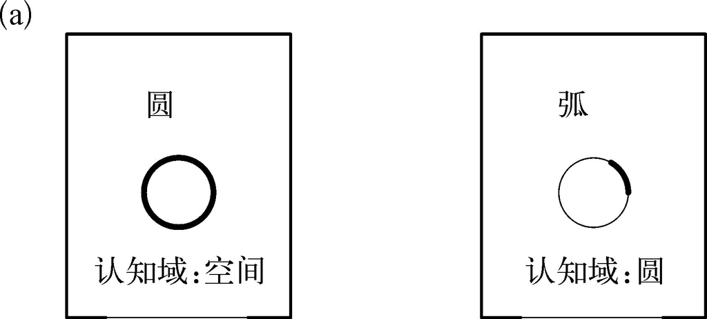

图4.19 认知域和认知单位：圆和弧（Langacker1987a：184）

这些基本认知域的功能，尤其是空间认知域，在涉及几何形状时尤为明显。图4.19的认知单位圆 及弧 说明了这一点，用方形代表认知域，黑粗线代表认知单位。图（a）说明，圆 这一认知单位是如何在二维空间认知域中得到刻画的。如果应用主体/背景对比，那么圆是主体或侧面（profile） ，而认知域则起到了背景或基底（base） 的作用。（Langacker用“侧面”和“基底”给主体/背景对比引入了另一个隐喻，这一隐喻对于描述这种认知过程中的对立似乎尤其适用。）与圆 不同，弧 这个认知单位仅用空间认知域来定义是不够的。如果弧 仅用空间认知域来侧显，它只代表了一条曲线，而不是圆的一段。这也就是为什么在图（b）中的认知域不是一个二维的空间，而是一个圆的概念。也就是说，弧 的定义需要两步，每一步都体现了主体/背景分离的实例。在第一层，圆 侧显为一个认知单位，而它又在第二层为弧 提供了认知域。因为“圆”是更具体的因而也是与弧 更直接相关的认知域，圆就被称弧的基础域（primary domain） 。

关于更具体的认知域如何来自基本认知域，弧 仅是一个简单的例子。现在让我们看一个更复杂的例子，它说明不同认知域是如何同时出现的。我们来看一下BODY （身体） 这个认知单位。就其形状而言，这一单位是在“空间”认知域中刻画的，但它也针对“颜色”、“温度”之类的其他基本认知域进行具体化。这样，这些基本认知域构成了身体 这个认知单位矩阵。身体 这个认知单位接下来又为手臂 提供认知域，手臂 又为手 、肘 等提供认知域。手 这个认知单位又为更具体的认知单位手指 提供认知域，最后，手指 可看作是被侧显的指关节 这一单位的（基本）认知域。

然而，有的认知单位是不能根据“空间”、“温度”或“颜色”这些基本认知域来定义的。Langacker所举的例子（1987a：185）是叔叔 这一认知单位，它是根据“人类”，“性别”，“出生”及“生命循环”，“父母/子女关系”及“兄弟姐妹关系”这些认知域来定义的。考察这些例子，我们为叔叔 这一认知单位找到了更具体的基本认知域，宽泛一点说的话，它是由人、兄弟及父母这些概念来定义的。

这一论述表明，Langacker的认知域（或语境）概念比1.3节提出的语境概念更宽。在那里，我们将语境定义为有关系的词汇范畴（大部分是基本层次范畴，如海滩、沙子、铲子 及小桶 ）之间互动的心理表征。对于Langacker来说，语境包括更基础的或更抽象（在这个词朴素意义上）的认知域，如空间、视觉、温度、味觉及颜色。如果这些认知域中的几个认识域被用来侧显同一个认知单位，其结果就是一个基本认知域的矩阵，这表面上像是正统语言学根据特征对意义的描写。所不同的是，在Langacker看来，这些基本认知域并不是从单词的意义中“派生”或“抽象”而来的，而它们之所以“基本”，意思是它们表征了基本的人类体验，而且不可分解为别的更基本的认知域。换句话说，它们是我们接近并把握世界的认知工具。

这种认知域矩阵是基底（或背景），认知单位则相对于认知域矩阵被侧显（为主体）。这其中的过程是真正前语言的，说的是原则上它并不决定将用何种语言表达来表现该认知单位。因而，以上暂时标为指关节 的认知单位可由名词指关节 来表示，但在一定情景中可包含于敲 这一动词表示的行为中，因此可由动词敲 来表示。与此相似，肘 这一认知单位可由名词肘 来表示，但在短语“弯曲手臂”中，也会由动词弯曲 来表示。正如这些例子所示，认知单位转化为认知范畴（我们引入的第二个问题）与词类的选择有密切的关系。其中起支配作用的原则还是凸显原则，这里也就是选择直接相关的认知单位来表达一个特定的情景，这也许是认知处理中对主体/背景对立给人印象最深的应用。

### 侧显物体、人及关系：词类的浮现 <sup>(16)</sup>

为了更详细地研究词类选择的过程，我们首先假定已经侧显了一个复杂的、由以某种方式属于共同关系的三个个体组成的认知单位。对照图4.20，其中的图（a）图解了这种认知单位（个体由小圆圈代表，同类关系由连接它们的短线表示）。

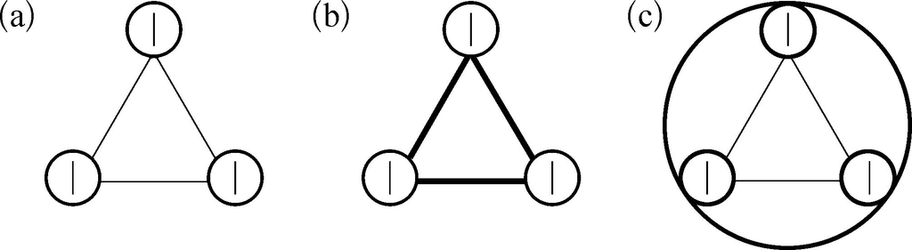

图4.20 认知单位group （组）的侧显选择（改编自Langacker1987b：69）

图（b）和图（c）代表了这个认知单位转变成认知范畴的两种方式。如图（b）所示，将认知单位作为基底（或背景），就有可能凸显三个个体之间的关系。这一被侧显的关系（profiled relation）可以用副词together （一起 ）表达（正如Langacker所提出来的那样），但也可以用形容词common （共同的 ）或者由动词share （共有 ）来表示，就像在下面的几个例子那样：

The three people were together.（三个人在一起。）

The three people have many common views and hobbies.（三个人有一些共同的观点及习惯。）

The three people share their views and hobbies.（三个人共有一些观点及习惯。）

用更概括的话说，我们可以认为共同关系及其他认知关系可以由动词、形容词、某些副词及——最后——介词来表达。

第二种侧显选择（图（c）），将这个认知单位作为一个整体包括在内，包括了涉及的各个个体及其关系，实际上侧显了包括其所有成分和它们之间的相互联系的整个认知区域。这个被侧显的认知区域（profiled cognitive region） 由一个名词，即词项group （组 ）来表示；它也可以由一个代词或The Haydn Trio （如海顿三重奏）这种更复杂的名词性短语来表示。

诚然，观察GROUP （组） （或KNUCKLE （指关节） 或ELBOW （肘） ）这一认知单位而注意到的这种侧显选择并非那么经常出现。一般来说，一个想到的情景的不同方面，或者适合于“名词性”的侧面（即由名词或代词所表示的侧面），或者适合于关系的侧面（动词、形容词及介词）。例如，想一想做饭的情景：相当清楚，用来做饭的配料和锅碗瓢盆是由名词来表示的；切、翻炒、下料这些基本行为则是由动词来表示的，但有时一些更特定动作也可能在描述行为的动词和描述工具的名词（如mix （搅拌） 还是mixer （搅拌机） ）之间进行选择。比名词/动词选择更常见的是在两种关系侧面之间的选择，如位移动词及介词之间的选择，如下面的例句：

1．（a）She entered the room（她走进了房间）

（b）into the room（进入房间）

2．（a）He left the room（他离开了房间）

（b）out of the room（房间外）

3．（a）She climbed the tree（她爬上了树）

（b）up the tree（在树上）

这些成对的位移动词及方向介词也很好地证明了这样一个事实：关系侧面有一个内在的主体/背景结构。如4.1节中所讨论的一样，像out （外 ）、up （向上 ）（还有into （进入 ））这种介词描述了可移动的射体（主体）及静止的界标（背景）之间的关系，这对于位移动词来说也是如此。

问题是：为何相同的射体/界标关系可以由两种方式——通过动词及介词——表达？或者更概括一点，如何解释词类之间的变换？Langacker寻找一种认知解释，认为词类之间的选择与我们的认知能力尤其是我们扫描认知输入的能力有关系，甚至是由这种认知能力决定的。

### 扫描及词类差异 <sup>(17)</sup>

假定的扫描基本过程是对相似的和不相似的对象（如白色和黑色（或彩色）的点）的识别过程（（Langacker 1987a：101以次）。很显然，这是记录图画或一些别的文件中的点的扫描器的工作原理。扫描过程开始启动后，累积的信息可以在电脑屏幕上看到或变成打印出来的资料。与这种技术处理相比，正如Langacker所设想的那样，人类的认知处理更灵活，并且可主要区分为总括扫描（summary scanning） 和次第扫描（sequential scanning） 。

在总括扫描中，一个情景的不同方面，像反映到一个认知单位里，被一个接着一个地检验，数据则被不断合计，扫描过程完成时，所有与这个认知单位有关的方面就作为一个整体集合在观察者的头脑中，就像一个单个的“完形”一样（参见1.2节）。这种在很大程度上和电脑扫描对应的扫描适合于名词性侧面，因为它能同时获得一个整体的认知领域，并解释作为名词典型特点的这种意义的综合性。但是正如我们将要看到的，总括扫描也可以生成由介词或形容词所表达的一些关系侧面。

与总括的方法相比，次第扫描在应用时有更多的限制：实际上它只用于事件（即包含变化的过程）。至于总括扫描，有关的认知单位被连续地检查，但数据仅在事件的某一阶段被合计，当合计完成时，在事件的下一阶段，一组新的扫描数据被收集，如此继续下去。结果，我们得到的是一系列互不相同的小事件，这些小事件因而表现了隐含在事件中的变化。这种结果与看电影或录像相类似。就像显示的速度使我们不能区分电影的单个画面一样，认知处理的甚至更高的速度则意味着被感知事件是一个不间断的行为。就像这种描述所表明的那样，次第扫描也就适合于时间关系，并主要由（限定）动词来表示。这一区别最适合用涉及射体/界标明确对立的例子来解释，这将我们带回了列举在例（1）—（3）中那几组位移动词与介词。图4.21解释了第一对中的不同扫描类型，即动词enter （走进 ）和介词into （进入 ）；也包括了相关的介词in （里 ）。

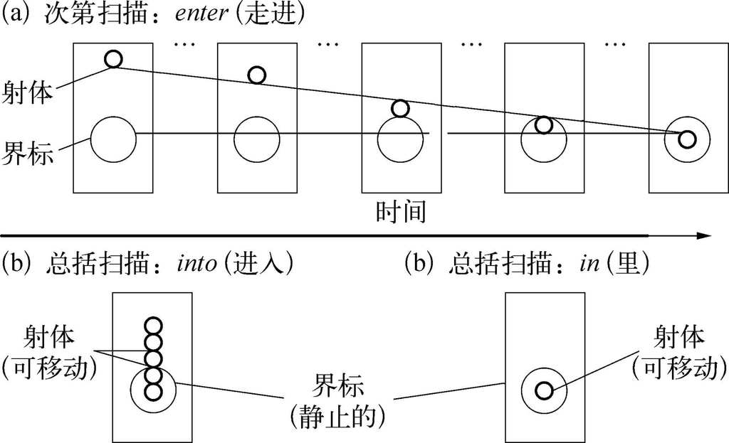

图4.21 enter （走进）、into （进入）和in （里）的次第扫描和总括扫描（改编自Langacker1987a：144，245）

这种图式化表示对于次第扫描似乎更有说服力。正像在电影中一样，过程被分成一个个画面，代表了无数的处理阶段。每一个阶段都以一定的射体（进入的人）和界标（房子）之间的特定关系来界定，与相邻画面有着细微的差别。连续地看来，这些处理阶段反映了射体进入界标的位移。

### 句法主体及背景回顾

把认知域侧显为名词，关系侧显为动词、形容词及介词提供了从中建立连贯话语的原材料。这就意味着现在我们可以讨论开头所提出的三个问题中的最后一个问题，并回答词及其代表的概念是如何结合在一起以组成小句及句子这个问题。这也将我们带回了4.2节中关于小句句型的讨论。为了给出一个关于认知处理在此阶段所达到结果的范例，让我们想像我们正在处理这样一个情景：有一个女孩（Susan）在准备一道希腊色拉。为了把握已经进行的认知过程，我们可以作如下假设：希腊色拉情景已经激发了大量的认知刺激；这些刺激已经在它们与空间、味道这些基本认知域对比中及在与食物、蔬菜、容器（后者是碗 的基底）这样一些更具体的认知域的对照中得到侧显；剩下的认知单位因情景的相关性而被筛选出来（例如，滤除无关的因素：就Susan 而言，她穿着牛仔裤；就油 而言，可被用作燃料）；最后一步是认知单位被侧显为认知区域（名词）或关系（动词、介词）。结果如图4.22所示。

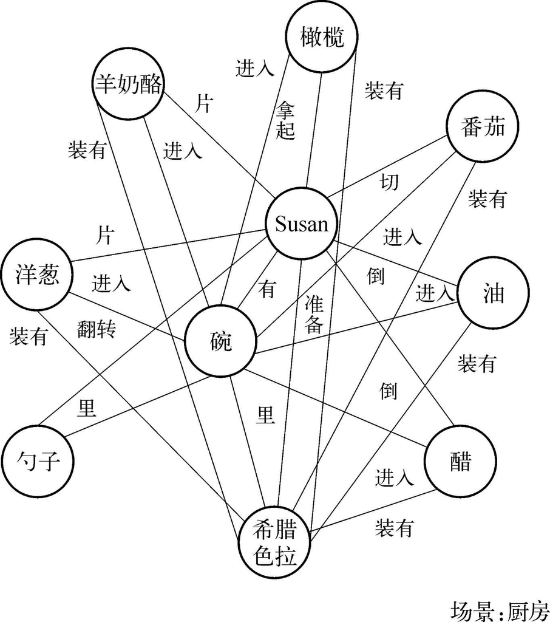

图4.22 希腊色拉情景的认知互动网络

在这个图中，背景——厨房及其中的家具及设备与做色拉无关的多余功能——已经被划出作为场景而忽略不提。圆圈表示名词性侧面（其中的人物、配料、所用容器及实际产品——希腊色拉），关系侧面则由连接圆圈的线及各个动词及介词标示。如果我们回忆一下舞台隐喻，就很容易发现，被侧显的名词性成分类似于舞台上的演员，而被侧显的关系则类似于演员之间的互动，或者更一般地说，名词代表了此情景中的参与者，动词与介词代表了他们之间的互动。Langacker在谈论互动网络（interactive network） 时，对此是了然于心的。

这又引入了另一个隐喻，意思是参与者可以通过很多路径联系起来，而只有其中的一些参与者被选作句子组成成分，如图4.23所示。4.23的图（a）是图4.22的图式变体，而图（b）则显示了相互联系的参与者之间的某种组合是如何被选作小句句型的基础的。正如我们从4.2节所知道的那样，这个选择过程由角色原型、动作链及参与者间的心理互动来控制，外加可以把场景作为参与者容器的辅助手段。其结果是一个这样的句法结构：主语做主体，可能有但并非一定有宾语；如果有宾语，则是起背景作用。回到图4.22及希腊色拉情景，我们可以预期：说话人或者会把含有一个施事-主语的一般动作链作为句法主体，而把一个受事-宾语选为句法背景（下面的例（a））；或者，他会选择更具体的连续动作链，在这个动作链中，施事/受事链和施事/受事/位置链结合在一起了（例（b））；第三种可能性是把场景-主语合并为句法主体（希腊色拉），而这个句法主体和“容器-内容”关系中作为句法背景的一个或几个受事角色相联系（例（c））：

a．Susan is preparing the Greek salad.（Susan在做希腊色拉。）

b．Susan puts the oil and the vinegar into the bowl，stirs them，adds onions，tomatoes and olives and puts a large slice of sheep's milk cheese on top．

（Susan将油和醋倒入碗中，搅拌了一下，加入洋葱、西红柿和橄榄，并在上面放了一大片羊奶酪。）

c．The Greek salad contains onions，tomatoes，olives and sheep's milk cheese.（希腊色拉中有洋葱、西红柿、橄榄和羊奶酪）。

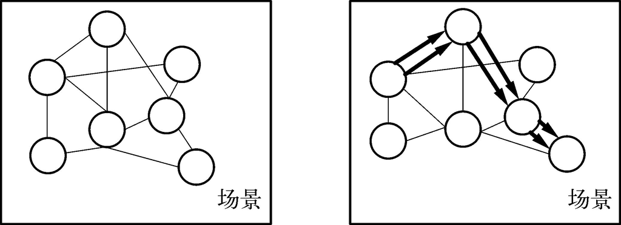

图4.23 互动网络及动作链/句子成分的选择（根据Langacker1990a：219的图式表达）

既然我们已经造出了几个与希腊色拉情景有关的实际存在的句子，我们就会感到凸显原则被证明在回答我们开始所提出的三个问题时有用，而结束这个主题的讨论。本章的结语部分将说明主体/前景对比也可以应用到语用学领域。

### 视角配置

Langacker（1995：9以次）认为凸显是指导认知处理的三原则之一，其他两个与之契合的原则是具体性及视角。特定性原则（specificity） 决定了我们同周围世界接触的层次（基本层次，下位层次或上位层次；参见第二章） <sup>(19)</sup> 。第二条附加原则，即视角，Langacker更经常地称之为视角配置（viewing arrangement） <sup>(20)</sup> 。这一概念最好用前面提到过几次的＋STAGE＋（＋舞台＋）隐喻来理解。这一隐喻主要用以描述“舞台上”所发生的事，即行为的参与者必须从场景中区别出来（参见4.2节）。然而＋STAGE＋（＋舞台＋）隐喻也将观众考虑在内，视角配置也就是从这个要素——即台下的观众与台上的事件之间的关系上——得到体现。

正常的或“标准”的配置是观众（说者/听者）及台上事件之间的关系并不直接表达出来。句子表达的是台上事件，这也就是为什么第三人称视角成为常态的原因。另一个也很常见的视角是以自我为中心的视角配置。这时说者/听者与事件之间的关系显性化，并以第一人称指示代词指说话人，用第二人称指示代词指听话人。其他指示（或索引）词，如here （这里 ）、now （现在 ）和this （这个 ）以及其他的限定词通常也被看作是表示了与说话人“视角位置”参照。对比以下例句，其中句（a）表达了标准视角配置，（b）、（c）则是自我中心的变体：

a．（Where is the vinegar？）It is on the table.（醋在哪里？它在桌上。——未表达与说话人/听话人的关系）

b．I can see the vinegar.（我能看见醋。——表达了与说话人的关系）

c．Have you seen the vinegar？（你看到醋了吗？——表达了与听话人的关系）

Langacker认为，视角配置也为其他一些语用现象提供了一个认知解释。这些现象包括了一些主要的言语行为如断言（如（a）中的It is on the table （它在桌上 ）这样典型的台上话句）和命令（原型为说者在自我中心的视角配置中说话人向听话人表达的指令行为，如 Please pass the vinegar （请把醋递给我 ））。此外视角配置还被认为包括Langacker所称的言语行为的心理方面，这些方面包括语用学的一些基本原理，如Grice的合作原则及Searle的成功言语行为的得体条件。

但是怎么可能把这些不同的方面归在视角配置中，并且又在多大程度上可能取决于说话人的位置？回顾一下前三章的讨论，得到以下的解决方法，也就在意料之中。台上事件与台外观众（说者/听者）之间的关系可以解释为主体/背景的一个实例。实际上，Langacker（1991：498）这样说：

应该认为背景基本上等同于有利位置，从这个位置上，说话人和听话人对由名词句或限定小句产生的内容进行概念化。

换句话说，说话人所处的背景不仅取决于他的地理、时间、社会、年龄、性别等背景因素，同时也取决于他为确保言语行为在交际中取得成功的心理状态。

为了将语用因素溶入自己的理论框架中，Langacker独创了说者/听者与背景之间的联系。他因此提出了一个详尽的“背景”概念，即台上事件与背景之间的关系是如何通过时态、语气、名词性限定语及不定代词来建立的 <sup>(21)</sup> 。至于在众所周知的语用描写之外，它是否还产生了言语行为及会话含义方面的很多解释性细节，则是另一个问题。

作为这一章的总结，图4.24提供了一个概貌，它将说明Langacker框架中凸显原则的普遍性。通过扩充和深化主体/背景的概念，他提出了一个迄今为止最全面的认知观。但是为了公正地评价当今的认知语言学的地位，我们还需要看一下其他的一些理论，尤其是那些强调了一个在Langacker的著作中不那么明确的概念（即注意力概念）的理论。

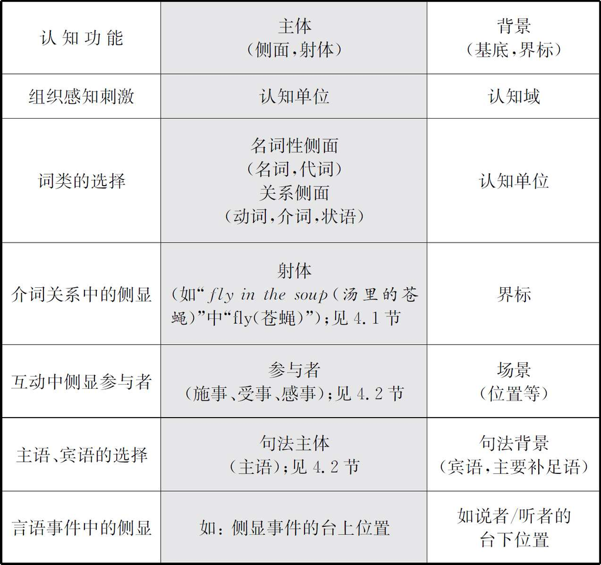

图4.24 Langacker认知语法中主体/背景分离的主要应用概览

### 练习

1．侧显下面的认知单位时，激活了哪些基本认知域（空间、温度、味道、压力、痛感、颜色）：DOG （狗 ），CHAIR （椅子 ），BALL （球 ），APPLE （苹果 ），ICECREAM （冰淇凌 ），SOUP （汤 ），KISS （吻 ）？在每一个例子中，哪一个认知域是特别重要的？

2．认知单位的侧显通常经过许多阶段，涉及基本的和更具体的认知域。对于侧显TOE NAIL （脚趾甲 ），KEY HOLE （FRONT DOOR ）（（前门）钥匙孔 ）和WINDSCREEN WIPER （汽车挡风玻璃雨刷 ）时，哪些认知域起了作用？

3．上臂和下臂之间的区域可以用名词性范畴ELBOW（肘） 或动作性概念BEND（弯曲） 来侧显。指出以下头部由箭头所示各部分在特定条件下是怎样用名词性或动词性范畴来侧显的。

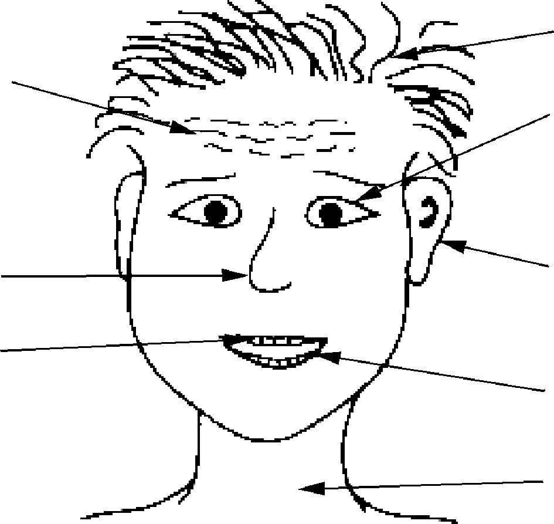

4．为下面的一种情景画出图4.22那样的互动网络：BEACH LIFE（海滩生活） （又见图1.14），ROAD ACCIDENT（公路交通事故） ，WEDDING（婚礼） 。并且指出合适的动作链。

5．以下各句怎样用视角配置，即台上/台下对比来解释：

Peter married that beautiful Chinese girl.（Peter娶了那位漂亮的中国姑娘。）

Did you attend the wedding？（你参加婚礼了吗？）

Then you must have seen her wonderful dress.（那你一定看到了她那套迷人的礼服。）

It must have cost a fortune.（它一定很值钱。）

Like all the other guests，I was fascinated.（和所有其他的客人一样，我被迷住了。）

### 进一步阅读建议

4.1节

介词研究是许多第一代认知语言学家关注的重点。除了下面注释中提及的专著以外，我们还要提到Cuyckens（1991），Schulze（1988），和由Sinha主编的《认知语言学》特刊（1995）。更近一些的分析可以参见Taylor（2002，第11章）。

(1) 有关主体/背景分离主要方面的基础性介绍可以在大多数讨论视觉感知的教科书中找到，如Yantis（2001）及Gordon（2004）。

(2) 对于主体及前景的典型特征的总结，见Talmy（2000/I：315以次）和Schmid（待刊）。

(3) 有关意象图式的文献，见第2章，第11条阅读注释。

(4) Lakoff的总结（1987：416以次）比Brugman 1988年出版的硕士论文更容易找到。亦见Taylor（1988）有关over（在……上）和其他英语介词及意大利介词的讨论及Taylor（2002：474-479）的讨论。

(5) 有关介词in（在……里）的十分有用的研究以及在分析位置关系及其扩展方面十分重要的一些基本理论问题，见Vandeloise（1994）。

(6) 本章的内容主要基于Lakoff（1987：435以次），但是在以下的方面有所不同：不把（纯粹的）意象图式看作是概念隐喻的源头，而将它们作为映射域的构成部分。见3.1节。

4.2节

Langacker（1991：第7、8章）提供了本节所讨论问题的最全面的看法；更简短的说明，见Langacker（1990）。亦见Taylor（2002，第21章）。

(7) 有关配价理论的介绍可以看Allerton（1982）的前两章和Herbst等的引言部分（2004：XXIII-XXXIII）。论旨角色在转换生成语法中的功能，见Radford（1988：372以次，2004重印），语义角色的应用观，见Quirk等（1985：740以次）。

(8) Talmy动力观点，见Talmy（2000/I：409以次）。

(9) 在这儿，与Halliday的及物性理论作一对比将是很有趣的。因为后者根据不同的参与者将过程区分为不同的种类：见Halliday（2004：106以次）。

(10) 也可以比较一下Newman（1996）关于动词give（给）的像专著一样的认知语言学研究。

(11) 有关方位状语的不同地位，在传统语法中也有描述（如Quirk等1985：730以次），在格语法和配价语法中也有相关内容，见Fillmore（1968）和Halliday（2004：149以次）对于环境成分的论述。

(12) 对于会德语或荷兰语的读者而言，研究一下这种解释是如何分别扩大到无指的德语es和荷兰语的er，将是十分有趣的；见Langacker（1991：351以次）。亦见Lakoff（1987：462以次）对于there构式的认知解释。

(13) Taylor及Maclaury（1995：第8至12章）和Taylor（2002，第8章）最详尽地讨论了将原型理论应用于句法及其他语言现象的情况。

(14) Langacker为了将被动句纳入到他的主语和小句结构的图式定义，他假设：用来形成被动式过去分词的语素ed颠倒主动小句的主体/背景结构，它将句法背景（直接宾语）变为被动句的句法主体（主语）。参见Langacker（1991：200以次）。

4.3节

Langacker（1987a/1991）两卷本《认知语法基础》包含了他理论的最全面的阐释。他的两篇文章，（1987b）和（1990），概括了本节的部分内容，而三篇更近的文章（1992，1993，1995）简明地概括了他的理论及其在一些特殊问题上的应用。另一些有用的资料还有Langacker（2000）和（2002），每一本都有对此前发表的12篇文章的修改稿。Langacker（2001）提出了他的话语理论。

与4.1节和4.2节的阅读建议相比，下面的注释旨在指出Langacker著作的有关部分，这些部分在我们看来有助于我们的一些讨论顺利进行。

(15) 对认知域概念和在认知域中侧显事物等概念的理解，主要见Langacker（1987a：147-150和183-186），对范围概念理解，见Langacker（1987a：117-120）。亦见Taylor（2002：192-201）和Croft及Cruse（2004：15-21）。

(16) 关于名词性侧面和关系侧面的本质，见Langacker（1987a：198，214-222，244-249）。亦见于Langacker（1987b：58-63，68-69）和Taylor（2002，第11章）。

(17) 关于总括扫描和次第扫描的核心概念的介绍，见Langacker（1987a：144-146）。关于动作性过程扫描和“非时间”关系含义概述，见1987b（70-75）。关于（1987a）的各个章节，参见以上注释16。关于扫描过程有趣的技术性方面的讨论，见1987a（101-109，209-213）。

(18) 扫描也被认为与动词的限定形式（前文已讨论）和非限定形式之间的区别有关。关于它们的地位，及其在复杂动词形式中与助动词之间的互动，见Langacker（1987b：75-89）和（1991：第5章第2节）。

(19) Langacker用“打碎玻璃情景”（Floyd breaks the glass （Floyd打碎了玻璃） ，等）解释了具体性的可能程度。见Langacker（1991：296以次）。

(20) 关于视角配置的主要观点，见Langacker（1987a：122-132）。对此话题的继续讨论，见Langacker（1991：494-506），在此就他的立场与公认的语用学观点进行了对比。

(21) 对背景化现象恰当的介绍，见Langacker（1991：89-91和193-197）；关于由限定词引起的背景化研究，见Langacker（1991：96-125）；关于助动词的背景化功能专题研究，见Langacker（1991：第6章）。有趣的类似讨论，见Halliday（2004，第4章），它把时态、语气和句型解释为人际语言功能的语法实现。

# 第五章 框架及构式

## 5.1 框架与脚本

在更广阔的认知语境中来分析个别语言现象的必要性在本书许多章节中都出现过；范畴被合成为认知模型，情感概念被扩展成情节，而小句句型也被看作处于互动网络之中。“框架”概念还为拓宽词汇及语法分析的范围提供了另一种认知方法。

### 框架与视角

框架这一概念由Charles Fillmore于20世纪70年代中期引入语言学，它的基础是所谓的“商务事件”框架 <sup>(1)</sup> ，“商务事件”至今仍是他的经典范例。为了理解这一框架，设想一下可用英语动词“buy ”（购买）描述的情景的各个方面。在初始状态，有一个人A有钱，而另一个人或机构D有A想要的货物。假定两个参与者就货物的价钱已达成协议，A将一定数目的钱付给D而D出让货物。最后的结果是A拥有货物，D拥有钱。暂不考虑作为某种先决条件的协议，那么，我们可以说，BUY（购买 ）这一行为范畴至少可参照另外四个范畴，即BUYER（买者 ），SELLER（卖者 ），GOODS（货物 ）和MONEY（钱 ）。

BUY（购买 ）的框架（frame） ，即这些互动范畴的结构概括为图5.1。（框架用［］括号表示）。为buy （购买 ）设定一个框架看起来至少有两个优点：一个框架可以说明不同的小句句型，还可以应用于不同（但有关）的动词，如sell （出售 ）、cost （花费 ）、pay （支付 ）、charge （收费 ）。先看一下下面这个句子，它是buy 可以出现的句法类型的例句：

1．David bought an old shirt from John for ten pounds.（David用10英镑从John那儿购买了一件旧衬衫。）

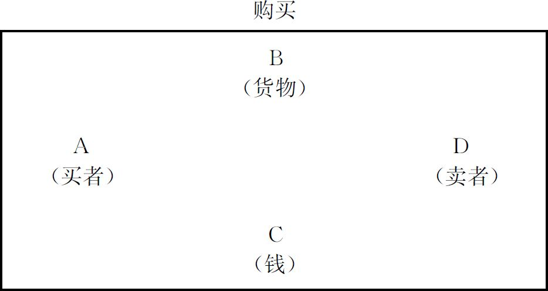

图5.1 ［购买］的框架（根据Fillmore 1977a：104）

在这个句中，不难看出，［购买］框架的4个成分全都出现了，并填充进不同的句法槽：买者 （David）作主语，货物 （一件旧衬衫）作直接宾语，卖者 （John）作第一个状语，钱 （10英镑）作第二个状语。这些句法角色的指派，当然在很大程度上是由buy （买 ）这个动词决定的，我们把它叫作句子的句法视角（syntactic perspective） 。（很显然，视角这个概念是由凸显，即主体/背景分离原则决定的，但是正如我们即将看到的，它还不只这些。）

例句（1）的视角主要取决于句子中动词buy （买 ）的句法特征。当然，完全有可能把不同的句法视角放到相同的框架中，而这又把我们带回到了先前提到过的其他三个动词，即sell （出售 ）、cost （花费 ）、pay （支付 ）、charge （收取 ）。例如，选用动词sell （出售 ），就会使我们把范畴卖者 和货物 置于主语（subject）和宾语的视角，而可能把买者 当作间接宾语，就像在例（2）那样。动词charge （收费 ）把卖者 、买者 视角指派为主语、宾语（例句（3）），用动词pay （支付），则把买者 、钱 视角指派为作主、宾语，还可能引入卖者 作间接宾语（例（4））。

2．John sold an old shirt to David for ten pounds.（John以10英镑的价钱向David出售了一件旧衬衫。）

3．John charged David ten pounds for an old shirt.（John为这件旧衬衫收取了David 10英镑。）

4．David paid ten pounds to John for an old shirt.（David为一件旧衬衫向John 支付了10英镑。）

总之，［购买］框架不仅是对动词buy 进行句法描写有用的工具，它也同样适用于其他动词如sell （出售 ）、charge （收取 ）和pay （支付 ）。根据框架概念，这四个动词的区别只是同一框架内部的视角变化。以图5.1作为更一般意义上的［商务事件］框架的基础，这种区别可以通过突出那些包括每个动词的主语和宾语的框架成分来表示。图5.2说明了这一点。

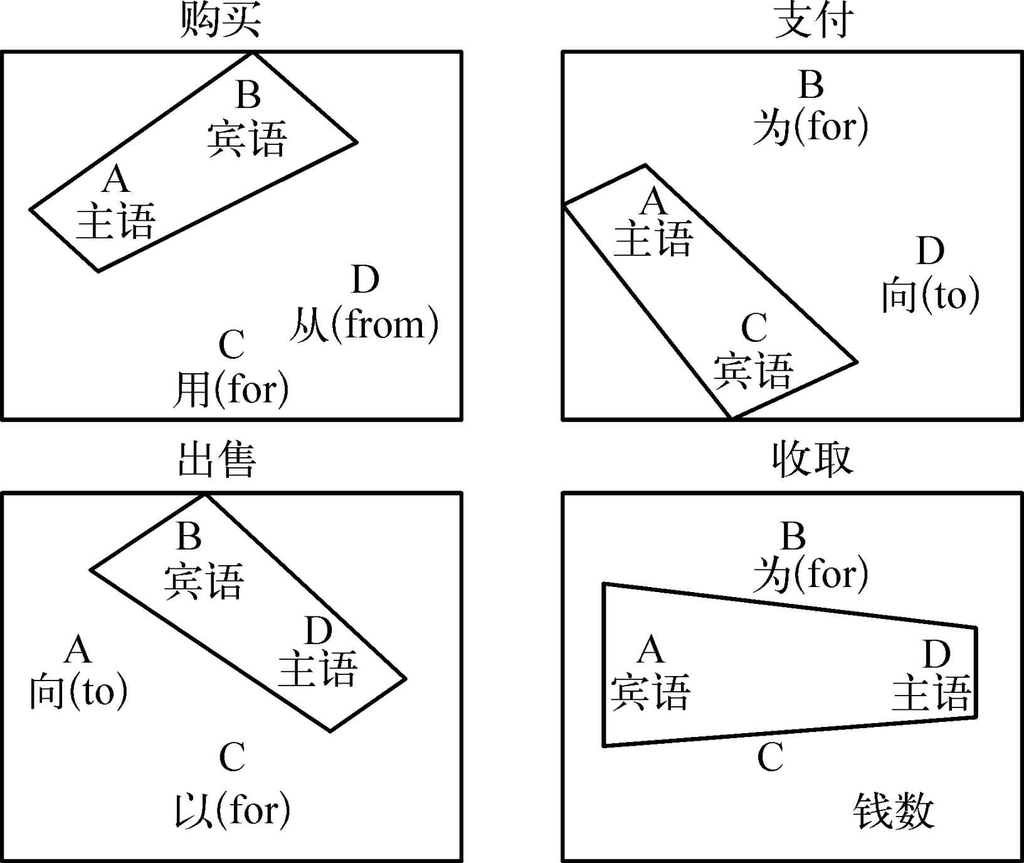

图5.2 ［商务事件］框架，由动词buy （购买），pay （支付），sell （出售），charge （收取）激活的不同视角（根据Fillmore 1977a：106以次）。

上面的4个图表明，动词buy （购买 ）、pay （支付 ），是从买者 的视角，而sell （出售），charge （收取）是从卖者 的视角出发对商务事件进行描述。图5.2在标明主语和宾语选择同时，也包括了状语中使用的介词。这是框架理论超过主体和背景理论的第一个标志：它更加重视句子中像状语这类较不凸显的成分。

### 框架概念：不同的构想和相关的概念

当Fillmore第一次引入框架这个概念时，他把它定义为（1975：124）能与场景的原型实例建立联系的语言选择的任何系统——最简单的例子是词的组合，也包括语法规则和语言范畴的选择。

这表明，框架在当时被认为是与所谓的“场景”（即我们的术语的“情境”有关的概念（参见1.3节））相联系的一系列语言选择。从这种语言学立场出发，框架概念构想已经向认知解释转变。如果我们看一下Fillmore后来对框架概念的特征描述，这一点就变得更清楚了。1985年，他说框架是“知识的特定统一框架，或经验有机的系统化。”（1985：223），1992年他把框架看作“认知结构［……］，为编码为词语的概念所预设的知识”（Fillmore和Atkins 1992：75）。这些定义和解释集中地表明，框架开始被认为是语言概念，而现在从认知上得到重新阐释。

这种认知解释对视角概念甚至更具有说服力。因此，人们不是提倡独立的“句法视角”，而是可以认为，每个句子都通过选择动词和它所管辖的特定句法型式来激活一个场景中的某个认知视角。

承认视角属于认知概念而不是句法概念，人们也许会问这背后隐藏的是什么。视角的基础主要是建立在引导注意力（attention） <sup>(2)</sup> 的认知能力之上的。此外，我们观察一个场景的视角取决于是什么吸引了我们的注意力。因此，当我们想让听者注意买者 和货物 时，我们就用动词buy （购买 ）来表述商务事件，而当我们的注意力焦点是卖者 和货物 时，就用动词sell （出售 ）。

读者在阅读了第四章后两节我们对Langacker认知语法的介绍之后，也许会惊奇地注意到其中的主体与背景理论和这里介绍的框架和注意力理论的相似性。Langacker将互动网络中的参与者侧显为句法主体和背景的想法和把框架中的两个元素看作主语和宾语的视角概念的确极为相似。你完全可以说这种相似性并不怎么奇怪，因为这两种方法都是在很大程度上依赖于Fillmore早年提出的格语法。此外，这两种理论都相信小句型式要在认知的背景中（即分别在互动网络或框架中）进行分析，而不能孤立地看待。

尽管如此，这两种理论远非一致。首先，在框架范式中工作的学者更关注与在框架中所使用的那些动词的语义有关的问题。结果，框架概念已经用于一些动词详尽的语义分析，并形成了编纂以框架理论为基础的词典课题 <sup>(3)</sup> 。其次，框架理论提供了句法型式的统一观，而Langacker则解决认知处理不同层次的问题。再次，也许是最重要的一点，Langacker在他每一个层次的分析中，几乎只关注两个凸显实体，即小句层次上的句法主体（或主语）和句法背景（或宾语）。而这里的框架概念则有一个更大的范围，因为它也提到间接宾语和状语。换句话说就是，凸显原则——顾名思义——适用于句中吸引了我们主要注意力并因而是凸显的那些成分；而框架概念同时也关注那些只吸引我们一小部分注意潜力的语言成分。我们在5.2节讨论Talmy“事件框架”中的“开启注意力视窗”时，这一点会变得尤其明显 <sup>(4)</sup> 。

框架理论也在这样的事实中表现了它更广阔的视野：［商务事件］框架甚至注意到那些凸显度低到在语言表层上完全没有表达出来的认知范畴。例句（5）和（6）中的两个动词spend （付出）和cost （花费）即是如此。

5．David spent ten pounds on an old shirt.（大卫在一件旧衬衫上花了10英镑。）

6．The old shirt cost David ten pounds.（这件旧衬衫花了大卫10英镑。）

图5.3显示，这两个动词暗含了一个在语言上不能表现出来的SELLER（卖者） （因此把它放到括号里）。相反，视角在使用spend （付出 ）时把注意力导向了BUYER（买者） 和MONEY（钱） ，而选择cost （花费 ）则将注意力放在GOODS（货物） 上。

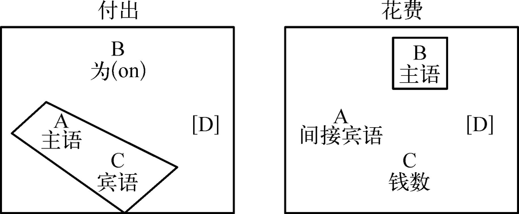

图5.3 ［商务事件］框架中由动词spend （付出）和cost （花费）所激活的视角（根据Fillmore 1977b：107以次）

如前文所示，框架法可以被看作是一种描写认知语境的方法，此语境为认知范畴提供背景并与认知范畴相联系。因此，这和我们在1.3节中介绍的“认知模型”有着极大的相似性。其区别在于，我们认知模型构想比框架更具有一般性，因此，框架只不过是各种认知模型中的一种而已，认知模型还包括3.2节中提到的“情节”、认知域和互动网络（见4.2和4.3节）以及下面要讨论的“脚本”。使用这种术语系统，框架将被看作一种表征关于具体而常见情景的知识与信念的认知模型 <sup>(5)</sup> 。

### 从框架到脚本：乘飞机

应用框架概念取得显著成果的不只是语言学（参见本节的阅读注释1）。第二个重要的研究领域是人工智能，即研究计算机模拟人类行为的潜力的学科。在这一领域中，框架概念比在语言学中应用得更加广泛，尽管也更加技术化。框架这一术语这种用法中，它的适用性已经突破单句的界限而扩展到了更大的语言和认知单位。为了理解这种更广阔的框架构想对于语言现象产生的影响，看看下面这个小故事：

Sue caught a plane from London to Mandrid．After she had found her seat she checked whether the life vest was beneath it，but she could not find it．So she asked the flight attendant to find one for her.（Sue搭乘从伦敦飞往马德里的飞机。她找到座位后检查下面是否有那件救生衣，但她没能找到。所以她让那个服务员为她找一件。）

这里会吸引我们注意力的是定冠词the 的两次出现。根据英语语法规则，当人们认为听者知道正在谈论的是哪个特定的人或物时才使用定冠词。否则，就像第一句中的a plane 一样使用不定冠词。既然有这些规则，人们不禁要问为什么虽然life vest （救生衣 ）和flight attendant （空勤人员 ）在前面并没提到过，在后面也没有说明，但它们伴随着定冠词呢。这个问题从人工智能的角度来看尤其有趣，因为它涉及了一个众所周知的问题：计算机即使安装了所有的英语语法规则和巨大的词库，它处理这个小故事仍有困难，因为它会从上文寻找能帮助它识别the life vest （救生衣 ）和the flight attendant （空勤人员 ）的参考项，而这是徒劳的。

那么为什么定冠词的这两次使用看上去完全自然，然而只从语法规则上却不能解释呢？原因在于，为了理解这些有定指称，我们需要以外部世界知识为基础进行推理（inferences） ，而这正是计算机的困难之处。坐过飞机的每个人都知道，（在许多事物之外）航空公司为所有乘客都提供救生衣，一般放在座位下面，而且飞机上有空勤人员，他们的工作就是为乘客服务。当a plane （飞机 ）出现在短文的第一句时，所有这些知识就被激活了，而且也正是这些知识使得我们能毫不费力地进行正确的推理。

作为将计算机也装备上这些必要的外部世界知识的一种尝试，框架概念被引入人工智能。计算机科学家Marvin Minsky将框架定义为“表征模式化情境的数据结构”（Minsky 1975：212）。就我们这个飞机例子中，这种想法就是，飞机 这一认知范畴会激活同属于［乘飞机］这一框架的所有其他范畴，比如飞行员、空勤人员、救生衣、安全带、一等舱、经济舱、安全须知 等等。这些范畴及其之间的特定关系（如X有个Y，X在Y之上，X是Y的一部分）都是框架的组成部分，都应该被输入到计算机。除了这种颇为普遍的框架，还有很多所谓的下位框架，储存与更特殊的飞行情景有关的知识，如［用餐］，［看电影］和［上洗手间］。鉴于我们日常生活情景的复杂性，Minsky认为我们的知识应该在复杂的“框架系统”中得到表现（1975：227以次）。

在框架中认知范畴显然起了主要作用。笼统地说，认知范畴对框架起到了定位和触发的作用，因为框架正是在范畴的排列格局及其之间的互动关系中形成的，也正是由同样的范畴激活的。范畴的另一个功用是通过提供语境依赖的原型（参见1.3节）而提供所谓的“默认指派”（即“常规”条件下的框架不同位置的赋值）。例如，在［机上用餐］这个下位框架中，你不会想到在一个摆着贵重的餐具和蜡烛的大餐桌上用餐。至于食物和饮料，你也肯定不会想到佳酿美味（除非你常常坐一等舱）。所有这些基于我们的经验并储存在长期记忆中的预期都是框架系统的组成部分，并且影响我们产生和理解与之有关的语言的能力。

为了让事情简单，［乘飞机］框架姑且介绍成了一个混杂的范畴汇集。然而，看作它的这种方式当然是有些肤浅的。更仔细地研究后就会发现，飞行还包含了一个可预见的时间结构：其中的一个阶段通常是下一个阶段的先决条件。如果从这种顺序视角来看待飞行，我们就会超越简单框架而进入所谓的脚本（scripts） ，即为经常发生的事件序列（event sequences） 所特别设计的知识结构。在更细致研究一个脚本范例之前，我们以一个关于飞行顺序结构的粗略的脚本描写来结束这个关于飞行的讨论（见图5.4）：

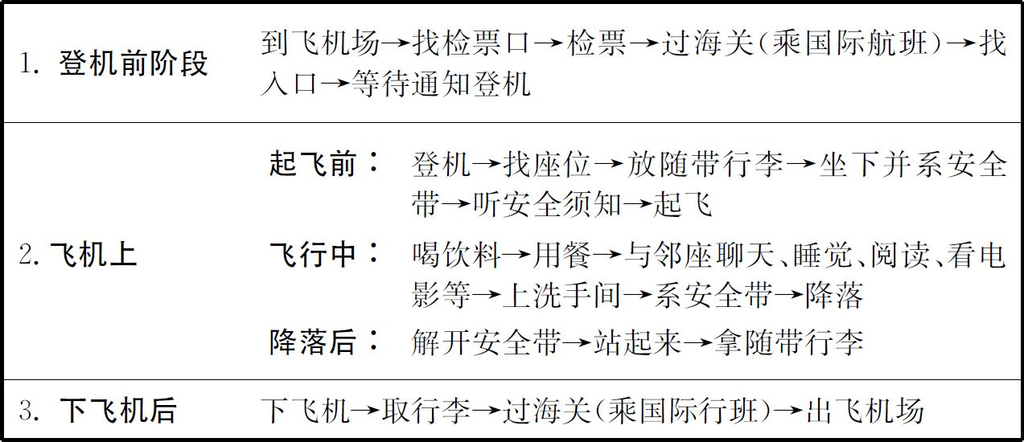

图5.4 ［乘飞机飞行］脚本的粗略概要

### 餐馆脚本

尽管图5.4可以给没坐过飞机的人详尽地描述飞行中发生的事情，但是很明显这并不能完全指导在飞机上的行为。为了说明什么是更加精心设计的脚本，接下来我们看一个也许是文献中最著名的脚本：由计算机科学家Roger Schank和社会心理学家Robert Abelson共同设计的［餐馆］脚本（Schank 和 Abelson 1977：42以次）。

总体上［餐馆］脚本分为四个场景，即进入，点菜，用餐和离开。“进入”这个第一场景要发生，很多条件必须得到满足，这些条件概括为图5.5。

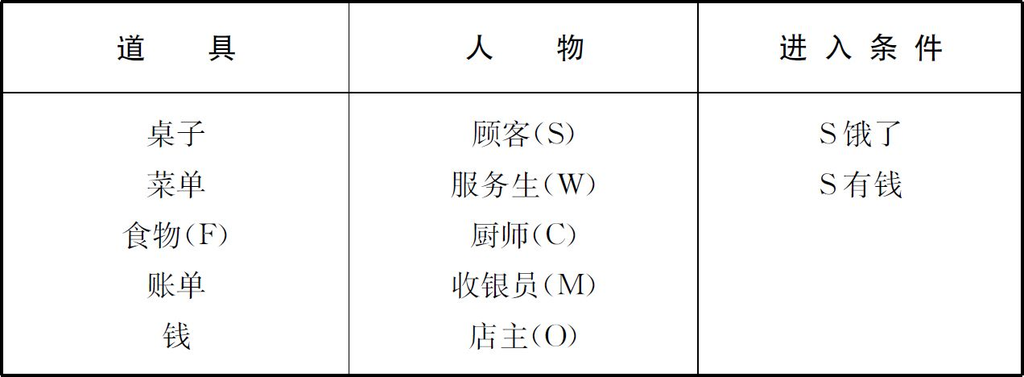

图5.5 ［餐馆］脚本的前提条件（根据Schank和Abelson 1977：43）

［餐馆］脚本运用的主要条件与形成此情景的人和物体有关。有了这些道具和角色，我们假定进入的场景可发生：顾客进入餐馆，寻找一张桌子，决定坐在哪儿，走到桌前并坐在椅子上。这些行为中的每一个行为都是实施下一个行为的先决条件，而且这个场景作为一个整体对紧接着的点菜场景的发生来说是必需的。图5.6稍微更细致地表现了点菜场景。该图表中参与者所进行的行为用一种非常基础的语言来表述，这种语言与计算机程序中所使用的命令极为接近。

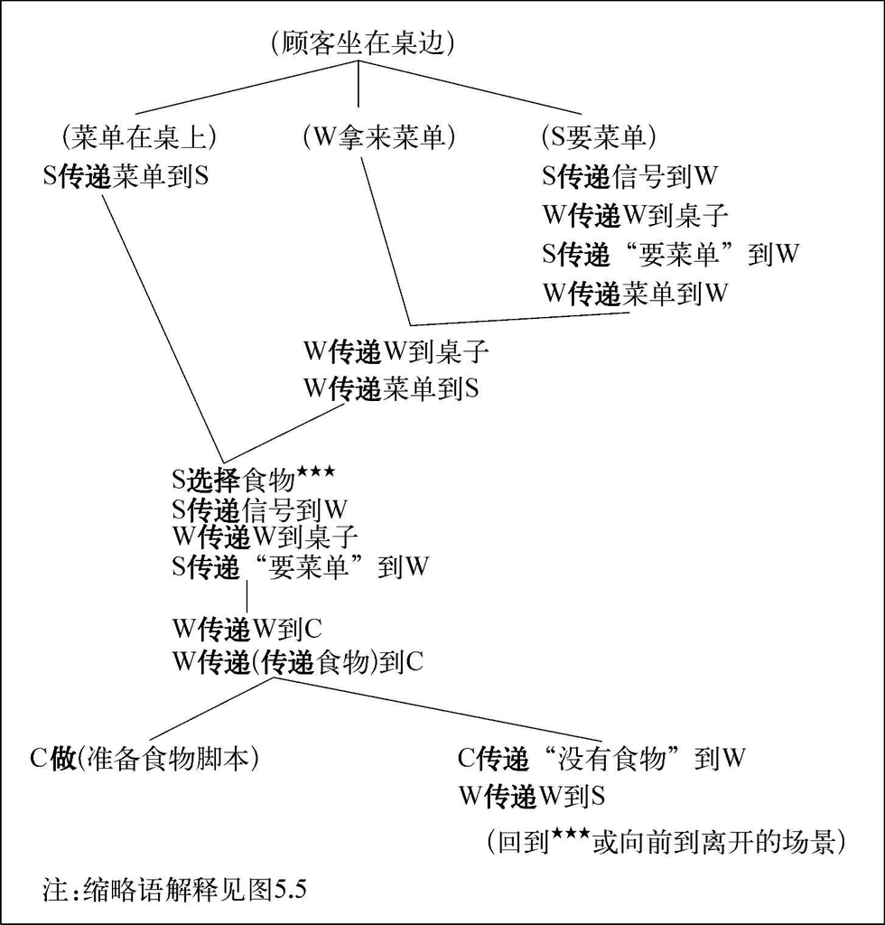

图5.6 ［餐馆］脚本的点菜场景（改编自Schank和Abelson1977：43）

这个点菜场景是怎样纳入餐馆脚本的？图5.6显示这一场景开始有三种可能性状态：也许桌上有菜单，也许服务生拿来菜单，或者也许是顾客要服务生拿来菜单。根据这三种状态不同显现，脚本会沿三条不同路径进行，但结果都是顾客得到菜单。一旦顾客手中有了菜单，下一步就是选择食物，告诉服务生所选择的食物，服务生去厨房把点的菜告诉厨师。之后，又出现了两种可能路径：厨师可能准备食物，从而为用餐场景提供了先决条件。或者，厨师示意服务生没有所点的食物。如果发生这种情况，脚本又有两种继续的可能。顾客或者重新选择食物（这就意味着脚本要从图5.6中标着★★★ 的地方重新开始），或者决定离开餐馆。如果是后者，脚本跳到离开场景，或更具体地，跳到其顾客未付款便离开这一变体。

用餐和离开的场景也能以一种相似的方式用该脚本格式表示。现在读者会觉得［餐馆］脚本的内容很乏味，整个描写脚本的过程只是把我们已知的所有事情转化为一种特定的格式罢了。尽管我们确实都熟悉脚本中所储存的信息，但是这种观点不得要领；它忽视了这样一个事实：我们说话或听话时，无意识地填入了取自框架和脚本的大量信息。更有甚者，如果不提供这些信息，我们肯定连最简单的话语片断也无法理解。为了证明这一点，请看下面的两个摘自Schank和Abelson（1977：38等）并稍作改动的故事：

1．John went into a restaurant．He asked the waitress for coq au vin．He paid the bill and left．（John走进一家餐馆。他向女服务生要了份鸡尾酒。他付了钱离开了。）

2．John went into a restaurant．He saw a waitress．He got up and went home．（John走进一家餐馆。他看见了一位女服务生。他站起来回家了。）

尽管两个故事给出了大致等量的信息，但第一个完全可以理解，而第二个不像有任何意义。出现这种差异的原因，就在于第一个故事符合我们内化的餐馆用餐脚本，所以我们能毫无困难地添补缺失的部分，如John可能在点菜前看了菜单，并且他吃了饭才付钱离开。确实，脚本是如此深刻地影响着我们，以致在形成此故事的心理表征时，我们甚至没有注意到重要的用餐场景并没有用语言表达出来。脚本（还有框架）确保做出正确推理的潜力在面对面的交谈中显得非常重要。在面对面的交谈中，说话双方在描述一个事件而省略一些细节或整个过程时，说话人常常在很大程度上依靠听话人的脚本知识。

与第一个例子相反，第二个故事不符合首句所唤起的脚本预期。处理这三句话时，它们仅仅描述了一组情景，但这些情景并不能结合而形成一个连贯的整体。这意味着除非由脚本提供关联，否则这些事件就不能形成一个有意义的致使链 <sup>(6)</sup> 。

总之，这一节讨论了框架和脚本概念的一些理论和应用。框架表现为与重复出现的情境有关的知识结构模式，在语言形式上则反映在动词间的词汇关系和小句的句法中。为了说明表现了由致使链连接的更长连续事件的知识结构，我们引入了脚本概念。下一节将介绍另一个框架概念理论，即Talmy的普遍“事件框架”。

### 练习

1．下面哪些动词符合Fillmore的商务交易框架？它们表现了哪种视角？

leave （to one' heirs ）（遗赠 （给某人的继承人 ）），inherit （继承 ），auction off （拍卖 ），pawn （典当 ），distribute （分送 ），receive （接受 ）

对于上面的某些动词来说，框架必须改变吗？

2．Dirven等（1982）使用场景（也就是我们的框架）和视角（perspective）概念来描述say （说 ）、tell （告诉 ）和talk （谈话 ）之间的差别。学习我们对动词say （说 ）所做的图解，并完成tell （告诉 ）和talk （谈话 ）的图示。

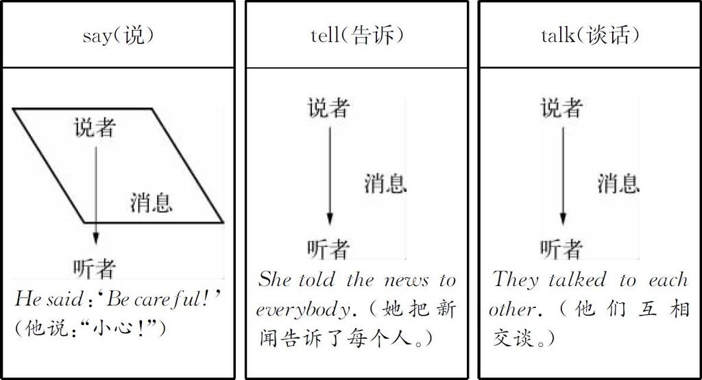

3．就像其他认知模型一样，框架，尤其是脚本是依赖于文化的。为了表明这一点，探讨一下你的儿童生日聚会模型和下面由Minsky（1975：243）提出的有着怎样的差异：

| 服装 | 节日盛装 |
| --- | --- |
| 礼物 | 必须让主人高兴 |
|  | 必须是买来的，并且有礼品包装 |
| 游戏 | 藏猫猫，粘驴子尾巴（一种儿童游戏——译者加） |
| 装饰 | 气球，装饰物，皱纸 |
| 聚会食品 | 蛋糕，冰激凌，苏打，热狗 |
| 蛋糕 | 蜡烛，吹灭，许愿，唱生日歌 |
| 冰激凌 | 常见的三种味道 |

4．试写［在理发店］和［在电影院］脚本。这些脚本的必有成分是什么，又有哪些可选成分（如：“购买爆米花”）？

5．下面的两个小故事让人想到［口试］脚本。解释一下为什么虽然两者承载的信息量大体相当，但是看起来第一个有意义，而第二个却没有意义：

（a）Before her oral exam Jane was very nervous．Nevertheless she managed to answer all question．When the professor told her that she had passed，she jumped in the air．（Jane在口试之前十分紧张。但她还是努力回答了所有的问题。当教授告诉她通过了考试的时候，她高兴地跳了起来。）

（b ）Before her oral exam Jane was very nervous．Nevertheless she talked for some time to a professor．When she went home，she was very sad．（Jane在口试之前十分紧张。但她还是和一位教授谈了一会儿。她回家以后，十分难过。）

## 5.2 事件框架和开启注意力视窗

正如已经表明的一样，框架可以为买、卖或在餐馆用餐之类情境的语言和概念分析提供有价值的工具。本节将说明框架概念如何推而广之，用来描述更普遍的情境，如由时间顺序或致使连接的事件链。

在很大程度上，上一节所讨论的商务事件框架的解释力在于它只关注了购买和出售情境中更一般的元素。因此框架并没有承载任何有关参与商务活动人物、购买货物的种类、转手的具体钱数的信息。然而，框架所提供的信息还是很具体的。比如，日常以信用卡或支票支付的行为需要对初始框架进行一些修改。如果是在以物易物而不是在以物易钱的文化中，这个框架就根本无效了。从更一般的角度来看，正如我们所知，框架是与语境和文化密切相关的认知结构。

问题在于框架概念是只限于特定的语境和文化，还是可以把它看作是一种存在于各种各样真实世界情景中、并为人类所共有的、更基本的认知现象。Talmy（Talmy2000/Ⅱ：25以次）在对事件类型所进行的研究中所执行的正是这种普遍认知主义路线。

### 位移事件和位移事件框架

要理解Talmy 的事件概念，更具体地说是位移事件的概念，我们最好先回顾一下本书已经提过的带有移动物体的情境的某些特点。4.1节用气球飞越房子上空的例子来说明了真实世界场景的感知输入是如何按照主体（或“射体”）和背景（或“界标”）来组织的。在这个例子中，移动的气球毫无疑问充当了主体，静止的房屋则充当参照点或背景。在4.1节中提及的此场景的另一个成分是主体（气球）沿着移动的“路径”。假设主体/背景分离是感知的普遍有效原则，那么就完全可以认为这三个成分——“主体”、“背景”和“路径”——对于位移事件的认知描述来说是关键的。

如果人们对位移事件再做进一步概念分析的话，就会发现位移事件的其他成分是可以分离出来。首先，位移本身就可以作为位移事件的第四个成分。这一点乍看上去可能无关宏旨，因为“位移”似乎是定义整个事件的一个特性。但如果人们想根据位移来分析事件的主体，下面这一点就变得显而易见，即“主体”与“位移”两者之间的关系实际上是相当复杂的。虽然我们很难离开主体理解位移的概念，但反过来却不是这样。就像图4.2书放在桌子上的例子所示，不移动的主体是非常普遍的。循着这种思想再前进一小步，人们可以把一个可移动主体（但不在移动）——如一本书——和它的背景（如桌子）两者之间的静态位置关系归为位移的一个特例，即零位移或零路径定位。这样处理的优势在4.1节中就已体现出来了，在那里我们把介词的静态用法当作更基本的动态用法的细化。综上所述，位移和主体并不是不可分割地联系在一起的，而位移 （MOTION）也应成为主体 （FIGURE），背景 （GROUND）和路径 （PATH）之外的事件成分。

在描述上面提到的气球情境时，有人也许会说出A balloon flew over the house （气球飞越房子上空 ）这样的句子。在这句话中，动词fly （飞 ）并不仅指某物在移动这一事实。除了“位移”这一概念成分之外，“飞 ”（fly ）还描述了移动的方法或方式（MANNER） （如：不同于跑 或爬 ），这可以看作是位移事件结构的第五个成分。最后，即使我们不总是用语言把它表达出来，我们也知道要发生一个位移事件，必须有某物使移动的物体开始移动或保持运动；这个原因 （CAUSE）也可以作为位移事件概念化中的一个重要因素，但就像方式 （MANNER）一样，看起来它并不那么具有中心地位 <sup>(7)</sup> 。

共有六个认知成分在一个位移事件的概念结构中起了作用，即主体 （FIGURE）、背景 （GROUND）、路径 （PATH）、位移 （MOTION）、方式 （MANNER）和原因 （CAUSE），因此也可以说，这六个成分定义了位移事件框架。图5.7提供的一组例子是Talmy所使用过的（1985：61），它们被用来说明所有这六个成分在一个相当简单的英语句子中是怎样被表达出来的。

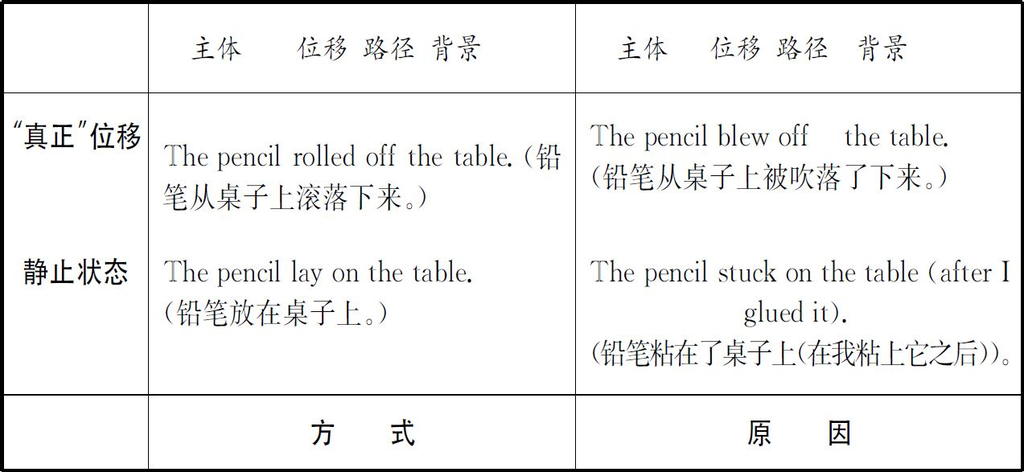

图5.7 说明位移事件六个成分的例句（框架事件及伴随事件）（汇编自Talmy1985：61及2000Ⅱ：26）

如图所示，在四个句子中，the pencil （铅笔 ）充当主体 ，the table （桌子 ）充当背景 。位移 成分用动词表示：roll （滚 ）和blow （吹 ）指“真正”位移，lie （放）和stick （粘）指零位移特例，即定位。路径 用介词表示：off 表示穿过空间的一个真实过程，on 表现空间中的静止位置。最后，动词中加入了与方式 和原因 两个要素有关的内容。roll 和lie 表示移动的方式，而blow 和stick 则表示原因。

从位移事件推而广之，Talmy得到了下面的事件框架（event-frame） 概念定义，这个定义也可以转用于其他类型的事件：

……被一起激活或被互相激活的一组概念成分及其相互关系，它可以被认为存在于一个事件框架中或构成了一个事件框架，而那些被认为是次要的成分——不管它们是被微弱地激活或根本未激活——则在该事件框架之外。（Talmy 2000/Ⅰ：259）。

Talmy一共划分出以下五种事件框架类型：位移事件框架，致使事件框架，循环事件框架，参与者互动事件框架和相互关系事件框架。为了尽可能简单，除简要讨论致使事件之外，我们的讨论将主要针对位移事件框架，它在五个类型中具有最具体的结构，并提供了Talmy所谓“注意力视窗”的范例 <sup>(8)</sup> 。

### 位移事件框架中的开启注意力视窗

让我们从一个飞行情景的描述开始，这个描述比4.1节中讨论过的“气球飞越房屋上空”要稍微详细一些：

On 26 July 1909 Louis Blériot flew across the English Channel from Les Baraques to Dover.（1909年7月26日，Louis Blériot从Les Baraques到Dover飞过英吉利海峡。）

（Talmy 2000/Ⅰ：259）

如果运用Talmy的位移事件分析方法，我们可以很容易将此句中的一些成分区分为位移事件框架成分的实例。这一点表示为图5.8。

然而，对这个分析方法的首次运用还留下了句子的重要成分未作说明。这些成分中有句首状语（on 26 July 1909 （在1909年7月26日 ）），它提供了关于事件发生时间的附加信息，因此处于事件框架之外。另外两个状语（from Les Baraques 及to Dove r（“从Les Baraques”及“到Dover”） ）显然与路径 （PATH）成分有关，是位移事件的基本成分。

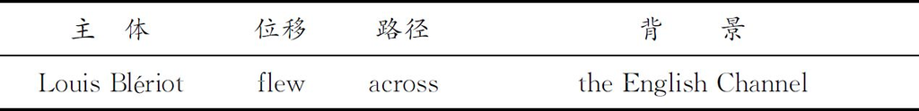

图5.8 事件框架主要成分的实现

如果我们再考虑一下句中表示方位的三个状语，它们特定的功能就变得更清晰了。第一个状语（across the English Channel （越过英吉利海峡 ））被认为激活了整个位移事件框架的路径 （PATH） 成分，第二个和第三个（from Les Baraques 及 to Dove r（“从Les Baraques”及“到Dover”） ）被认为是路径 （PATH） 成分的具体化，它们将注意力集中于其起点和终点 <sup>(9)</sup> 。Talmy（2000/I：258-309）将这种凸显事件框架中特定部分的认知过程称为开启注意力视窗（windowing of attention） 。相反的过程则被称为隔断（gapping） ，在这个过程中组成事件框架部分的概念内容被背景化。对于位移事件框架而言，这两个过程可称为“路径视窗开启”和“路径隔断”，因为正是沿着路径成分，一些注意力视窗可以被“打开”或“关闭”。

鉴于此项研究的目的，Talmy区分了路径上的三个可前景化的位置：起始视窗、中间视窗和结尾视窗。图5.9图解了Louis Blériot例子中路径视窗开启的这三种形式。图5.10则用Talmy的例句说明了视窗的所有这三种位置类型及其组合是如何表现到语言表层上的。

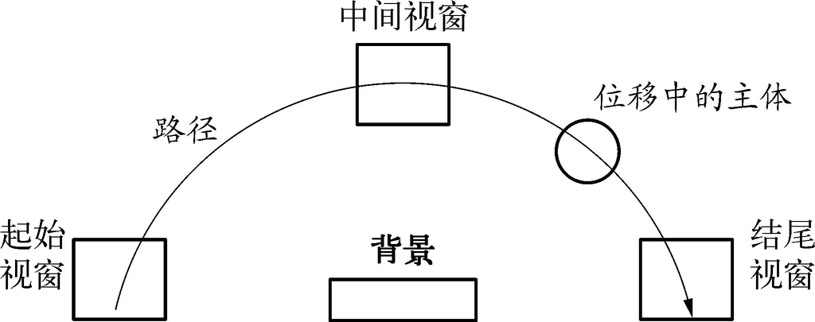

图5.9 视窗位置类型的图示展现

图5.10中的句子表明，路径视窗开启是通过使用显性的语言表达来指称路径 （PATH）的特定部分来达到的。相反，如果作为这个事件框架的组成部分的概念成分未被明确指出，那它就因被忽视而被背景化，或者说，被“隔断”。

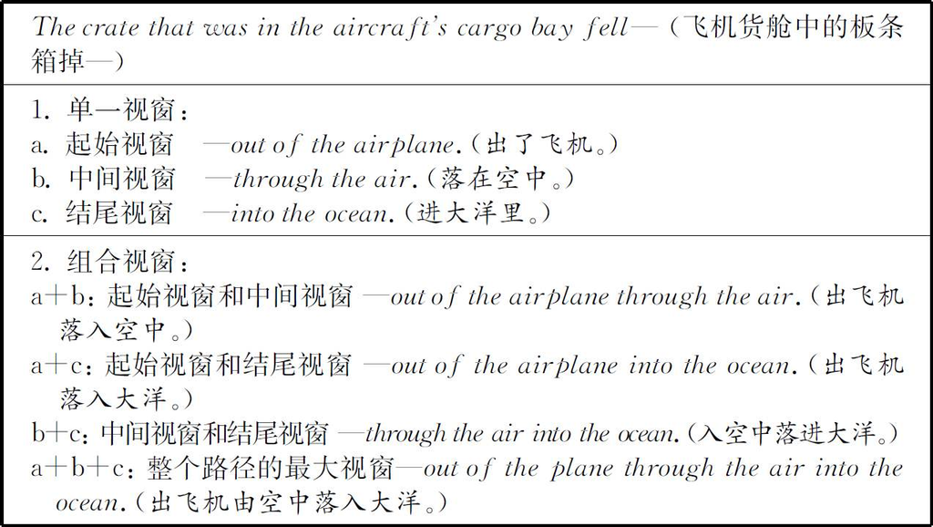

图5.10 起始、中间及结尾路径视窗及组合（改编自Talmy2000/Ⅰ：266）

从听者的角度讲，有人可能认为，如果有充足的语境，事件框架中的被隔断部分通常是可以重建的。这意味着，不管路径 有多少部分被开启了注意力视窗，它通常是整体概念化的。根据认知处理，整个路径都从认知上得到表征，但概念内容中前景化的部分将用增强了的注意力系统来处理，而这将导致更细致、精确的认知表征。

如前文所示，考虑开启路径视窗过程的一个方法是通过视窗的位置。而另一个，也许是更基本的区别是一个充当主体的物体可能沿着它移动的路径 类型。这里可以分出三个类型：开放路径，封闭路径和虚构路径。Louis Blériot和板条箱 的例子都属于开放路径（open path） 类型，即一种起点和终点处于不同空间位置的路径。这些路径可从图式上想像并表示为图5.9中的由一点到另一点的单向箭头。

第二种路径，即封闭路径（closed path） ，大致与开放路径相同，只是它应想像成圆周箭头。也就是说，封闭路径的起点和终点在同一空间位置上重合。这种路径及其不同位置视窗的语言表现见图5.11。在该例中，主体并没有明确地被表达出来。它表现为祈使句（Go and get （去拿来 ），等等）的听话人。这个人也许从桌边出发，走到冰箱那儿再回来，从而完成一个圆周路径。

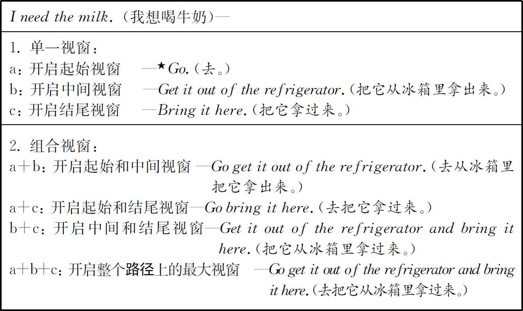

图5.11 封闭路径视窗图释（根据Talmy2000/Ⅰ：268）

除了单一起始视窗外，在这个例子中视窗的所有位置和组合都是有可能的。Talmy并没有解释为什么路径的起始位置不能被前景化。一种可能的回答是离开这一动作的发生没有包含有关剩余路径的足够信息，以确保整个位移事件的实现。当只提到路径 起始部分的时候，如图5.11中的★ Go （去）这一变体中，甚至不清楚这个路径会成为一个圆圈（从而作为封闭路径）还是一个开放路径。因此，这些不可接受的视窗开启变体背后的逻辑似乎是：路径的中间部分和结尾部分足以对整个路径进行推理式概念化，而起始部分所含的信息则不足以建立整个的后来出现路径。

### 虚构路径

位移事件中的第三种路径，即虚构路径（fictive paths），与前两者截然不同。根据Talmy的设想，虚构路径与4.1节中讨论的“over”（“在……上”）、“up”（“向上”）和“out”（“向外”）这类动态方位图式的静态用法十分相似（如Hang the painting over the chimney （把画挂在烟囱上 ）；比较图4.10和4.11）。这种相似性在于，两种情况中通常被认为随时间变化而不变的位置关系被表达为存在一个想像的路径。

举例来说，设想一个朋友向你借自行车的情景。再想像一下你的朋友向你借车的时候，你是在楼里，而自行车却锁在街上的某个位置，所以你必须向你的朋友描述它的精确位置。一种简便的方法就是指出自行车旁边比较显著的物体，并且说明这个物体和你自行车位置之间的关系。用这种方法，你也许会说出像这样的一个句子：My bike is across the street from the bakery （我的自行车在面包店的街对面 ）（Talmy的例子）。尽管这句话中的主要位置关系（be accross ）（对面 ）传统上一般被当作静态谓词的主要范例，但它还有另一种解释，即解释为描述到达谈论中物体的虚拟路径 <sup>(10)</sup> 。如果我们把自己置于语言接受者位置的话，这一点看得最清楚：理解这个句子后，听者的反映首先是把他或她的注意力指向参照点（the bakery ）（面包店 ），然后建构出across the street （街对面 ）这一心理的或虚构的路径。他或她所认为的自行车的停放处正是在这个路径的终点。

如果我们承认这个句子实际上可以作为位移事件框架的实例来分析，那我们也就可以研究开启路径视窗的认知过程的运作方式。带着这样的目的，我们再次将例句纳入一个描述事件可能方式的列表中（图5.12）。比较图5.12的例句和上面对虚构路径 的描述，需要注意的很重要的一点是：就虚构路径视窗来说，语言成分的次序并不一定遵循路径方向。为了说明这一点，我们以“Go from the bakery across the street to the lamppost ”（从面包店走向街对面的路灯杆 ）这个句子为例，把沿着虚构路径 的最大视窗（即图5.12中的2.a＋b＋c）和沿着类似的“真实”路径 的状语的最大视窗开启顺序作一对比分析（见图5.13）。虽然在这句话中副词性短语的次序与路径 方向一致，但对于虚构路径 来说却并不是这样；如图5.13所示，虚构路径 的结尾部分由第一个状语against the lamppost （靠着路灯杆 ）表示，而路径 的起始部分则由最后一个状语（from the bakery ）（从面包店 ）表示。

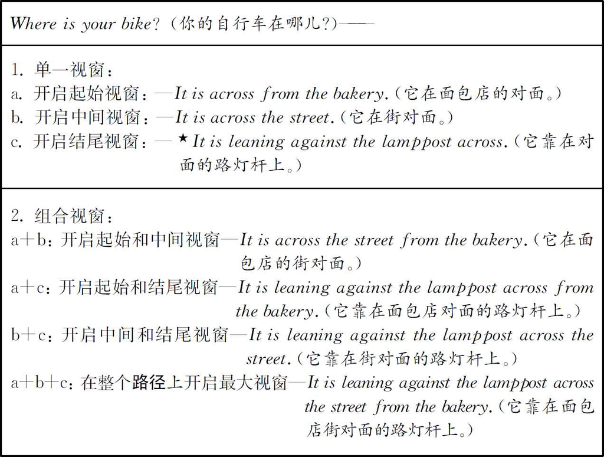

图5.12 虚构路径视窗的图释（依据Talmy2000/Ⅰ：269）

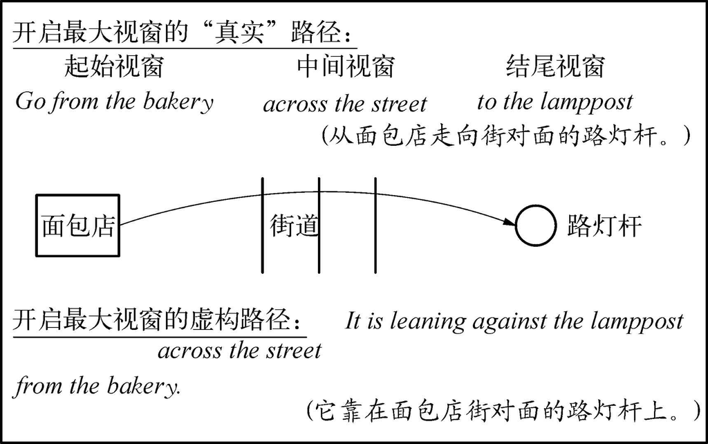

图5.13 “真实”路径视窗开启、虚构路径视窗开启

要结束虚构路径的讨论，我们还应该注意到图5.12中的两个视窗开启的变体，其中主要参照点（the bakery ）（面包店 ）被省略了或隔断了（1.b： It is across the street .（它在街对面），和2.b＋c：It is leaning against the lamppost across the street .（它靠在街对面的路灯杆上））。正如Talmy所指出的那样，这个成分只有“当它的身份一般由语境或规约提供的时候”，它才可能被隔断（2000/I：269）。这就是说，要想对这种句子进行正确的分析，还要考虑到事件框架之外的语境和情境因素。在5.3节中，我们将进一步延续这些超句的探讨并讨论事件框架在语篇中的作用。

### 致使链视窗

除了位移事件框架及它所引起的视窗开启、隔断的选择以外，本节还将探讨涉及致使链事件框架的第二类视窗。这类事件框架特别有意义，因为它为一个熟悉而著名的语言实例提供另一种处理方法，这就是对动词break （打碎 ）的语义分析（参见4.2节）。然而，在进入这个领域之前，还必须就致使和致使链概念说上一两句。

按照传统，致使概念被看成一个简单的“是-或-否”范畴，即一个词项要么归为“非致使”（如die ，fall ）（死、掉 ），要么归为“致使”（如kill ，drop ）（杀死、扔掉 ）。但是Talmy早在1976年就曾提出，致使存在不同程度。一类是由不涉及生物的其他事件引起的事件（＝“事件致使”，如the vase broke （花瓶碎了 ））。这类事件应该与其结果是由人引起，但又不是有意引起的事件（＝“人为致使”，如he broke the vase by mistake （他不小心打碎了花瓶 ））区别开来。第三种是其结果与施事意图一致的事件（＝“施事致使”，如he broke the vase to irritate his wife （他为了使他妻子生气而摔碎了花瓶 ））。除了提出致使的等级以外，Talmy还认为，许多涉及致使的事件都应该看成是由更基本的阶段或次事件组成的复杂序列 <sup>(11)</sup> 。

为了说明后一观点，我们考虑一下John broke the window（with a stone） （John（用石头）打碎了窗户 ）这个句子的施事致使意义，即一个施动者以某种目的蓄意发出一个动作（例句改编自Talmy 2000/I：272）。对这个句子所描述致使事件的认知分析表明，这个致使事件包括下面的次事件：

1．施动者打定主意要打碎窗户。

2．他屈膝，将手伸到地上抓住一块石头，直起身，用手举起石头，手握石头挥动胳膊，松开手中的石头从而使得石头向前运动。

3．石头从空中飞过。

4．石头有力地触及窗户。

5．窗户碎了。

观察这五个次事件的相互关系，我们发现每一个次事件都以致使关系与下一个次事件相联系，这就产生了Talmy的术语“致使链事件”。正如在位移事件中一样，从这个例子我们可以推断出更广泛适用的致使链事件框架（causal-chain event-frame） 的组成成分。图5.14以上文提出的句子为例子，粗略地列出了一个致使链事件框架各阶段。正如在位移事件框架中一样，致使链事件框架中最有意思的地方也是其开启注意力视窗的潜力。我们从与上面的情境有关的标准模式入手，也就是从John broke the window （约翰打碎了窗户 ）这个句子入手。把这个句子放到致使链事件框架中，我们发现阶段1（施事）和阶段5（最终结果）开启了注意力视窗，而中间阶段则被隔断。这种只有施事和结果的“不连续”视窗开启，成了描述一个致使事件的最自然方式。这并不奇怪，因为它回答了两个最重要的问题，即“发生了什么？”和“谁发起了这个事件？”。实际上，在施事引发的致使事件中，意图（阶段1）和它的实现（阶段5）之间的联系如此紧密，以至于正如Talmy（2000/Ⅰ：276）所说，两个阶段“让人觉得是无缝连接”，而两者间缺少的部分几乎达不到被注意的水平。除了引发事件的施事和最终结果，倒数第二个事件（阶段4）自然是致使链事件框架中最重要的部分，因为它指出了最终结果的直接原因。阶段4在认知上的重要性在英语的这样的事实中得到了反映：一个主要施动致使结构，即by小句，因倒数第二个事件而被倒装了。

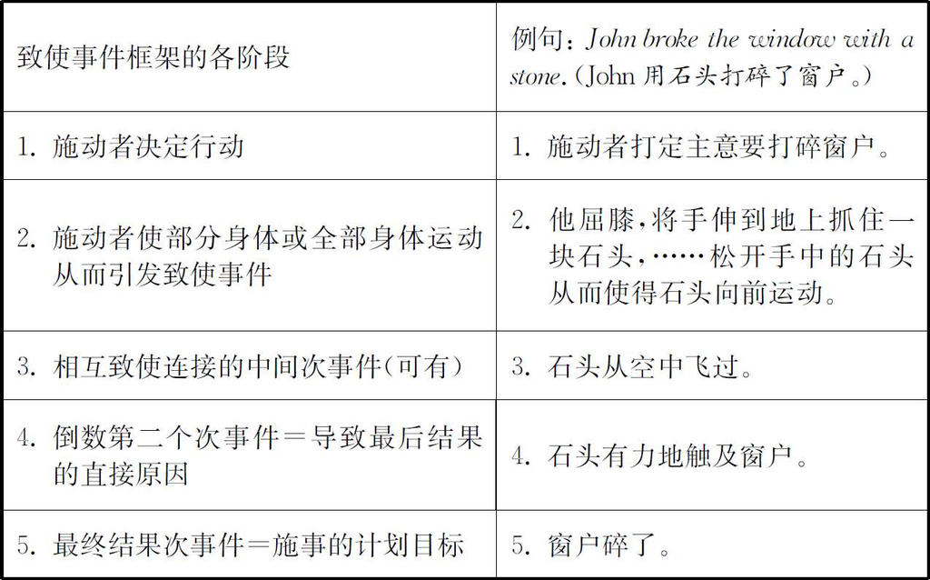

图5.14 致使事件框架的各阶段（改自Talmy2000/Ⅰ：272）

图5.15清楚地表明了这一点，图中列出了表达致使链事件框架各个阶段的by（通过）短语。在这些句子中，只有最后一个变体by hitting it with a stone （用石头砸） 是完全可接受的，因为只有这个变体表达了倒数第二个事件。正如问号所示，有些说话人也认为例（f）是可接受的，看起来他们是从句中推断出石头确实砸上了窗户。这意味着他们事实上把这个短语看成表达了倒数第二个事件。

I broke the window（我打碎了窗户）——

（a）★ by grasping a stone with my hand．（通过用手抓着石头。）

（b）★ by lifting a stone with my hand．（通过用手举起石头。）

（c）★ by swinging a stone with my arm．（通过用胳膊扔石头。）

（d）★ propelling a stone through the air．（通过在空中向前扔出石头。）

（e）★ by throwing a stone towards it．（通过冲着它扔石头。）

（f）? by throwing a stone at it．（通过朝它扔石头。）

（g）by hitting it with a stone．（通过用石头砸。）

图5.15 标志倒数第二次事件的英语by小句（改自Talmy 2000/Ⅰ：273）

虽然事件框架和视窗开启的许多迷人的地方没有论及，但这是我们对它们所能做的全部讨论。本节本应说明的是基于框架的分析可以超越Fillmore的更“传统”的立场。这种观点认为，注意力导向基本上只限于某些动词所要求带的主语和宾语的选择。然而Talmy的事件框架和视窗开启概念把研究扩展到了原先忽视的状语和小句结构中其他不那么凸显的部分。他的分析方法还考虑到了所谓的“冻结补足语”（blocked complements），即事件框架中那些不能在语言表层表达出来的成分（例如：The book cost ten pounds ★ to John /★ from Sue （这本书花费了10英镑 ★ 对John / ★ 从Sue ）） <sup>(12)</sup> 。因而Talmy的理论为说明真实世界情景在我们的头脑中如何处理、又如何表达为语言提供了一种全面的认知观。

在这一节中，框架是从普遍认知主义观的角度来理解的，这种观点认为，事件框架似乎是为所有语言的说话人所共有的。5.3节将讨论一些特定语言框架实例，在这些例子中，框架的成分在不同语言中用不同手段表达。总结性的5.4节将再专注于更广泛的讨论：如何看待框架与构式中的句法结构之间的联系。

### 练习

1．分析下列作为位移事件框架实例的句子：

We flew from Strasbourg to London.（我们从Strasbourg飞到London。）

Sir Edmund Hillary climbed to the top of Mount Everest in 1953.（Edmund Hillary爵士在1953年登上Everest山的山顶。）

The train goes from Brussels through the Chunnel to London.（火车通过Chunnel从Brussels开往London。）

The Northern Line will take you from Edgware via Charing Cross to Wimbledon.（The Northern Line将把你从Edgware经Charing Cross带到Wimbledon。）

2．以下各句哪些表现了封闭路径，哪些表现了开放路径，并描写各路径：

We are moving to London.（我们要去London了。）

Could you empty the waste paper basket，please？（请你把废纸篓倒空好吗？）

I'll go and get the newspaper from the newsagent's.（我要去报摊买报纸。）

Shall I fetch the dictionary from the study？（我能从书房里拿字典吗？）

The bus to City Hall goes via Regency Terrace.（到市政府的公交车经过Regency Terrace。）

They arrived from New York last night.（他们昨天晚上从New York到了这。）

3．以下各句“开启”哪些位置视窗？

The apple fell from the tree to the ground.（苹果从树上掉到了地下。）

The space shuttle was launched from the space centre at Cape Canaveral.（航天飞机在Canaveral角从宇航中心被发射升空。）

The parachutists glided from the aeroplane through the clouds to the landing-place on the airfield.（伞兵从飞机上穿过云层滑落到飞机场的着陆点。）

Amundsen went across the Antarctic to the south pole.（Amundsen穿越南极大陆到达南极。）

4．下列例句都可以理解为以虚构路径为基础。描写每个例句中的虚构路径并将它与句子成分的排列相比较。

You'll find the matches on the cupboard in the corner behind the kitchen door.（你可以在厨房门后墙角里的碗橱里找到火柴。）

The book on Chinese porcelain is on the third shelf from the top in the white bookcase.（有关中国瓷器的书在白色书架的上面第三层。）

（Are you looking for your car keys？）I think they're among the groceries on the back seat of the car.（（你是在找车钥匙吗？）我想它们在车后座里的食品杂货中。）

I think I parked the car on the third level somewhere to the right of the entrance.（我想我把车停在入口右边第三层的某处了。）

I remember the disco is on the right-hand side just after the second traffic lights down Market Street.（我记得迪斯科舞厅就在Market大街第二个红绿灯后的右手边上。）

5．用致使链事件框架分析一个猎人用他的枪打兔子的场景，并判断以下各by小句哪个是可接受的。

The rabbit was killed（兔子被打死）

by Peter's taking his gun along．（因Peter带上他的枪。）

by Peter's raising his gun．（因Peter举起他的枪。）

by Peter's aiming at the rabbit．（因Peter瞄准兔子。）

by Peter's pulling the trigger．（因Peter扣动扳机。）

by Peter's shot．（因Peter开枪。）

by the bullet．（被子弹。）

## 5.3 特定语言框架及其在叙述文本中的使用

本节继续把重点放在位移事件上，不过将从两个方面拓展事件框架的研究范围。第一，探讨不同语言在表达位移事件框架上的差别。第二，我们将说明特定语言的位移事件框架会影响各自的叙述风格，英语和西班牙语的故事和小说似乎是这方面的代表。

正如5.2节所示，位移事件的概念表征似乎包含六个成分：四个中心成分：主体 （FIGURE）、背景 （GROUND）、位移 （MOTION）、路径 （PATH），还有两个可选成分：方式 （MANNER）及原因 （CAUSE）。这些成分表达为语句时，它们通常会占据小句中特定的位置。图5.8中的Blériot例句说明了这一点，在这里我们将它重复为图5.16（a）。

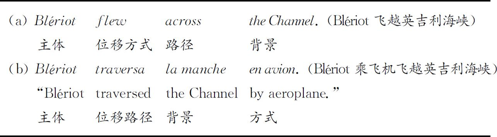

图5.16 对一个英语句子及其对应的法语翻译的事件框架分析

扼要重述一下：在英语小句中主体 表现为主语（subject，Blériot），路径 和背景 表达为由介词across 和名词性短语the Channel 组成的状语。最后，位移 和方式 成分则溶入动词fly （飞 ）的语义中。虽然这种配置对英语使用者来说似乎是很自然的，但其实这只是英语句子的情形。如果我们试图将Blériot例句翻译成法语，就不能模仿英语句子的结构了，因为逐字翻译的★ Blériot vola par-dessus la Manche 这一法语句子是不可接受的。根据英法译员法语文体手册（Vinay和Darbelnet1975），最近于对等的翻译是Blériot traversa la Manche en avion ，字面上是“Blériot traversed the Channel by aeroplane”（Blériot 乘飞机飞越英吉利海峡 ）。英语句子用介词表达路径 ，法语不一样，它将路径 融入动词的词义。方式 则由附加在小句上的状语结构表达。这种分析见图5.16（b）。

这样看来，英语和法语在句法结构和两个动词的表达潜力上似乎存在区别。正如Vinay和Darbelnet（1975）所证明的那样，这种跨语言差异早在认知语言学登上历史舞台之前就被翻译家注意到了。然而如果从Talmy事件框架的认知角度来分析它们的话，则有可能给以前被认为是毫不相关的现象提供一个更全面而统一的解释。

### 英语，德语，法语，西班牙语的位移动词：一些例证

首先，我们先来看一下路径 成分的表达方式，这次把德语和西班牙语也包括在我们的考虑之内。在下面这组例句中，为了更便于不同形式之间的对比，表示路径 成分的语言成分用粗体字标出（跟前文一样，在非英语句子的下面会有字面上的注释）。

E．The boy went out of the yard. （男孩走出后院。以下各句同此义——译者）

G．Der Jung ging aus dem Hof hinaus．  
“The boy went from the yard out. ”

Fr．Le garçon sortit de la cour.  
“The boy exited from the yard. ”

Sp．El chico salió del patio.  
“The boy exited from the yard. ”

这些例句说明了两点。第一，英语和法语的例句表明，上文fly across 和travers en avion 之间的对立并不是孤立的例子，而似乎是反映了这样一种普遍倾向：英语用一个小品词（particle）表达路径 ，法语则是将路径 融入动词词义。第二，很显然，德语同英语相似，而西班牙语和法语一样。在德语中，路径 是用动词性小品词表达的（这里从hinausgehen 这个复杂动词分离出来并移到小句句尾位置上），这类似于英语的小品词。而另一方面，就像在法语中那样，西班牙语中的路径 也是融入动词当中的。

为了说明这种法语、西班牙语和英语、德语之间的差别实际上有多么一致，图5.17中的表格列出了表达空间位移的主要动词。这张图表中的类型充分证实了我们迄今为止所得到的印象。法语和西班牙语的位移动词可以同时指称位移 和路径 ，英语和德语的动词只表达了位移 ，路径 则由一个小品词来表达。这对于英语动词go （走 ）的组合来说更是显而易见，这个动词有日耳曼语源，属于核心词汇。正如括号里的动词所表明的，“法语”的动词也是有的，但它们更具书面色彩，因而也不是那么经常使用。

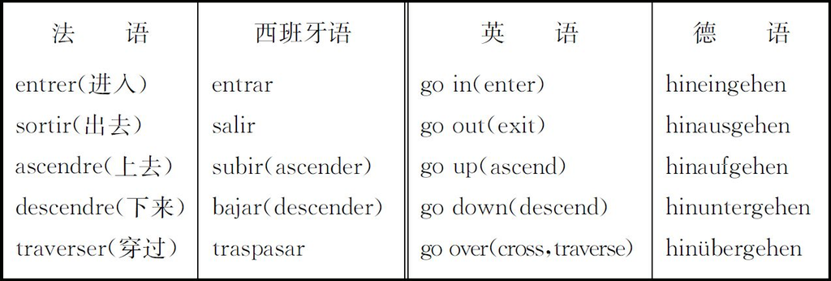

图5.17 法语、西班牙语、德语及英语中主要位移动词的位移和路径的表达

现在再看一下位移事件描述中的方式 表达，四种语言也以同样的方式配对。

为了说明这一点，我们也将首先给出四个语言中的整句例子，这次这些句子中突出的是表达方式 的语言成分：

E．The boy rode out of the yard. （男孩从后院骑马出来。以下各句同此义——译者）

G．Der Junge ritt aus dem Hof hinaus.  
“The boy rode from the yard out.”

Fr．Le garçon sortit à cheval de la cour.  
“The boy exited on horse from the yard.”

Sp．El chico salió a caballo del patio.  
“The boy exited on horse from the yard.”

正如在Blériot例句中一样，英语和德语中位移的方式 融入动词，而法语和西班牙语的方式 是作为一个独立的状语语加上去的。这种区别也不是仅限于这一个特例，其他动词也是这样。图5.18中的表格列出更多例子。这张表显示，像图5.18（b）那样，英语用动词-小品词结构、德语用复杂动词表达位移 加方式 及路径 时，相应的法语和西班牙语，如果两个成分都翻译，就会变得相当复杂。

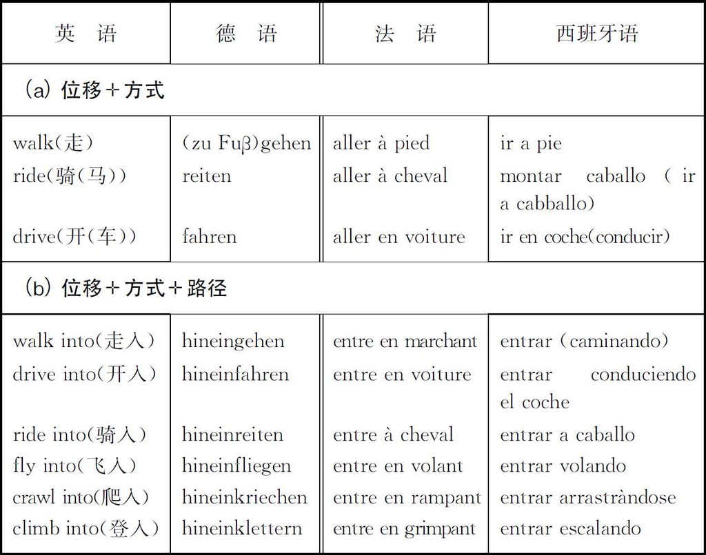

图5.18 英语、德语、法语和西班牙语中位移动词的位移、方式和路径的表达

### 路径和方式的描述：动词框架语言与卫星框架语言

正如Vinay和Darbelnet（1975） <sup>(13)</sup> 这类文体手册所证实的那样，我们用传统术语来描述位移动词使用的跨语言差异固然有可能，但是，这些传统的解释容易忽略重要的一点：当我们看一个移动的物体或人的时候，它移动的路径 和方式 并非是孤立于情景的成分，它们很显然是彼此联系在一起的，至少是在感知上是如此。这就是统一的认知观有望提供更令人信服的解释的原因，正如Talmy的事件框架所暗示的那样。

虽然路径 和方式 在事件框架中彼此联系密切，但这与这些成分地位不平等的说法并不矛盾。方式 是可选成分，即Talmy的术语体系中的伴随事件成分，它可以在语言表层不表达出来（如英语中的go out ，法语的sortir 和西班牙语的salir ）（都是“出去”之意，参见图5.17——译者注），而路径 则是位移框架的核心成分之一（参见5.2节）。路径框架功能（framing function）表达，有一个方法是通过动词，如法语的entrer （进入 ）和西班牙语的entrar （进入 ）。因此，法语和西班牙语可以被称为动词框架语言（verb-framed languages） （Talmy 2000/II：117，221以次）。相反，路径 也可以用小品词表达，如英语的go into （进入 ），或用动词性小品词表达，如德语的hineingehen （进入 ）。为了把握最后两种成分的共同功能，Talmy将它们归到一个语法范畴，叫“卫星”。因此，英语和德语可以称作卫星框架语言（satellite-framed languages） 。

Talmy（2000/II：221以次）认为，也许世界上所有的语言都可以按照动词框架和卫星框架分类。动词框架语言包括了所有的罗曼语，闪米特语（如阿拉伯语和希伯来语），日语以及其他一些语言。卫星框架的语言除了英语和德语之外还包括所有的印欧语（除罗曼语以外），芬兰-乌戈尔语和汉语。

正如前一小节中的例子所示，路径 表达中的跨语言差异导致了动词框架语言和卫星框架语言的区分，而这种跨语言差异似乎与方式成分的表达方式是一致的。Talmy（2000Ⅱ：213以次）在研究多种语言之后，这种印象也的确得到了证实。因此，我们可以把路径 和方式 表达的对比结果整合到一张总图中。图5.19提供了这种统一的观察，Talmy用该图来总结他的研究成果，此处略作简化。

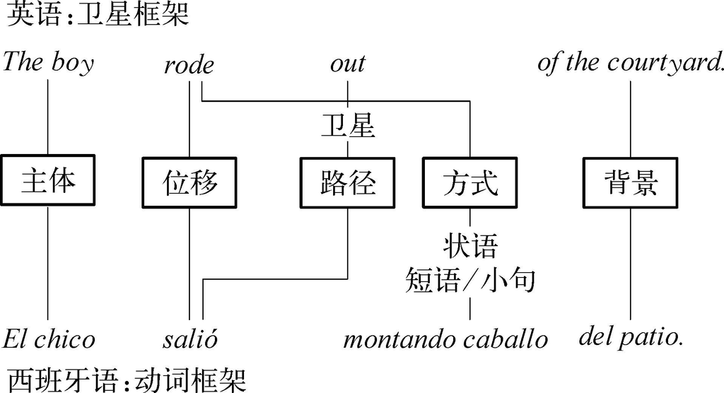

图5.19 英语和西班牙语位移事件的路径和方式表达（改自Talmy1991）

图5.19简明地表现了两种语言在表达位移事件的路径和方式时所遵从的策略。从事件框架的认知视角来考察框架中的跨语言差异，翻译家们所面对的困难就更加明显了。因此看上去十分棘手的问题，不仅仅是一大堆“不可译”的动词，而且是从认知框架成分到语言成分完全不同的映射系统。

从句法的角度来说，Talmy发现的类型学差异本身就十分有意义，而它们对于代表两组语言特点的叙述风格也产生了深远的影响。接下来我们将考察英语和西班牙语的风格差异，把注意力集中在前面已经提及的主要方面，即，在动词框架语言中，位移事件的方式 通常是必须作为独立的状语加到小句上，而在卫星框架语言中，路径 则须用一个小品词或类似的成分来表达。

### 方式和位移的表达：小说的比较研究

基本上，西班牙语这样的动词框架语言比英语那样的卫星框架语言在表达位移事件的方式时通常需要使用更多的语言材料。为了提供与包含在英语的位移＋方式动词中的信息等量的具体信息，西班牙语使用者往往需要更详尽的解释。像bolt （奔逃 ）、dart （飞奔 ）、scamper （蹦跳 ）、scurry （急跑 ）、scuttle （仓促逃跑 ）、scramble （快速爬行 ）、slither （蜿蜒滑行 ）、slide （滑行 ）、slink （偷偷地走 ）（选自《朗文当代英语词典》（LLCE）：614以次）这些动词只显露了冰山一角，而它们实际上在西班牙语里都是“不可译的”。因此，要翻译这些动词时，西班牙语译者都面临着如何处理这些差异的问题。

Slobin（1996）使用Talmy的框架，在一个英语、西班牙语小说互译对比研究中十分精当地探讨了这个问题。Slobin研究材料选自Isabel Allende、Gabriel García Màrquez、Mario Vargas Llosa、Daphne du Maurier、Ernest Hemingway、Doris Lessing这些著名的拉丁美洲、英国和北美洲作家所写的五种西班牙语小说和五种英语小说。在两种语言他都共选了一百个关于位移事件的描述。不出所料，他的主要研究结果可表述如下：

西班牙语译者大约有一半的时候省略方式信息，而英语译者则在他们大约四分之一的翻译中在西班牙语原文上添加 了方式信息。

（Slobin1996：212）

当英语的位移＋方式动词在西班牙语中没有直接对应时，西班牙语译者通常采取了省略方式信息的办法。因此，在下面的从James Michener的《切萨皮克》和John Fowles的《法国中尉的女人》中节选的两个例句中，译者干脆忽略融入英语动词stomp （迈着重重的步子走 ）和rustle （沙沙作响地走 ）中所含有的方式成分：

He stomped from the trim house …（他气势汹汹地从那所整洁的房子走出去……）

Salió de la pulcra casa …

“He exited from the trim house …”（他从那所整洁的房子走出去……）

Mrs．Tanter rustled forward，effusive and kind.（Tanter太太十分殷勤、和蔼地向前走着，衣裙沙沙作响。）

Mrs．Tanter se adelantó，efusiva y amable．

“Mrs．Tanter moved forward，effusive and kind.”（Tanter太太十分殷勤、和蔼地向前走着。）

为了记录方式成分，译者也可能决定加上一个状语小句，这是译者的第二个策略。为了说明这一点，将这种策略同翻译Slobin引自du Maurier的《丽贝卡》的动词rustle （沙沙作响地走 ）的方式比较一下：

She rustled out of the room …（她沙沙作响地走出房间……）

Salió del cuarto，acompañada del susurro siseante de sus ropas ..．

“She exited the room，accompanied by the swishing rustle of her clothing …”（她走出房间，伴随着衣裙的沙沙声……）

这里译者已经作了相当大的努力来表达英语动词rustle （沙沙作响地走 ）表示的方式。然而，这有一个副作用，那就是译文的位移方式比原文给予了多得多的凸显，因此，很难说这个译文比起前一个基于可称为忽略策略的例子中的译文更忠实于原文。

反过来看，关于西班牙语小说的英文翻译，第一个有趣发现就是有时译者似乎避免使用西班牙语动词的英语同源词。正如已经提到过的那样，这也许是因为罗曼语源的英语词语本身往往更具书面色彩。为了说明这一点，看一看下面Slobin从Vargas Llosa的La tía Julia y el escribidor （《Julia姑姑和剧作家》）中找到的例句，其中第一行是原文，第二行是字面解释，第三行是该书英文版的译文：

Don Federico avanzó sin qpresurarse …

“Don Federico advanced without hurrying …”（Don Federico前行，不慌不忙……）

Don Federico walked unhurriedly towards her …（Don Federico慢慢地向她走过去……）

下面是同类的另一个例子，这回选自Allende的La casa de los espiritús （《幽灵之屋》），这个例子甚至更有意思：

Se dirigió a la casa，abrió la puerta de un empujón，y entró.

“He directed himself to the house，opened the door with a push，and entered.”（他走向房子，推开房门，进入房子。）

He walked up to the house，gave the door a single forceful push，and went in. （他向房子走过去，用力推了一下门，走了进去。 ）

我们首先注意到的一点是两个西班牙语动词dirigir （走向 ）和entrar （进入 ）并没有被翻译成其英语同源词direct 和enter （enter ），而是用了更口语化的动词-小品词结构walk up 和go in 。第二，我们需要更仔细地看一下句子的中间部分。这里译者避免了opened the door with a push （推着开了门 ）这一逐字逐句的翻译，虽然它本来显然也是可接受的翻译。他也没有使用另一个翻译pushed the door open （推开了门 ）；这实际上本来表现了英语的特点，因为位移的方式 融入动词，而路径 和结果状态则在“卫星词” open （开 ）中得到了表达。相反，译者使用了gave the door a single forceful push （用力推了一下门 ）这个译文。原因也许是译者有意要强调位移进行的方式，而这促使译者选择可更生动的描写方式的结构。

总而言之，Slobin所提供的有关方式 表达的资料表明，英语和西班牙语之间的词汇-句法差别似乎在记叙文的修辞风格层面上会产生影响。也许这项研究最显著的成果是西班牙语译者翻译英语叙事体作品时不得不经常权衡详尽的描述和复杂句法之间的轻重。我们接下来探讨英语和西班牙语故事的路径表达时也要时刻记住这一点。

### 英语和西班牙语故事和小说的路径表达

Slobin用真实的故事作为他论文及他与R．Berman合编的一部书（Berman和Slobin1994） <sup>(14)</sup> 的第二个材料来源。值得注意的也许是来自故事的材料巧妙地回避了一个翻译对比研究中固有的方法论上的潜在缺陷：译者描述事件时无疑会受到原文所激发意象的影响，而这可能导致颇不自然的结果。反之，在一个故事中叙述者可以自由地表达他或她自己对于事件的感知及想法。然而另一方面，自由编写的故事存在一个问题，那就是比起相同文本的译文来，不同故事之间的对比不是那么容易。因此Slobin和他的合作者使用了一个相同的无字图画故事《青蛙，你在哪儿？》（Mayer 1969）让伯克莱和马德里的英语和西班牙语使用者讲出故事。用这个方法，他们从每种语言五个年龄组（3岁、4岁、5岁、9岁及成人）中的各12个叙述者那里收集到了60个实际内容相同的故事。为了说明这个故事讲述的内容，下面是Slobin自己对故事的简短叙述：

《青蛙，你在哪儿？》中所描述的事件包含了很多位移描写：一只宠物青蛙从它的罐子中逃出，一个男孩和他的狗去寻找丢失的青蛙。他们的寻找路线包括：从窗户上掉下来，爬上树又掉了下来，爬上一块岩石并被鹿角挂住，鹿又从悬崖上将男孩和狗扔到水中，最后男孩和狗从水中爬出，并爬过一根圆木去找逃跑的青蛙。

（Slobin 1996：197）

为了查明叙述者在各种位移描述中是如何表达路径的，我们先考察60个故事中每一种语言用来描述位移事件的动词。西班牙叙述者只使用了27个动词，而英语叙述者则使用了更多的动词：通过单独计算动词词干，Slobin找到了47个动词类型；而如果把与“卫星词”的组合也计算在内，简单动词和短语动词类型的数量就达到了123个。下表收集的是英语叙述者使用的拥有最多确定的卫星成分的动词：

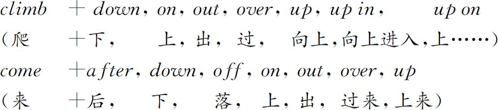

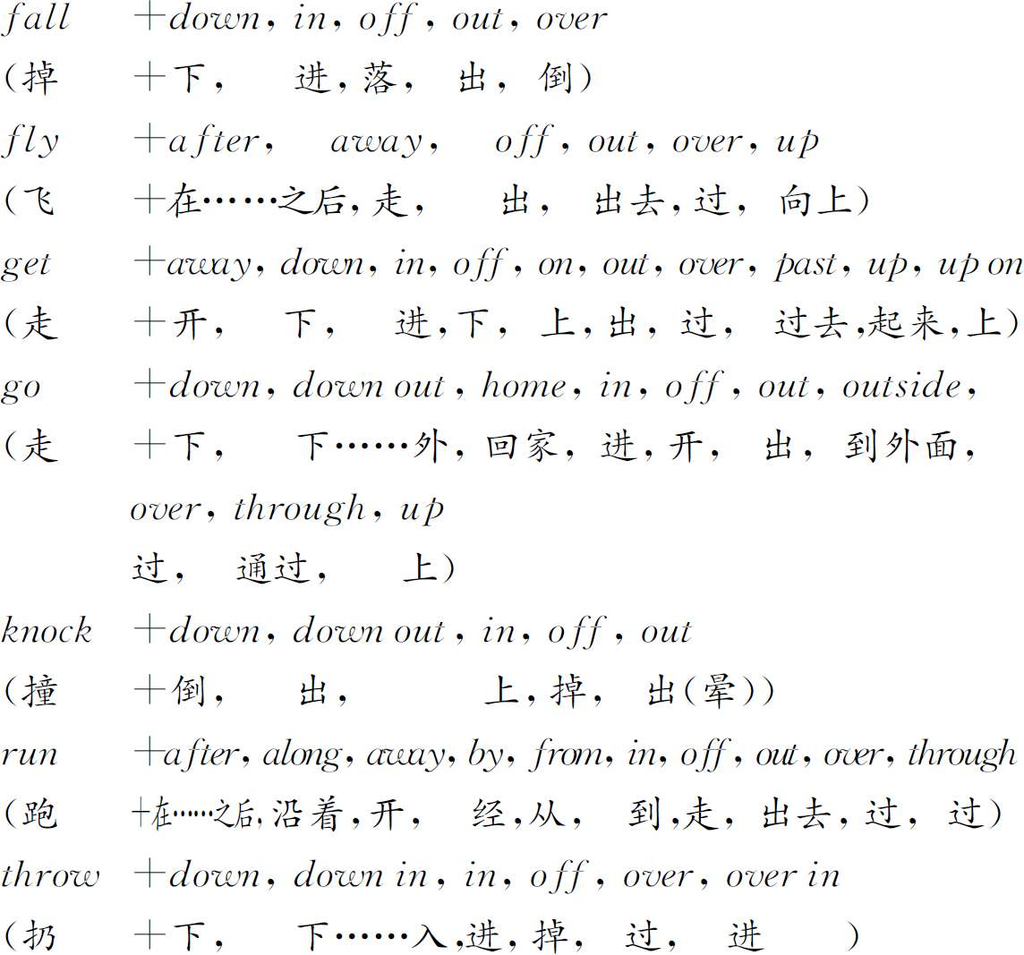

虽然有些动词，如come 和fall ，也至少包含了路径 这种特性，但是，英语故事显然主要是通过卫星词来完成路径描写的任务的。比较极端的例子如get 和go ，它们除了位移 成分外，实际上并没有别的意义，但是一旦与卫星词结合，就有了描述路径 的巨大潜力。那么，作为暂时的小结，人们完全可以认为，Slobin研究的系统结论证实了我们上面有点儿源于印象的看法。

如同方式一样，路径表达上的差异在两种语言的独特的叙述风格上留下了印记。首先，英语叙述者比起西班牙语叙述者来说似乎将更多的注意力放在了路径 的细节上。这种描述尤其引人注目的一点是即使是年幼的英语叙述者似乎也十分精通5.2节中所说的“开启注意力视窗”的策略。在开启注意力视窗时，他们充分利用了其卫星框架语言的资源来详细地描写路径 。像“The deer threw the boy over a cliff into a pond ”（鹿将男孩 从悬崖上扔进了池塘里 ）这类包括了路径 中间视窗和结尾视窗的视窗开启结构，在英语故事中似乎十分常见。

观察西班牙语故事的时候，情形就不一样了。即使西班牙语资料增加到由拉丁美洲叙述者讲述的216个故事，也只找到三个例子，它们开始视窗或中间视窗是和结尾路径视窗结合在一起的。这一发现更加引人注目，因为西班牙语显然有路径视窗开启的语言手段，如下面这个例子：Se cayó de la ventana a la calle （［狗］ 从窗户掉到街上 ）。然而，尽管这些语言手段有这种结构的能力，比之英语使用者，西班牙语使用者似乎很不情愿运用它们。

考察一个更长的例子会更清楚地证明这种不情愿，并将表明一个事件的场景描述是如何与路径描述相联系的。首先，对比下面英语和西班牙语对《青蛙，你在哪儿？》故事中一个情节的描述，在这个情节中，男孩被鹿带到了悬崖上然后又从那儿被扔到池塘里。

西班牙语：El ciervo le llevó hasta un sitio，donde debajo habiá un río.Entonces el ciervo tiró al perro y al al río.Y después，cayeron．

“鹿把他带到了一个地方，那下面有一条河。然后鹿把狗和男孩扔向河里。然后他们就掉了进去。”［9岁］

英语：He［the deer］starts running and tips him off over a cliff into the water .（他［鹿］开始跑，然后把他从悬崖上掀到了水里。）［9岁］

使用西班牙语和英语的儿童都向我们提供了有关主体 （即男孩（和他的狗））移动的路径 和事件发生的场景的大量信息。但是他们提供这些信息的方式却截然不同。使用西班牙语的儿童用一个完整的关系从句表明事件发生的场所（un sitio，donde debajo habiá un río “一个下面有一条河的地方 ”）。因此场景本身也表达为一个事件，并用一个附加的小句和一种颇为静态的方式来描述。然而，英语的表达中并未出现这种孤立、静态的场景描述。相反，场景被并入位移事件。为了说明这是怎么做的，图5.20从的事件框架上分析了这个句子第二部分。

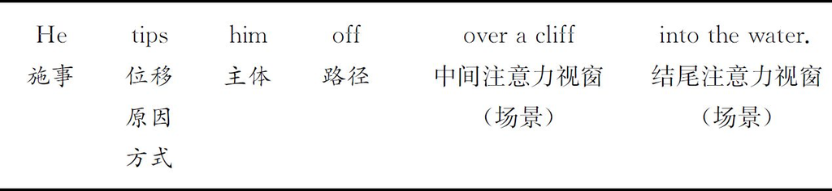

图5.20 句子He tips him off over a cliff into the water. （他把他从悬崖上掀到了水里。）的事件框架分析

正如图5.20的分析所示，这个貌似平常的小句表达了大量的认知成分。除了施事和主要位移事件框架的四个成分之外，两个附加的要素，即原因 和方式 ，也包括在内。此外，在路径 的中间和结尾部分也开启了两个注意力视窗。与西班牙语句子不同，这些路径视窗可以将场景包含于位移事件中，这也可以带来更生动的场景描写。使用英语的儿童似乎将更多的注意力放在了主体和背景或场景之间的变化关系上。相反，使用西班牙语的儿童则从静态的场景描述中推断出位移的某些部分。例如，男孩从被鹿扔下去到掉入河中所经过的路径必须从河位于下面这一已有信息中推断出来。

我们再次回到小说及其翻译的对比来结束这个讨论。看一看下面的例句，其中先列出Daphne du Maurier的小说《丽贝卡》中的英语原文，接着列出是西班牙语的译文及其英语的逐字对译。

I ..．climbed up the path over the cliffs towards the rest of the people．

（我……爬到悬崖上的小路，向剩下的人爬去。）

Tomé el sendero que conducía al lugar donde estaba la gente.

“I took the path that led to the place where the people were.”

（我走上通向人们所在地的小路。）

Du Maurier的原文详细地描述了一个扩大的位移事件，这个事件凸显了背景 （the path ），还包含了路径 中间部分（over the cliffs ）和结尾部分（towards the rest of the people ）的注意力视窗。正如上例所示，这些视窗也包含了事件场景信息。从句法的角度来说，值得注意的是所有的这些都只用一个单句表达。然而，西班牙语的译文需要三个小句来对译英语的一个小句，却又略去了原文中的两点信息。首先，未指出路径的垂直方向，这在英语中是用卫星词up 表达的。第二，中间视窗（over the cliffs ）在译文中没有保留。除了这些删节之外，西班牙语译文和原文的不同之处还在于它将场景的细节从位移中分离出来，因为表达位移时用了两个独立的关系小句。这就放慢了西班牙语描述的节奏，而与用英语绘出的完整而生动的画面相比，这使得西班牙语的描写具有一种更为静态的、一步接一步的特点。

Slobin认为，西班牙语译者显然也注意到了这种差别。这一点可以从一些译文中看出来，这些译文为了更生动的事件描述而刻意省略了方位细节。在下面的两个选自《丽贝卡》和J．Fowles的《法国中尉的女人》例句中，英语原文开启的注意力视窗在西班牙语译文中并没有被表达出来，因此“西班牙语读者简直不知道整个过程。”（Slobin1996：211）：

He strolled across the room to the door …（他穿过房间走向房门……）

Se dirig ió a la puerta ..．

“He went to the door …”（他走向房门……）

..．she moved out into the sun and across the stony clearing …（……她走出来，到阳光下，穿过铺着石块的空地……）

..．la muchacha salió al claro rocoso …

“..．the girl exited to the stony clearing …”（……女孩走到外面铺着石块的空地……）

在第一个例子里，路径 的中间视窗across the room 在译文中被隔断了。第二句省略了起始视窗into the sun ，路径 的描述只是简单的表现为“to the stony clearing”。

总之，正如本节所述，运用事件框架概念来对比不同语言和不同叙述文本得到了一些有趣的发现。显然，英语这种卫星框架语言更适于用来描写方式 以及对路径 进行详细刻画，其中包括对沿着路径 的位置的动态描写。其原因就在于卫星框架语言中方式 通常是包含在动词词义内的，有关于路径 和场景的信息则可以通过开启注意力视窗在同一个位移事件小句表达。因为西班牙语是一种动词框架语言，对于位移事件的描写就限于对位移本身。要描写方式 就只能运用扩充过而别扭的结构。同样，如果要给出路径 和场景的详细信息，它们通常在额外的小句中表达。因为这有时会大大降低叙述的速度，西班牙语使用者就可能选择更生动的位移 描写而舍弃方式 和路径 的一些细节 <sup>(15)</sup> 。

### 练习

1．用位移事件框架（参照图5．19）分析下面的英语句子及其法语译文（选自Vinay 和Darbelnet1975：106）：

She tiptoed down the stairs.（她踮着脚尖走下了楼梯。）

Elle descendit l'escalier sur la pointe des pieds.

“She descended the stairs on the tip of the feet.”（她用脚尖走下了楼梯。）

He crawled to the other side of the road.（他爬到了路的另一边。）

Il gagna en rampant l'autre cô té de la route.

“He gained crawling the other side of the road.”（他努力爬到了路的另一边。）

2．用一本合适的词典查找下面各对同义词或近义词的词源。它们是如何反映动词框架结构和卫星框架结构之间的差别的？为什么英语通常有两种选择？

| soak through （浸穿 ） | percolate （渗透 ） |
| --- | --- |
| get there （到 ） | arrive （到达 ） |
| come upon/across （碰到 ） | encounter （遇见 ） |
| break out （暴发 ） | erupt （暴发 ） |
| run off （逃掉 ） | escape （逃跑 ） |
| send out （发出 ） | emit （散发出 ） |
| throw up （呕吐 ） | vomit （呕吐 ） |

3．在西班牙语或法语双语词典中查查下面英语动词＋卫星结构，并讨论一下它们是如何翻译的。有时反检一下词典中给出的对等译文可能是有益的。

hop in （跳入 ），squeeze into （挤入 ），creep in （蹑手蹑脚地走入 ），tread in （踩入 ），pour in （倒入 ），flow in （流入 ）， break into （闯入 ）

4．下面是青蛙故事（Slobin 2005：314）的土耳其版节选。考察其小句的长度和数量、路径 和方式 的表达，并对照本书中的英语和西班牙语例句，讨论一下它的修辞风格。

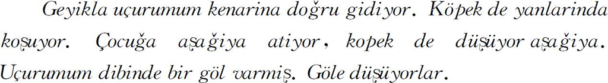

“With the deer［he］goes straight to the edge of the cliff．The dog runs by their side．［He］throws the boy down，and the dog falls down too．At the bottom of the cliff there was a lake．［They］fell to the lake.”

（跟着鹿［他］径直走到悬崖边。狗在他们边上跑。［他］推倒男孩，狗也倒下。在悬崖底下面有一个湖。［他们］掉到了湖里。）

5．看一看下面的英语-法语例句（选自Vinay 和Darbelnet1975：106）。讨论一下两种语言中描述事件需要多少个小句；在两种语言中，路径 和方式 又是如何表达的：

Through the wide open window streamed the sun on to the yellow varnished walls and bare floor．

（透过敞开的窗户阳光泻入到涂成黄色的墙上和光地板上。）

Par la fenêtre grande ouverte，le soleil entrait à flot et inondait les murs vernissés en jaune et le parquet sans tapis.

“Through the wide open window，the sun entered floating and inundated the walls varnished in yellow and the parquet without carpet.”

（穿过敞开的窗户，阳光浮入并淹没了涂成黄色的墙壁和没有地毯的镶木地板。）

## 5.4 构式语法

正如前几章所述，框架是从对不断重现的情景和事件的经验中提取的知识模型。从语言学的角度来看，关键的是框架及其打开的可能视角从语言上反映到了小句句法上，或者反过来说，句法模式可能与框架的概念结构有关。在这一节中我们将考察认为上述情况确实存在的构式语法理论。

### 从框架到构式

在5.2节中，我们介绍了位移事件框架，并以此来解释事件的概念结构及其语言表述之间的关系。正如Talmy所说，位移事件框架由位移、主体、路径 及背景 等四个中心成分及方式 和原因 这两个成分构成。稍微复杂一点儿的变体，含有后两个成分，这在5.2节中用The pencil blew off the table （铅笔从桌上吹落下来 ）例句进行了说明，在这个句子中，原因 成分被整合到“由吹而动”这一动词意义中。描述同样的情景却突出原因 成分，有一个更明确的方式，比如，The draught blew the pencil off the table （穿堂风将铅笔从桌子上吹落下来 ）。此句表述了一个框架结构，这个框架结构既包含Talmy位移事件框架（因为铅笔从桌子上被吹落），也包含了致使链事件框架（位移由穿堂风产生，一个事件-致使实例）。这个联合体可以被称作致使-位移事件框架。比较一下图5.21，在此图中，框架和相应的句式进行了比较。

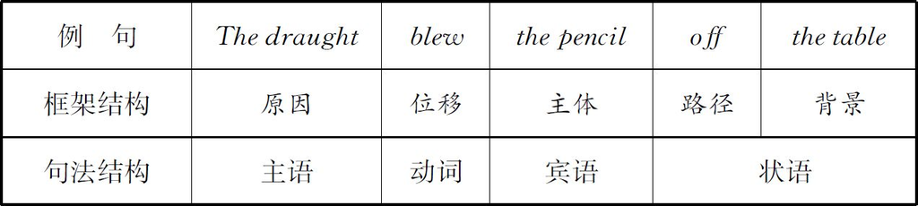

图5.21 致使-位移事件框架的概念和句法结构

即使例句可能感觉上有点牵强，致使-位移事件框架也被广泛使用，施事-主语结构也是如此。从语料库中可以很容易地找到体现这一框架的其他句子，这表明假设这样一个事件框架并不是专为一个句子作出的特别决定。以下还有从国际英语-大不列颠语料库（ICE-GB）中随意选取的一些例子：

I［…］shoved them into a corner.（我把它们推到了墙角。）

I brought her out of hospital.（我将她带出医院。）

They kicked him to the ground.（他们把他踢倒在地上。）

We can always put a pillow over her head．（我们可以将枕头放在她头上。）

框架成分和句法成分之间存在着紧密的对应，这使得认知语言学家持有如下观点（也是归于“构式语法”这一术语之下的一组理论的核心）：句法格式本身在对某种经验进行编码时起作用。这意味着，我们并不是在头脑中的特定视角导引下简单地将框架成分投射到句法成分上，而是，可以说，从长期记忆中成批地选取储存于其中的特定句法格式或构式（construction） 。然而，不仅构式的句法组织储存在长期记忆中，而且关于该构式所编码的各种典型的场景及事件的知识也是这样。这又意味着构式本身传达了某种要表达的概念内容，换句话说，构式有自身意义 ，而这种意义与相应的概念框架有关系。

但是我们怎么知道意义属于致使-位移构式，而不是像Fillmore早期的格语法所主张的那样，是动词（上述例句中的blow，shove，bring，kick，put （吹，推，带，踢，放 ））意义的一部分呢？Adele Goldberg（1995）是构式语法倡导者之一，她指出，我们不仅在带适当的动词意义（kick，put，shove ）的句子中可以毫无困难地辨识致使-位移意义，在一些动词根本不表达致使-位移意义的例子中我们也可以做到。比较下面这对例子，第一个句子代表了与动词push （推 ）联系的典型的致使-位移组配，第二个例句有动词sneeze （打喷嚏 ），这个动词通常被认为是不及物的，也不具有致使-位移意义（Goldberg，1995：152）：

Frank pushed the tissue off the table．（Frank将纸巾推到桌下。）

Frank sneezed the tissue off the table．（Frank打了个喷嚏把纸巾吹到桌下。）

但是由于构式意义的力量，第二个例句也可以解释为致使的位移，并且也可以意译为“Frank sneezed and thus caused the tissue to be swept off the table.”（Frank打了个喷嚏因此使纸巾被掠到桌下）。致使的位移构式对带状语，尤其带用作比喻意义的状语的其他不及物动词也有类似的影响，如下列各句中的不及物动词：

Barnes［…］plays him into troubles.（Barnes［……］把他玩进麻烦里去。）

The police tear-gassed the demonstrators into panic．（警察放催泪弹把示威者置于恐慌之中。）

上面两个句子中目标方位没有并入到动词（play，tear-gass （玩，放催泪弹 ））中，而是从整个构式中衍生出来的。构式理论也为所有的所谓及物-致使动词提供了有趣的解释，而传统上及物用法被认为是有别于sit （坐 ）或stand （站 ）这种动词的核心不及物意义的一种特殊意义：

And then we'll sit you on your bike.（然后我们将让你坐到你的自行车上。）

She stood the flower-pot on the window-sill.（她将花盆放在窗台上。）

总结一下本节目前为止所讨论的内容，我们将把注意力集中到下面这三点：

· 源自日常经验的特定概念结构与明显即兴生成的句法结构之间似乎存在紧密的对应关系。

· 在构式语法框架下工作的语言学家所搜集的证据表明，构式事实上可能不是随时生成的，而就像框架，甚至像个体概念一样，是储存于长期记忆中的 <sup>(16)</sup> 。

· 构式可能具有独立于插入特定实例中的词项以外的自身意义。正像词一样，构式被认为是形式和意义的配对，因此形式自动激活意义，反之亦然 <sup>(17)</sup> 。

下一节中我们将讨论构式的另外一些例子，验证构式基于经验的观点，并解释一下它们的多义现象。

### 论元结构构式

致使-位移构式是一种主要的论元结构构式（即在构式中，动词联系其必有补足语或论元）。Goldberg（1995）中所讨论的其他两种主要构式是致使-接受构式（Goldberg自己坚持使用“双及物”句法术语）和结果（即致使-成为）构式，举例说明如下：

| 致使-接受构式 | 致使-成为构式（结果构式） |
| --- | --- |
| Joe gave Sally the ball . | Terry wiped the table clean. |
| （Joe把球给了Sally。） | （Terry把桌子擦干净了。） |
| Joe painted Sally a picture ． | He ate himself sick. |
| （Joe给Sally画了一幅画。） | （他把自己吃病了。） |
| Bob told Joe a story ． | Terry pushed the door shut. |
| （Bob给Joe讲了一个故事。） | （Terry把门推上了。） |

这些构式的概念构成是直接的：致使-位移构式包含一个（由主语表达所表达）原因，这个原因引起了受事向目标的位移。致使-接受构式包含一个施事，这个施事使接收者接受一个受事，结果构式包含一个施事，这个施事使受事进入某种结果状态。这三个构式的相同之处在于它们把人类的基本经验和基本句法小句型式结合在一起。这一点表示为图5.22，这个表的基础是Goldberg（1995：70）。

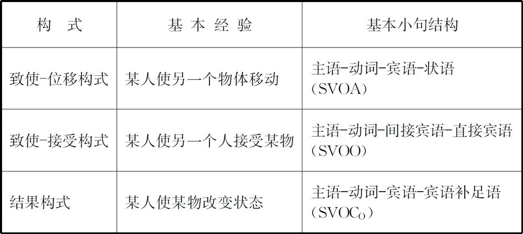

图5.22 论元结构构式的经验及句法基础（根据Goldberg 1995：70）

必须强调的是，这种直接经验基础看上去似乎只适用于解释上面所说明的这类简单而基本的小句句型。在世界上其他一些语言中也可以找到相似的小句句型，这一事实更加有力地证实了以下的观点：即这些小句句型可能是植根于人类共有的经验之上的。

然而，还必须注意另一点：像大多数的构式一样，这三个论元结构构式可能形成各种有关的意义。这也就是说，跟词位（lexeme）一样，构式是多义的 <sup>(18)</sup> ，而且，论元结构构式事实上只有核心的、典型的意义才可能是植根于经验的。正如Goldberg指出的那样：“与基本句型对应的构式把以人类经验为基础的事件类型编码为它们的核心意义 ”（Goldberg 1995：39；着重点为引者所加）。为了说明构式的多义性，图5.23表现了致使-位移构式的主要含义。

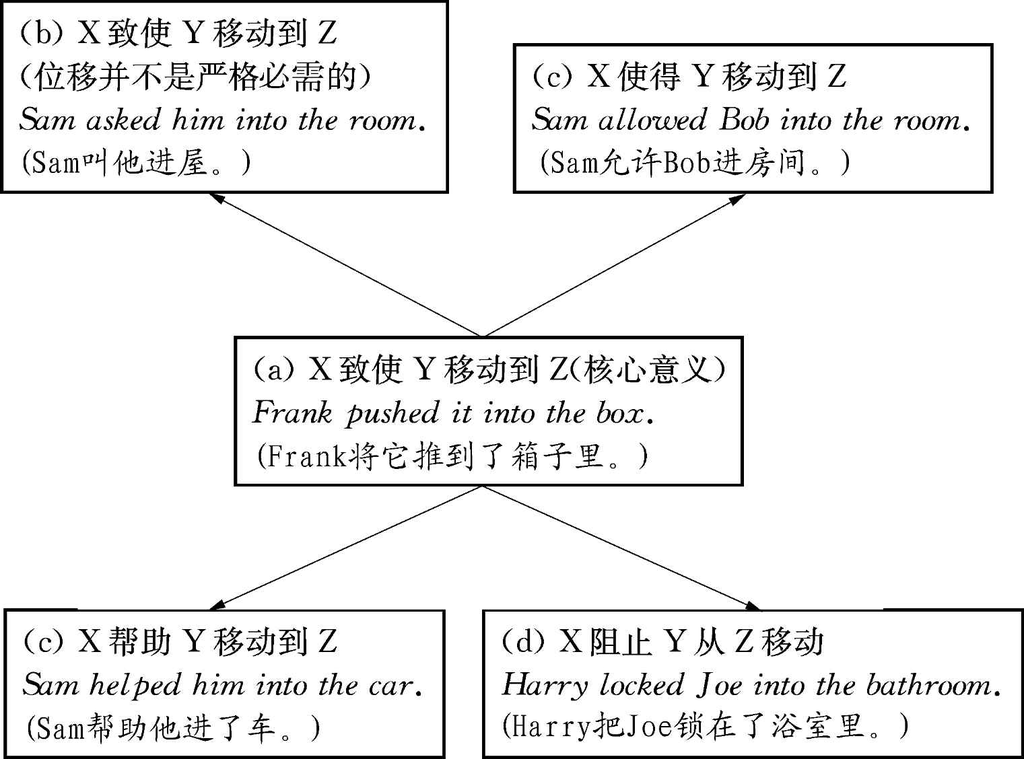

图5.23 致使-位移构式的多义（改编自Goldberg 1995：161以次）

### 复杂句构式：一个例子

尽管小句句型可能为构式提供了最有力的例证，这种想法也可以推广到复杂句。为了说明这种能力，我们将集中讨论所谓的“外壳-内容构式”（shell-content construction） （Schimd 2000），它的语言形式是一个抽象名词和从句或不定式的结合；从句或者直接附在名词性成分上（下面的前两个例子）或通过系词BE与名词性成分连接（后两个例子）。

The fact that a conference is taking place is encouraging．（会议将要召开的事实是令人振奋的。）

The chance to find a cheap hotel room is small．（找到一个便宜宾馆的机会很少。）

The problem is that hotels don't offer cheap rates．（问题是宾馆不会提供便宜的价格。）

The aim is to open student hostels for guests．（目的是向客人开放学生旅社。）

这些结构的共同之处是它们的认知-语用功能：它们主要的作用是让（从句表达的）整个命题可用作一个像名词的概念，这个过程叫做“具体化”（reification）（将某事变为某物） <sup>(19)</sup> ，并将命题置于某种视角之下（即作为一个事实，一个目标，一个目的等等）。在这个过程中，抽象名词充当了一种信息的容器或“外壳”，而这种信息是包含在从句中的，这种抽象名词也因此被称为“外壳名词”（shell noun）。图5.24表现了仿效Goldberg的论元结构构式的外壳-内容构式。

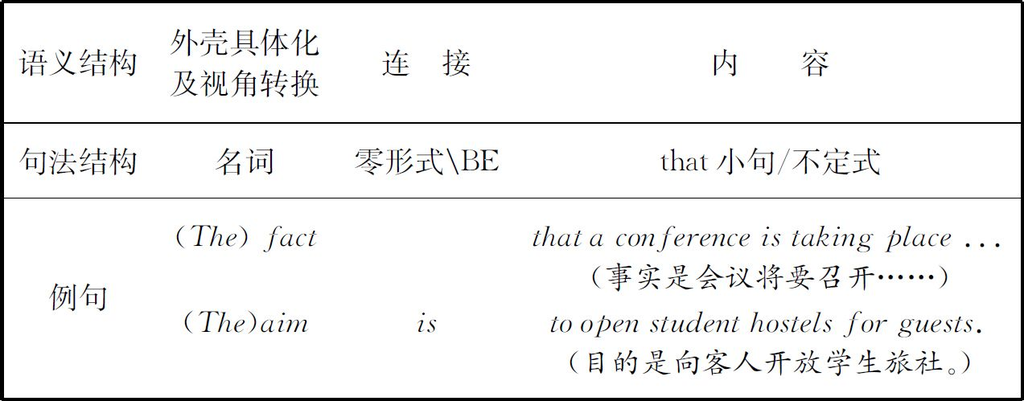

图5.24 外壳-内容构式的结构

就像论元结构构式的认知地位受到质疑一样，把外壳-内容结构视为有意义的构式的观点也受到了质疑。就论元结构构式的认知地位而言，必须证明意义并不仅仅存在于动词之中，而对于外壳-内容结构来说则要反驳这样的观点：即外壳-内容结构的认知功能只与外壳名词（fact 、aim 、chance 、problem 等）的意义有关。就论元结构而言，当我们考察idea 这种名词时，上面的反对意见可以排除：根据它们带不定式补足语还是带that- 小句，idea 这类名词会获得不同的意义。对照图5.25，在这个图中，idea ＋不定式被解释为表达了一个计划，而idea ＋that 小句则被解释为表达了一种想法。

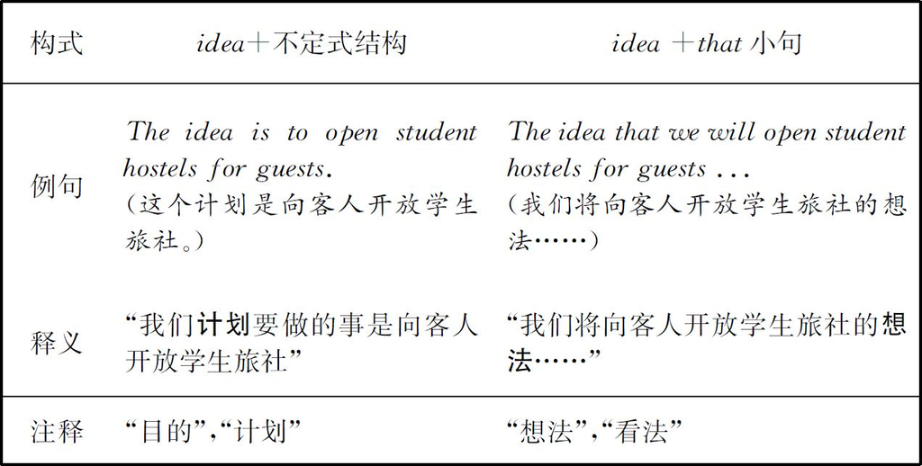

图5.25 带有非限定小句和that 小句的包含idea 的构式

然而这个发现并没有完全解决问题，因为有人还可能认为不同的意义是受了其补足语的影响：指向将来、意愿意义来自不定式，现实的、与想法有关的意义来自that 小句 <sup>(20)</sup> 。但是，通过表现如下事实，可以否定这种小句类型的直接影响：同一个小句句型对不同名词可以产生不同影响——对照图5.26。因此不定式并不总是表达“目标”或“计划”（如idea ，见上面的例子）。在task 这个例子中，它含有“义务”视角，solution 则含有“方式”视角。尤其是最后一个例子，它清楚地表明：方式意义（“The way we are going to do it …”（“我们将要做……的方法”））既不能从否定式结构也不能从外壳名词的词汇意义中推导出来。

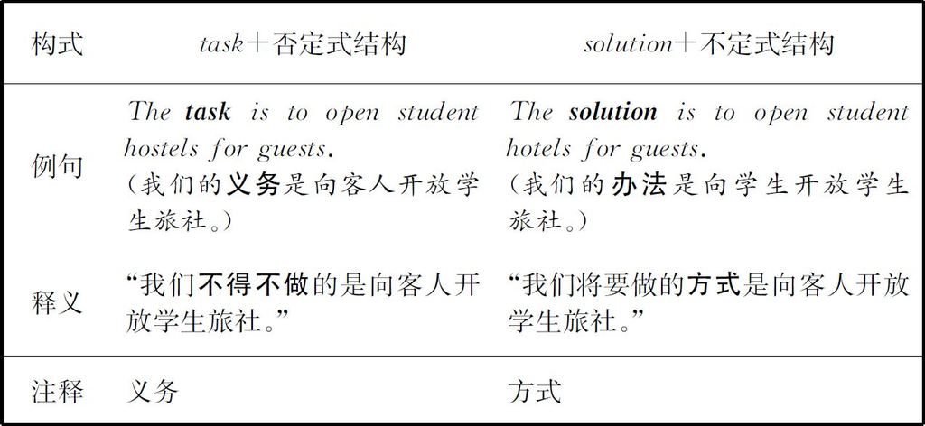

图5.26 带有task 和solution ＋非限定结构的构式

换句话说，我们不得不认为，构式的特殊意义不能从它的成分推导出来。这种非推导性或非合成性似乎是构式的一个本质的——事实上甚至是决定性的——特点。也就是这种非推导性或非合成性使构式发展成为传统上被认为是习语的语言现象。

### 作为构式的习语——作为习语的构式 <sup>(21)</sup>

“习语”这个概念在语言学领域中主要有两个处理角度：词典学角度和句法学角度。词典学家使用这个术语用来指bite the dust （失败、倒闭、死 ）这种多词项目，它们的意义无法从其组成部分的意义预测，因此强调的是它们语义的非合成性。另一方面，句法学家则倾向于认为，The bigger they come the higher the fall （爬得越高摔得越重 ）或Why not fix it yourself？ （你为什么不自己安排？ ）这类“形式上的”习语是一种结构上的例外，它们不为控制“规则的”句法结构的规则系统所涵盖，而可能受控于特殊的语用限制。例如，Him be a doctor？ （他要当医生？）或 Your brother help me？ （你的哥哥可以帮助我吗？ ）这类句法上不规则表达方式（Fillmore，Kay及 O'Connor 1988：511）只有作为回应先前言者陈述的强烈怀疑标记时才可接受。

然而Fillmore，Kay及 O'Connor并不把这些结构性习语降级为例外，他们关注这些习语，并将它们当作“不可只从其形式知道其专门语义和语用目的句法形式”（1988：505）。他们这种开创性的研究的对象是由连词“let alone”（更不用说 ）所连接的一对对句子成分。虽然同并列连词and（和）和or（或者）表面上具有可比性——它们都可用以形成同类句法成分对或同类小句对，但是，let-alone结构具有一些特殊的句法、语义及语用特征。下面这些从let alone结构真实用法改编的例句说明了这一点：

There are hardly two houses side by side in Shipley，let alone five．

（在Shipley很少由两座房子并排在一起，更不要说 五座了。）

The president dropped the pretence that the republics would enjoy greater equality - let alone sovereignty．

（总统丢弃了公众要享有更多平等的伪装，更不要说 主权了。）

We have not been able to agree on a negotiating position let alone start to negotiate with all the other groups．

（我们没有能就谈判的立场取得一致意见，更不要说 开始和其他组织进行谈判了。）

let-alone结构在句法领域中还有很多特别之处，它允许像第一个例句中的let alone five这种短语出现，而如果在下句中使用连词and（和），就不可接受：“* There are hardly two houses side by side in Shipley ，and five. ”更重要的是这种限制：两个并列成分必须表达“级差的两个点”（Fillmore，Kay及 O'Connor 1988：513）。这一点在这个例句中是显而易见的，因为两个数字（“二”和“五”配对）很显然排列一个量的语义级差上。在第二个例句中，为衡量equality（平等）和sovereignty（主权）而激活的级差是“自主的程度”，在最后一个例子中则是“谈判进展的级差”。说出以let-alone结构为基础的句子的言者显然认为：这些层级是合乎逻辑的，而听者也一定会跟着言者理解这些句子。

这些例子意味着什么？虽然像let alone这样的形式上的习语在句法和语义上都是独特的或“不规则”的，但看起来它们在句法上仍然是能产的：它们是新句子的句法模型。像构式一样，形式上的习语看起来轻而易举地为表达服务于特殊语用功能的非常特殊语义联合体储存了句法模型 <sup>(22)</sup> 。这也适用于上文提到的其他形式上的习语。例如，Him be a doctor？（他要当医生？ ）这类表达方式虽然具有特异的结构，但是在句法上仍是能产的：主语可以使用宾格，动词可以使用非曲折词根形式——比较一下Fillmore，Kay及 O'Connor（1988：511）引用的Your brother help me？（你的兄弟帮助了我？）或Her write a novel about the Spanish Inquisition？（她写了一部关于西班牙宗教法庭的小说？）这种表达方式。句法的不规则带来了这样的结果：不可能以所用词汇成分的意义为基础得到这种表达式的意义。另外，所有形式上的习语的出现都有这样的语用之力：挑战或质疑另一个会话参与者刚说出的句子（Fillmore，Kay及 O'Connor 1988：511）。因此Him be a doctor？（他要当医生？）只有回应X is going to\wants to be a doctor（X将要\想要当医生。）这种命题时才是可接受的——但是在这种情境中，这将是一个非常迅速而基本上自动产生的自然的反应。因此，把这些习语看作构式相当具有代表性的例子是具有充分证据的。

然而，反转一个角度，把构式当作习语，也是十分具有启发性的。这会相当革命性地影响我们如何塑造语言的句法成分。传统上把句法看作语法中有规则、由规则控制的部分，而词汇和所有的习语则包含必须分开存储的独特信息。那么如果构式确实对句子的生成具有影响，如果构式像词语和习语一样被储存于长期记忆中，我们就可以废除被转换生成语法及其他理论如此钟爱的句法规则。用Croft（2001：17）的话来说，则是：“构式之尾要摇句法之犬” <sup>[1]</sup> （2001：17）。这样，就可以把构式看作框架的具体化的变体，或者甚至是框架的组成部分，而框架则把下面所有的三种主要知识都储存在一起：即概念语义知识，句法知识和语用知识。

总之，本章介绍了语法构式的下面一些重要的认知语言学特征：

· 构式作为意义和形式的配对储存于长期记忆中，并根据它们的语义和句法结构以及语用适用性得以具体化。

· 以动词为基础的论元结构构式为基本小句型式的生成提供了句法模型。它们的原型意义很可能存在于框架中，而这些框架则表征对不断重现的各种事件的基本经验。

· 其他构式可能并不以相同的方式经验地存在，但都可以作为句法蓝本来编码特定认知功能（如外壳-内容构式）和\或者特殊的意义和语境（如一些形式上的习语）。

· 形式上的习语因其不规则而看起来与语法格格不入，但实际上它们可能只是“规则”构式（包括论元结构构式）这座看不见的冰山凸出的山尖，这些规则构式激活并允准所有可接受的语句。

### 练习

1．把下列句子指派给它们潜在的构式（致使-位移构式，致使-接受构式，结果构式）。哪些句子你认为是所说构式的典型例子，哪些则是更边缘的例子？

Shall I put your things into your rucksack？（我能把你的东西放在你的背包里吗？）

David has to sleep himself sober．（David不得不把自己睡清醒。）

I have sent Clarissa to the chemist's.（我已经将Clarissa送到了医院。）

Bill cooked his mother a special meal for her birthday.（Bill为他母亲的生日专门为妈妈做了一顿饭。）

Joanna helped her grandmother into the gondola.（Joanna帮助她的祖母上了小船。）

They've painted their garage yellow.（他们已经把车库漆成了黄色的。）

2．找出表达以下外壳-内容构式例句（改编自Schmid 2000）情态意义的解释，并讨论名词和构式对于总体语义效果的影响：

Their mission is to put a military spy satellite into orbit．（他们的任务是将一颗间谍卫星送入轨道。）

The risk is that the economy goes from bad to worse．（风险是经济每况愈下。）

This is the time to make the right contacts．（现在是进行接触的时候了。）

It's a wonderful place to work．（这是一个很好的工作地点。）

The fact is that people don't trust politicians．（事实是人们并不信任政客。）

The problem is to safeguard the national heritage from decay．（问题是保卫国家遗产不受侵害。）

The danger is that the damage is irreversible.（危险在于破坏是不可逆的。）

3．从Goldberg（1995）中收集致使-接受构式和结果构式多义的证据，并判定本节所讨论的三种论元结构构式中哪种是最为多义的。

4．检查下列习语及固定表达，并判定到什么程度它们可以被看作是有意义的能产构式，尤其当你考虑到它们的语用功能的时候。

kick the bucket（蹬腿了）

null and void，bread and butter（无效，生计）

an apple a day …（每天一个苹果）

boys will be boys（孩子终究是孩子）

good morning（早上好）

how do you do？（你好）

pay one，take two（事半功倍）

black is beautiful（黑就是美）

### 进一步阅读建议

5.1节

(1) 不同学科中的“框架”概念的起源，可参考Fillmore（1975：130；1976：9以次；1985：223）。

(2) 关于注意力的心理学背景资料，可以参看认知心理学的介绍，如Eysenck 及Keane（2002）或Medin，Ross及Markman（2001，第四章）。

(3) Dirven等（1982）关于speak（说）、talk（谈话）、say（说）、tell（告诉）及Atkins（1992）关于risk（冒险）的论述，是在句法及语义分析方面对于框架概念的有趣应用。后一篇文章中还有关于现在正在筹编中的一本以框架为基础的字典的信息（见由Thierry Fontanelle（2003）所编的《国际词典学杂志》专稿）。

(4) Langacker（1987a：114以次）中有关于注意力、凸显及视角三者之间关系的有点儿推测性的论述。

(5) 关于“图式”（schemas）、“综合模式”（global patterns）或“场景”（scenes）这些与框架有关的概念，Fillmore（1985：223，脚注4）是有用的参考资料。

(6) 脚本（script）概念只是Schank及Abelson（1977）整个体系中的一部分。这本书的其他部分讨论了脚本的干扰和注意力分散，还讨论了为描摹小说情景而设计的“计划（plans）”、“目标（goals）”、“主题（themes）”等概念。

5.2节

下面的大部分注释的作用是：指出了在本书中未能提及的Talmy理论框架的一些内容，还提供了两卷本的《认知语义学》（Talmy 2000）有关段落的参考资料，在此书中，他之前所发表的几乎所有著作都经过不同程度的通篇修改后收入。

(7) 所以，Talmy将原因 （CAUSE）和方式 （MANNER）指派给了外部的“伴随事件”（2000\II：27以次，220），而主体 （FIGURE）、背景 （GROUND）、路径 （PATH）和位移 （MOTION）的中心成分则构成了“框架事件”（2000\II：217）。

(8) 事件框架（event-frame）的其他类型可以参见Talmy（2000\I：271-288）。

(9) 路径起点与终点之间的区别类似于描写语法中“source”（源点）和“goal adjuncts”（目标附加语）之间的区别（参见如Quirk等1985：479，648），也可以参看Anderson（1971）有关小句型式详尽而深入的方位主义分析。

(10) 我们对于例句My bike is across the street from the bakery（我的自行车在面包店的街对面）的分析以及它所提供的视窗选择与Talmy的解释有些不同。可以参看Talmy（2000\I：269等）中他自己的分析。要了解Talmy的虚构路径概念有多么广博及与众不同，可以参看Talmy（2000\I：99-139）。

(11) 关于Talmy对致使的观点可以参看Talmy（2000\Ⅱ：69等）。

(12) 有关其“blocked complements”（隐含成分）的思想可以参见Talmy（2000\I：262-263）。

5.3节

本章的理论框架的基础是前一节讨论的事件框架概念，Talmy（2000\I：257以次）也使用这一概念。这也就意味着并没有考虑Talmy（2000\II）所介绍的所有差异。

(13) 有关法语与英语、法语与德语位移表达的风格差异的实用性解释，可以参看Vinay及Darbelnet（1975：105以次）、Malblance（1977：66以次）。

(14) Berman及Slobin（1994）从叙事篇章的比较与发展方面详细分析了五种语言（英语、西班牙语、德语、土耳其语及希伯来语）的青蛙故事。也可以参看Slobin（1996）及其后来的一些有关此领域的著作，如Slobin（2004）和Slobin（2005）。

(15) 我们的叙述风格差异的解释限于动词框架语言和卫星框架语言。Slobin（1996）和Aske（1989）中讨论了西班牙语中缺少开启视窗构式——尤其是结尾视窗——的第二种解释。

5.4节

构式语法今天被用作一系列方法的一个统称：从如Goldberg（1995）这种纯认知方法，到由Fillmore及Kay所奉行的（如Fillmore 1999，Kay及Fillmore 1999，Kay 2003）某种程度上更具形式主义的方法，再到以Croft的《激进的构式语法》（2001，2005）为代表的类型学取向的分支。由于我们的认知立场及一本导论的限制，我们将重点放在从Goldberg及Fillmore的著作中选出的一些内容。最近的有关Fillmore传统的总结可以在Fried及Östman（2004a）中找到，有关构式语法的认知方面的总结，可以参看Östman及Fried（2005a）。也可以参看Foolen及van der Leek（2000），Fried及Östman（2004b）、Östman及Fried（2005b）中的论文，以及Fischer及Stefanowitsch（2006）所做的简要概述（德文版）。

(16) Bencini 及Goldberg（2000）奉行如下观点：构式是心理真实的而不仅仅是理论的建构。

(17) 将构式解释为形式及意义的配对是构式语法与Langacker认知语法（参见第四章）相同之处。Croft及Cruse（2004：278-283）利用了这些相同之处或其他相似的对应来证明他们的更宽的构式语法的理论包括了Langacker的理论。

(18) 关于构式的多义性参见Goldberg（1995：31以次）及Croft（2001：116以次），后者（像Croft及Cruse（2004：273以次）一样）提出了原型的概念（参见第1章）。

(19) Langacker（1991：34等）使用了具体化这个概念来解释如Sam's washing of the window（Sam的擦窗户）的名词化现象。也可以参见Heyvaert（2003）。

(20) Wierzbicka（1988，第1章）提出了有关作为补足语的不定式、ing形式及that小句构式意义的最宽泛的解释。也可以参看Givόn（1990：515以次），Frajzyngier及Jasperson（1991），Frajzyngier（1995）。

(21) 我们将习语作为构式的解释主要是举例性的。有关此问题经典的（虽然不是首创的）论文是Fillmore，Kay及O'Connor（1988）。构式语法中有关习语的更广泛的解释，包括习语的类型学研究，可以参看Croft及Cruse（2004第9章）。

(22) 关于构式的语用方面参看Fillmore，Kay及O'Connor（1988：532等），Goldberg（1995：92等），尤其是Kay（2003），关于与会话有关的方面可以参看Lambrecht（2004）及Östman（2005）。

[1] 译者注：原文为“The constructional tail has come to wag the syntactic.”意为“次要的构式决定主要的句法”。

# 第六章 整合和关联

## 6.1 隐喻，转喻和概念整合

在前面的各章中我们讨论了默认为储存于长期记忆中的语言和概念结构，其中包括概念范畴、隐喻和转喻、意象图式、框架和构式。为了用一种更动态的方法代替概念化的这种颇为静态的图像，认知语言学扩大了视野，把在线语言处理也包括了进来，而这种处理传统上是由心理学家使用实验的方法进行研究的。到目前为止所提出的最著名的理论框架是这样一种理论：它研究在线语言处理（on line language processing）中心理空间是如何建构和整合的。

### 从隐喻及转喻到概念整合

解释最初由Gilles Fauconnier及Mark Turner提出 <sup>(1)</sup> 的概念整合这一概念，有一个好办法，那就是将它与第三章所讨论的概念隐喻相比较。看看以下从《新闻周刊》中的一篇文章中摘录的一段，此段为使用a shot in the arm （一剂强心针，字面意义：一次胳膊上的注射 ）隐喻表达提供了语境准备，此表达可以意译为“为某人/某物给予他们所需要的帮助或鼓励的事物”（《牛津现代高级英语词典》（OALD <sup>(2)</sup> ））：

VW's pickup man

Wolfgang Bernhard：Taking on a troubled brand．

He won't start his job until February — and Wolfgang Bernhard has already earned his future employer，German auto giant Volkswagen，many times his salary．When，in October，VW announced the 44-year-old turnaround specialist would become the No.2 under CEO Bernd Pischetsrieder，investors celebrated by raising VW's market cap by 1 billion in a single day．

Volkswagen obviously needs a shot in the arm ..．

Newsweek ，December 27/January 3，2005：58

大众的救星

Wolfgang Bernhard：正接管一个困境中的品牌

他不会在二月之前开始他的工作——而Wolfgang Bernhard已经为其未来的雇主，大众公司这一德国汽车巨人，挣得了数倍于他工资的利润。大众公司十月宣布44岁的企业转型专家Wolfgang Bernhard即将成为首席执行官Bernd Pischetsrieder之下的二把手时，投资者单日内将大众市价总值提高了10亿欧元，以此来庆祝这件事。

大众公司很显然需要一剂强心针……

如果用概念隐喻和转喻来分析（参见3.1节），“a shot in the arm ”就意味着＋经济状况良好是健康＋（＋ECONOMIC WELL-BEEING IS HEALTH＋）这个（具体的）隐喻，此隐喻的基础是＋注射代表健康＋（＋SHOT（＝INJECTION）STANDS FOR HEALTH＋）这样一个原因-结果转喻。为了适用于大众公司，还必须引入＋公司是人＋（＋A COMPANY IS A PERSON＋）这个一般隐喻。随这个隐喻的源概念人 而来的是可以在胳臂上接受注射的“身体”这一概念。＋经济状况好是健康＋（＋ECONOMIC WELL-BEEING IS HEALTH＋）这一隐喻在映射范围内得到解释，而此投射范围是植根于关于什么是好的（即健康的）或坏的（即生病的）这种基本经验之上的。

这样一来，这种隐喻和转喻的结合看上去为“a shot in the arm ”这个短语提供了一个尽管复杂却相当直接的解释。但是它却有三个方面并不符合我们关于如何理解这个表达的直觉：这个解释不考虑“a shot in the arm ”在这个文本中使用的特殊语境；这个分析把注意力集中在源概念对于目标概念的影响上，因而只提供了一个单向的解释；最后，这意味着隐喻映射只有在可以被词汇化为“（给）他们所需的帮助或鼓励”（如前文引用的《牛津现代高级英语词典》（OALD）的解释所表明的那样）时才会被完全处理。

说到概念整合，人们发现它似乎补救了所有这三个不足之处。首先，对于第一个不足，先前的语境在对“a shot in the arm ”这一表达进行认知处理时确实起了重要的作用。我们可以假设：读者读到了例文的标题、导言和第一段后，就构建了一个心理空间（mental space ），这个心理空间包括了大众公司雇用了一个新的董事等信息。我们可以把这个心理空间叫做“雇用空间”。这个心理空间是一个在线概念表征，它的构建也受未来信息的影响，除了利用大众公司、盈利、董事会 和雇员的雇用 这类已储存的认知模型之外。用Fauconnier及Turner（2002：40，102）的话来说，就是：

心理空间是我们思考和谈话时为局部的理解和行动而构建的小概念包，……（它们）运作于工作记忆中，但是它们的建立，也部分地通过激活长期记忆中已有的结构。

与雇用空间一起，未来的隐喻表达触发了第二个心理空间，可以被称为“注射空间”。这个空间提取了一个众所周知的认知模型的概念结构，此模型的典型特征是医生或护士向病人胳膊扎入装有药品的注射器进行静脉注射。同时涉及的是被激活的关于这样一个事件的目的知识，即病人健康的改善。

根据概念整合理论，这两个心理空间（即雇用空间和注射空间，可称为输入空间（input space） ）被并置且融合或“整合”。这个认知运作的结果是一个新的整合空间（blended space） ，这个空间包括了从两个输入空间映射的信息。然而整合空间并不仅仅利用输入空间，它本身也表现为新的、动态呈现的概念结构，它的结构不同于两个输入空间。为得到网络模型中的视觉表征，可对照图6.1，它利用了4.2节介绍的参与者角色术语。（注意：和Mandelblit（2000）及Coulson和 Oakley（2003）一样，在这个图和以后的图中，我们都忽略了第四个空间，即由Fauconnier及Turner在此图及此后的一些图中所提出的所谓“类属空间”，因为对于理解网络模型（network model）来说它并没有添加我们认为重要的任何东西） <sup>(3)</sup> 。

根据Fauconnier及Turner（2002：48以次），从输入空间到整合空间的映射包括了三个过程：组合，完善和细化。源自两个或更多心理空间的概念内容融入整合空间时，例如，把雇用董事看作实施注射，或把提高利润看作改善健康状况，这时就涉及组合（composition） 过程。为了理解我们例子中的整合，完善（completion） 过程也是需要的，因为“Volkswagen obviously needs a shot in the arm ”（ 大众公司很显然需要一剂强心针 ）这个句子并没有对所描述的情景具体化：不论是实施注射的人（即施事），还是注射空间所需的工具都没有在这个句子中提到。因为这些元素是注射情景不可或缺的部分并因此包含在相应的框架中，可以说，它们为了“完善”而被未具体化的句子所“推荐”。最后，细化（elaboration） 被认为是在高度动态的模式下进行的，即通过“模拟”或“运行”这个整合。这些解释性隐喻背后所隐藏的观点是：在整合空间里被识解的事件，在心理上逐渐呈现，其过程就像正确性和一致性不断被检查的计算机程序。在这个过程中，整合可以由被认为必要的、相关的或者只是有趣的信息丰富。这个细化过程的深度（同样还很可能包括持续时间）在原则上无尽头且因读者而异。回到我们的例子，一些读者可能满足于仅仅构建了下面这个包括颇为一般的信息的整合空间：新董事将以某种方法改善公司的经济前景。另一些读者则可能实际上唤起了董事对（拟人化的）公司实施注射的想像。

正如图6.1所表示的那样，输入空间不仅（通过提供必要的投射）填充了整合空间，而且还以跨空间映射（cross-space mappings） 的方式相互联系，这种跨空间映射的基础是Fauconnier及Turner（2002：89-111）所谓的重要关系（vital relations） 。对于隐喻来说显著的重要关系是同一性（identity） ，即在我们的例子里雇用新董事的行为（输入空间1）和实施注射（输入空间2）这些行为之间的同一性。为了建立整合，两个输入空间的行为映射到整合空间，很大程度上是通过了组合和完善。结果是两个空间的行为经历了Fauconnier及Turner（2002：92以次，312-325）所谓的压缩（compression） 。正如在下一节将更详细地表明一样，压缩实际上是整个整合过程最终的目标。压缩最重要的结果是，来自几个源头输入的概念复杂性大大降低了。一个新融合并统一的概念结构出现了，它在认知上易于管理，因此具有（正如Fauconnier及Turner（2002：312）所说的）“人文尺度”。在我们这个例子中，对同一性关系压缩的结果是一个新的行为联合体，在整合空间中，其新生结构被描述为“像实施注射一样雇用”的行为。同样，如同我们已经看到的，两个行为的目标被融入“像改善健康状况一样增长利润”。这表明两个输入空间对于整合中的新生结构都有一定作用，这个新生结构与两个输入空间的结构都不同，与两空间简单相加比较，也没有那么复杂。

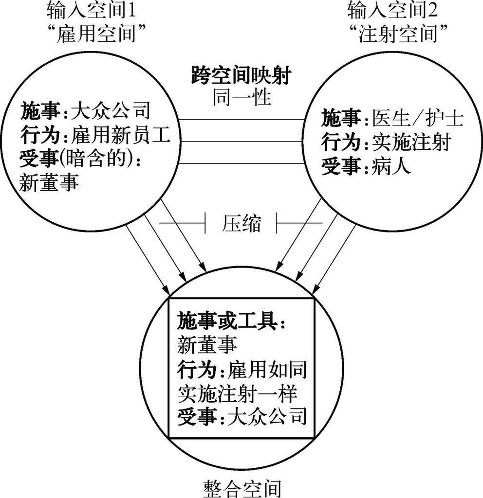

图6.1 “ shot in the arm ”（在胳膊上打一针）整合的网络图表（方框表示整合的新生结构）

至于行为的参与者大众公司，输入空间1中雇用行为的施事转变为整合空间中需要药物治疗的受事。然而更有趣的是新董事的角色。虽然他在Volkswagen obviously needs a shot in the arm …（大众公司很显然需要一剂强心针 ……）这个句子里并没有显性地提到，但是，他的角色对于理解这个句子来说却是必要的，并且将通过完善这一手段加到整合空间里。但是他的参与者角色却是含糊的。他不再代表被行为影响的成分，这是很清楚的，就像雇用空间（输入空间1）中的情形一样。有一个可能的解释，那就是，在整合空间中，他扮演的是医生这一施事角色，此角色将要向生病的公司实施注射。另一个理解是，他自己可以充当工具，因为甚至是他被雇的声明也成了一个向大众公司施以特需药的有效手段。这种含混问题并不因整合空间要“有意义”而需要解决，它们留待进一步细化。其实，它们证明了整合理论很适合用来把握这类典型的在线认知处理中的概念不确定和开放性，并且，对理解来说更重要，这似乎比那些更传统的理论更使我们相信。

现在总结一下，概念整合分析和隐喻、转喻分析存在下面的一些方面的差异：

· 概念隐喻理论与储存在长期记忆中的认知模型一起运作，而整合理论则与心理空间一起运作，这种心理空间是于在线处理时建立的，但也常常以认知模型为基础。

· 和认知模型不同，心理空间依赖语境，并包括与具体情景有关的信息。

· 隐喻被认为是从源模型向目标模型的单向映射，而典型的概念整合涉及从两个输入空间向第三个空间（即整合空间）的映射。这个整合空间表现为压缩的新生概念结构。这个运作包括了组合、完善和扩展这三个认知过程，并可以用概念融合网络进行描述。

· 限制隐喻映射的映射范围在很大程度上表征为重要关系（vital relations） （如同一性），重要关系则潜存于在输入空间之间的跨空间映射中，并在整合空间中进行压缩。

### 压缩的更多维度：空间，时间，原因-结果和部分-整体

相似性可能是压缩到整合空间中最重要和最常见的重要关系，但是还有其他的一些关系也受这种压缩过程影响 <sup>(4)</sup> 。空间就是其中之一，它产生空间压缩（spatial compression） ，下面这个句子中的“American-type tornado ”（美式龙卷风 ）这一表达就可以认为是进行了这种空间压缩的处理：

Without any warning an American-type tornado hit the sleepy French village of Châtel-les-Bains leaving a trail of destruction behind．

（没有任何警示，一股美式龙卷风袭击了平静的法国小村Châtel-les-Bains，沿路留下了一片狼藉。）

运用概念整合方法，读者会唤起两个心理输入空间。有一个空间会收集读者关于加勒比海或美式龙卷风所造成后果的知识：巨浪卷上海岸，汽车被掀翻，木屋和车库被完全夷为平地或刮走；第二个输入空间将把注意力集中于一个保护很好的欧洲村子在暴风雨中所发生的事情（倾盆大雨，也许有一两棵树连根拔起，屋瓦横飞，两边排列着石屋的街道上布满了树叶和枝干的碎片）。很显然，两个输入空间位于不同的地点，并且同样清楚的是，为使这条消息有意义，就要克服它们的空间分离。所以，为了克服它们的空间分离，这两个输入空间就被压缩。压缩的结果可能是一个整合空间，在这个整合空间中，我们关于法国乡村和这种通常由欧洲暴风雨所造成的损坏的图景跟由典型的美式风暴所造成的毁灭性结果联系起来。但是，就像“在胳膊上打针”（a shot in the arm）这个例子一样，风暴损害的确切特点及细节不会也不能真正分辨出来。这个在线过程达到的结果和对我们理解来说显然相当充分的是一种新生结构，它在两个场景之间建立某种联系，而细节则悬而未决。

与空间压缩有密切联系的是沿时间维度的压缩（compression along the time dimension） 。下面这个“regatta blend”（船赛整合）是Fauconnier及Turner（2002：63）自己的例子：

The clipper ship Northern Light sailed in 1853 from San Francisco to Boston in 76 days，8 hours．That time was still the fastest on record in 1993，when a modern catamaran，Great American Ⅱ ，set out on the same course．A few days before the catamaran reached Boston，observers were able to say：at this point Great American Ⅱ is 4.5 days ahead of Northern Light ．

（1853年，快速帆船Northern Light用76天8小时从旧金山航行到了波士顿。这个时间在1993年仍是最快纪录，这一年有一艘叫Great American Ⅱ的现代双体船出发进行同样的航行。在此船到达Boston前几天，观察员就能够说：Great American Ⅱ领先于Northern Light 4.5天。）

（Fauconnier及Turner 2002：63）

总结一下Fauconnier和Turner论述的要点，我们可以假定两个输入空间，一个包括了由Northern Light在1853年所进行的航行（及我们所能收集到的该航程的所有细节），另一个专用于Great American Ⅱ在1993年所进行的航行（同样包括了各个细节）。虽然两个输入空间之间具有高度同一性联系（涉及两艘船，它们的起点和目的地，航线以及船在航线上的位置），这些联系都被映射到整合空间之中并都以组合的方式被融合在一起，整合的新生结构主要依靠两个时间段的压缩。这个时间的压缩是“通过想像两条船的竞赛来运行整合”（Fauconnier及Turner 2002：63）的条件；时间压缩提供的是对于情景的直接掌握，而不是数学计算，数学计算将不得不把船的位置同航线的起点或者终点联系起来。

说到原因-结果（cause-effect） ，根据这种重要关系形成的压缩的好例子是由像kill （杀死 ）和break （打碎 ）这种动词所表达的致使事件，这些动词传统上被描写为“使得”和“变得”这些语义成分的融合。有一种认知语言学理论在本书（见5.2节）已经讨论过，那就是Talmy有关致使链事件中的开启注意力视窗的理论。5.2节中的例句是John broke the window （John打碎了窗户）。如果使用Talmy的理论来分析，这个例句从连续事件的一个更大的致使链中选择开启了注意力的起始和结尾视窗。此句关注的是施事John和最后的结果（窗户被打碎的事实），而其他的事件如John弯腰并捡起石头以及石头与窗户的实际接触则被背景化了。

在概念整合理论中这种下位事件的“隐藏”可以解释为在原因-结果重要关系上压缩的实例。压缩主要关注必被假定的两个输入空间中的第一个，即包含了John行为链的那个空间。第二个空间包含的是行为结果，即打碎的窗户。虽然从第一个空间到第二个空间之间当然存在原因-结果这种跨空间关系，但是，实际的话语John broke the window （John打碎了窗户 ）只将施事映射于整合空间中，而把所有的中间阶段（弯下膝盖，伸出手，抓住石头，将石头向上拿起，等等）压缩进了单个动词break （打碎 ）中。因此，压缩大大地降低了事件的致使复杂度，产生了一个认知上可控的概念单位。

说到部分-整体（part-whole） 这种重要关系，我们就进入到以我们身体经验（参见2.5节和3.1节）为基础的意象图式领域。一般说来，身体部件和作为整体的身体（或人）之间的部分-整体关系是自然而不引人注意的。然而，如果面对一幅肖像画，我们的反应是“That's Jane Do e”（那是Jane Doe ）（Fauconnier及Turner 2002：97），或者——加上另一种不同的情况——当我们听到某人在门口的声音时，如果我们说“That's Jim ”（那是 Jim），那么，就不那么完全确定我们是自动回忆起此人的整体的，尽管没人会真的认为我们只对有关人物的脸或声音进行概念化。整合的方法可能又一次有用地提供了一种比（不可能的）非转喻或完全转喻的解释更充分的分析。将人的脸（或者会话中的声音）看作一个输入空间，而作为整体的人则在另一个输入空间中被概念化，两个输入空间之间的部分-整体关系可以又一次理解为被压缩进了一个整合空间，而这个整合空间则存在一个在脸或声音与整体的人的意象之间切换的新生结构。

如果有人试图描写在整合空间中压缩重要关系所达到的目标，那么，这种目标则总是可以理解为一种统一状态。这不仅对于我们刚开始讨论的雇用新董事和医生在胳膊上打针之间的同一关系来说是这样，它也适用于对空间和时间距离成分的压缩（美式龙卷风和船赛），或者适用于原因-结果链中很多阶段的压缩（如打碎窗户的整合空间）或整体和部分（脸/人的整合空间）的压缩。

一个统一的概念在整合空间中可以被概念化为人的概念（如新董事作为医生），物的概念（整合的船赛）或者行为概念（打碎窗户）。但是，在整合空间中，统一的成分也可以作为一种特性附加在另一个概念上（就像“small boy ”（小男孩 ）或“big house ”（大房子 ）这类短语中，“small ”（小 ）或“big ”（大 ）这类修饰语被附加在中心语上一样）；这种功能将被称为整合的特性（blended property） <sup>(5)</sup> 。

要举的第一个例子是“mid-Atlantic English ”（中大西洋英语 ）。修饰语“mid-Atlantic ”（中大西洋 ）可以被理解为一种涉及美国和英国的空间关系的压缩，以表示美国-英国混合体的统一；它附加在ENGLISH（作为一种语言）这个概念上，充当一种整合的特性，指的是在某些英国杂志中发现的一种特殊英语。在“old friend ”（老朋友 ）——这个朋友当然可以是相当年轻的——这个名词短语中，“老”这一特性可以被认为是对一段很长时间中的熟悉过程的各种阶段压缩的结果。这就是为什么它具有混合特性的资格而“old man” （老人）中的“old ”（老）不具有这种资格的原因。最后一个例子是Fauconnier及Turner（2002：100）自己的。在名词性短语“warm coat ”（温暖的外套）中的“warm ”（温暖）并不表示外套具有温暖这一固有的性质，它表示的是外套是如果穿上它可以让人们变得温暖的东西。因此，“温暖”是把“外套”和“温暖”之间的原因-结果关系压缩到一个整合特性里的结果（而在“thick coat ”（厚外套 ）的“厚”这一特性则不会涉及整合）。

在考察这一系列概念压缩及其应用的过程中，人们应该考虑到，为了解释清晰，这些例子是孤立地列出的。我们所忽略的是下面的事实：压缩通常影响几个重要关系，而这些关系又可以不同的方式相互联系。除了众所周知的空间和时间关系（它们在压缩中常常结合在一起）共生体之外，我们完全可以认为，在整合中总是存在某种同一性压缩。

### 整合和巩固的控制原则

正如我们所看到的一样，概念整合是一个潜在的开放的认知过程。这就产生了一个问题：以一些重要关系为基础的压缩是否足以界定整合空间中的新生结构。为讨论概念整合而举的大量例子（“性幻想，语法，复数，个人身份，赎买与彩票抑郁”，Fauconnier及Turner 2002：309）招致了“怎么都行”（意即“万金油”，适用于所有对象——译者加）的批评（参见Gibbs 2000：349以次，Broccias 2004）。Fauconnier和Turner（2002：325-334）提出了九个控制（或优选）原则，来回应这些反对意见，这些原则决定了由特定整合所达到的压缩和统一的程度。为着简化的目的，这里将这些原则浓缩成五个 <sup>(6)</sup> 。

优选整合中要考察的第一个原则是拓扑学原则（topology principle） ——这个术语使用了认知语言学家喜爱的地理学隐喻以表示概念结构。拓扑学原则要求整合空间接收并保持输入空间概念结构的重要内容，例如，对身体和它的部件进行概念化时，要接收和保持部分-整体这种空间-内部关系；或者，对事件进行概念化时，要接收和保持事件的施事-行为-受事这种形式（就像老板雇用新雇员）。如果考虑整合过程中重要关系的重要性，那么，无论是在输入空间之间的跨空间映射中，还是在整合空间中的新生结构中，重要关系的力度和强度都应该是被加强而不是被削弱（“重要关系提升原则”），这就不足为奇了；正如前文所表明的一样，打碎窗户这个整合把打碎窗户这一行为的所有中间阶段压缩到单个动词break （打碎）中，从而密切了这个过程的起始阶段和结果之间的联系。

接下来是融合原则（principle of integration） （更有针对性的术语应该是“完形原则”），它和人们希望压缩过程应该遵循的原则有关：建立的新生结构，应尽可能具有概念“完形”特征，也就是整体概念化并易于处理成一个单位的特征，这些特征可以帮助巩固和记忆。相反，开包原则（principle of unpacking） 则确保该整合仍然能够促成整个网络的重建（Fauconnier及Turner 2002：332）。有一种极端的情况，在一个整合中，整合的正常处理方向似乎被颠倒了，输入空间实际上是从整合空间的角度来处理的。例如，在哲学演讲中，演讲的教授可以用“康德说：X，但是我反对：Y”这种形式在一个著名的哲学家和自己之间设立一种虚拟的争论。这由生活在不同时代的人之间的进行的讨论是由一个争论框架激活的，这个争论框架限定了整合空间的结构；但是，这个争论框架开包为输入框架，而这些输入框架则描写了在不同时代生活和教课的哲学家（“与康德的争论”，Fauconnier及Turner 2002：59）。更常见的也许是部分开包，也就是回到输入框架及其跨框架的投射来对暂时丢失的新兴结构的组成部分进行再概念化。在以上两个例子中，开包原则的运作是为了使整合作为在线处理而保持“开放”，并且以这种方式同融合原则竞争。

所有这些原则都参与控制在整合中的空间之间的关系，与这些原则相比，关联原则（principle of relevence） 具有的是更基本的功能，这个原则给整合的成分分配不同的重要性，以此来决定该整合按哪种方向发展。把这个原则应用到我们的第一个例子，即“在胳膊上打针”这个整合，这就意味着把新董事映射到医生这一角色（大众公司为病人）的原因就是关联。换句话说，关联是实际语境中整合背后的主要动力。同样广泛而无所不在的是以前提到过的人文尺度原则（principle of human scale） ，它被Fauconnier及Turner认为是“首要目标”。虽然人文尺度牢固地嵌入认知思维中，即嵌入原型、基本层次、部分-整体层级和从具体源概念向抽象概念的隐喻来源中，但是，关联原则为什么会对概念整合如此重要的原因，在某种程度上仍没有得到解释；这需要从不同角度进行解释，就如植根于语用学基础之上的关联理论（参见6.4节）所提出的那样。

总之，这是后两节应在第一小节末尾后面添加到概念整合的初步概述之上的内容：

· 整合中的重要关系包括意象图式（部分-整体），基本的相互关系（原因-结果），时空以及其他一些关系，它们的地位仍有待评价（Fauconnier及Turner 2002：98，100）。

· 压缩是整合过程的核心，一般涉及几种重要关系。

· 整合过程被一组控制原则限制（并优选），包括拓扑学原则，融合原则以及开包原则。

· 在理论上，控制原则的相互作用保持了不确定性和开放性这些在线特征，并确保了新生结构的人文尺度。

· 整合也受关联原则强有力的驱动，这个原则将重要性指派给整合的某些成分并把该整合与交际互动的需求联系起来（参见6.3节）。

### 练习

1．为了提供一个整合表征，对于下面的隐喻，你会提出哪些输入空间？你觉得在该整合中会出现哪种新生结构？将这种解释和以在3.1节中所提出的观点为基础的隐喻分析对比一下。

She lives at the foot of the mountain .（她住在山脚。 ）

Their love is a bumpy journey .（他们的爱情是道路崎岖的旅行。 ）

Prices are still spiraling .（物价还在螺旋式上升。 ）

2．新生结构可能仍然模糊（例如可以把新董事看作医生，或者把他看作“在胳膊上打针”这个整合中的工具）。回到第2章，找其他一些我们接受其概念的选择性和不一致性的例子。

3．找出和American-type tornado （美式龙卷风 ）、John broke the window （John打碎了窗户 ）、warm coat （温暖的外套 ）、that's Jim （那是 Jim ）相似的例子，并分别用空间、原因-结果、性质和部分-整体压缩来解释它们。

4．构建一些其他的语境，在这些语境中，运动、科学或技术的过去和现在的成就被以跟船赛整合相似的方式进行对比，并为你的例子提供整合分析。

5．指出你为练习3及练习4所提供的例子是如何在将复杂的概念化简化为易于处理的“人文尺度”的“概念包”（Fauconnier及Turner 2002：40，312，346）中起作用的。

## 6.2 语言分析与描写中的概念整合

概念整合理论的应用，数量众多、范围广泛。在语言学之外，它们的范围从认知心理学横跨到数学及计算、音乐学和考古学 <sup>(7)</sup> 。限于我们自己的领地，我们在这一节将介绍一些适于整合框架分析的词汇、语法及语用现象的实例研究。

### 概念整合与形态整合

从表面上看，使用概念整合进行分析的最明显的候选对象是它在构词领域中与构词同名的形态整合，表现为smog （烟雾 ）、brunch （早午餐 ）、motel （汽车旅馆 ）、infotainment （纪实娱乐性节目 ）等词项。当然，所有这些整合都是将两个词压缩为一个新词的结果，这一事实表明，它们都经历了从输入空间到一个整合空间的概念投射和材料组合过程。但是，对于大多数公认的形态整合来说，这个过程被看作是词语历时的一个变化阶段，而不是一个持续进行的，甚至开放式的概念化过程。许多语言使用者选择词语smog （烟雾）时，因为这个词今天高度的固化和词汇化，他们甚至不再会意识到这个整合的背景。至于brunch （早午餐 ）、motel （汽车旅馆 ），处理它们时也许会分别用到“breakfast”（早餐）和“lunch”（午餐）、“motorist”（乘汽车的人）和“hotel”（宾馆）这些输入空间，但是brunch （早午餐 ）、motel （汽车旅馆 ）也可以从新生结构概念化，而不“开包”整个整合。只有分析infotainment （纪实娱乐性节目）这一最后的例子时，整合分析才表现了它的一些解释潜力。虽然输入空间显示出极大的相似性——纪实（information）和娱乐（entertainment）是有联系的抽象原则，都表示让观众满意的方法——但是，整合空间的新生结构是开放式的；以不容置疑的方式来定义由infotainment （纪实娱乐性节目 ）表示的混合体是很困难的，并且也许甚至是没有必要的 <sup>(8)</sup> 。

有两类形态整合是概念整合分析真正的试验场：那些未能留存并格式化的整合和那些被故意认为是暂时、开放式现象的整合。选两个还未真正变成形态整合的例子，swimsation （新西兰连锁游泳学校的名字）和sportianity （运动基督教，即以运动促进、推广基督教信仰——译者加，Lehrer 1996：379）。为什么人们可能发现很容易识别“swimming”（游泳）这个概念，而对第二个输入空间“sensation”（感觉）却很难识别？对于sportianity 的“sports”（运动）和“Christianity”（基督教）也是这样：“sports”（运动）容易识别，而识别“Christianity”（基督教）却很难。在这两个例子中，连接第一个空间（“swimming”（游泳）、“sports”（运动））和第二个空间（“sensation”（感觉）、“Christianity”（基督教））的跨空间投射看起来不十分“重要”；它们不能理解为同一、空间、时间、原因-结果或部分-整体等关系。这就是为什么基本的组合和完善过程看起来不适用的原因。因此，压缩并不产生一个新生结构，因为这个新生结构超出了下面这种令人不满意的印象：整合一定跟第一个输入空间，“swimming”（游泳）、“sports”（运动）的内容有关系。

整合理论有一个更有趣的应用，它与特殊整合有关。例如，著名报纸在标题中使用它们，以此来吸引注意力和取悦读者（而不是真正想扩大语言的词汇量）。这些整合大部分预设了某种内部知识。例如，Ballacktisch <sup>[1]</sup> （“Ballacktic”）是德国著名报纸Bildzeitung （2005年6月6日）上的头版标题，它有这样的背景知识：Ballack是德国拜仁慕尼黑足球队在报纸发行时的著名球员的名字，据说他正在进行转会皇家马德里的谈判。这是另一支著名球队，实际上这个球队在当时受到如此高的赞誉，以至于获得了“银河舰队”（galacticos ）的昵称。假定读者拥有这些报纸显然希望它的读者所能具有的背景知识，人们就可以建立如图6.2所示简化网络表现的整合。

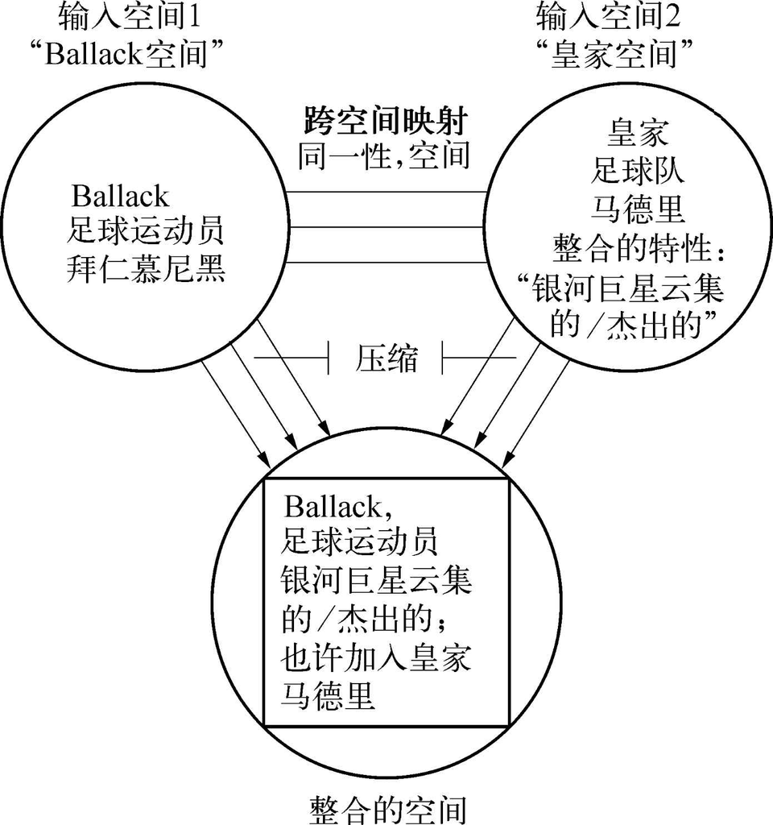

图6.2 Ballacktisch （“Ballacktic”）形态整合的网络表现

在第一个输入空间中，Ballack的角色特点首先是足球运动员（用Fauconnier及Turner的术语来说就是一种“内存空间”关系）；他是拜仁慕尼黑足球队的球员，也就和慕尼黑这个地方有联系。输入空间2对皇家球队进行概念化，其角色特点是足球队，并与马德里这个地方有联系。此外，皇家还具有“银河巨星云集的/杰出的”这种整合的特征，说它是整合的特征，是因为可以把它理解为先前整合过程的结果，而这个整合过程的基础是“天空中的星星/娱乐业明星”这个心理空间和另一个专用于皇家球队杰出特性的输入空间。

回到图6.2，我们发现，Ballack空间和皇家空间是由在涉及的人及其作为球员角色等方面的“同一性”这种重要关系的跨空间映射连接在一起的，而地点则是由“空间”（距离）关系连接在一起的。在整合空间中，“皇家是银河巨星云集的/杰出的”这一特性从输入空间2映射到Ballack 这个概念上：同一关系被压缩进一条“统一”的消息，即Ballack也可以被认为是银河巨星并因此对皇家来说也是合格的。这条消息得到产生Ballack和皇家所处地方的统一的空间压缩的支持。其结果是产生了一个新生结构，这个新生结构显示（虽然不是陈述为事实），Ballack将要去马德里加入皇家球队。将推测的传闻浓缩为Ballacktisch 这个单词正是这个著名报纸标题的目的。

在追求其即时而短暂效果时，该报编辑并不关心他们作为标题而创造的简易标签是否高度地依赖语境；就具有独立可及意义的概念巩固或词汇化而言，Ballacktisch 肯定是一个不好的候选对象。实际上，有一个简单的检测办法可以评估这个整合的在线特征。你只需问一下自己，在不需要上面提供的信息的情况下，是否也理解它（就像该报的几百万读者在报纸付印那个时候显然理解的那样）。

### 作为概念整合的复合词和缩略词

从概念整合或融合的角度讨论形态整合使我们偏离它们缩写形式的显著特征。实际上，从概念视角来看，可以把形态整合理解为一种特殊的复合词。因此，它们提供全部复合词（特别是以形容词-名词和名词-名词组合为基础上的名词性复合词）认知处理的模型实例，也就不奇怪了。像形态整合一样，这些复合词都可以用概念整合来分析，但是除3.2节中已经得到的以概念为基础的特征分析成果外，这个过程将产生不同程度的新发现。像apple juice （苹果汁）这样的组合式复合词可以被解释为两个输入空间的组合（苹果空间和果汁空间）；这里整合空间的新生结构的特点是把第一个输入空间的核心信息融入第二个空间。

至于整合过程更复杂的类型，可以举出wheelchair （轮椅 ）这种组合性稍差的复合词来说明超出wheel （轮子 ）和chair （椅子 ）这两个构成成分固有意义之外的额外属性。一种说明方法，是提出一个额外的输入空间，即“医院”，或“残疾”，或二者；另一种解释则认为，额外的意义是从整合过程中作为新兴概念结构产生的。然而，不论更详尽的整合分析如何来解释这些复合词，这些整合中的压缩都早已产生整合空间中的深层固化结构——或者，用更传统的术语来说，就是更稳固的词汇化词项，因此，使用这些词项时，不会每次都重复这个整合过程。Coulson（2001：142-144）发现，整合的在线特性只有在固化的解释不适应特定的语境时才会表现出来；她有一个相当奇特的例子，即复合词pet fish （宠物鱼 ），这个复合词一般会唤起鱼缸语境，但是可以被一个研究鲨鱼行为的生物学家用来指称她最喜欢的鲨鱼样本 <sup>(9)</sup> 。

固定意义和特定概念化之间的不一致在一些家庭对话或与亲密朋友的会话中创造的复合词中出现得尤其频繁。比如cherry jeans ，其比较固定的意义大概是“樱桃红颜色的牛仔裤”。但是，在特定语境中，“牛仔裤”和“樱桃红”这两个输入空间的概念整合可以在整合的空间中产生很不一样的新生结构。对照图6.3，整合的颜色阐释很显然是最可能的一种。它依靠涉及樱桃空间的颜色特性和牛仔裤空间的颜色特性之间的同一性这种重要关系的跨空间映射；两种颜色特性都被映射到整合的空间并被压缩进指派给cherry jeans 的“樱桃红”这一被整合特性之中。可以假设在牛仔裤的（底）布图案与樱桃的形状特性之间存在一个相似的（但较不常见的）投射，以用来描述一条印有樱桃图案的白底牛仔裤；这时，复合词cherry jeans 的基础是“印有樱桃图案”这种整合的特性，不用说，它的这种概念化将不能胜过“樱桃红颜色的牛仔裤”的固化和词汇化。

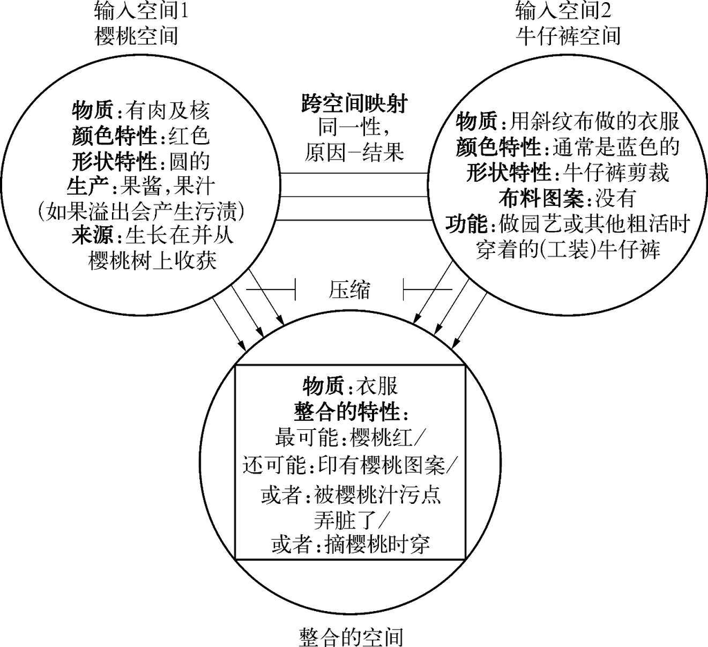

图6.3 cherry-jeans整合的网络图示

对于为6.3整合的空间中cherry jeans 记录的最后两个新生结构来说，固化并不是真正可行的。将cherry jeans 概念化为“被樱桃汁污点弄脏的衣服”预先假定这样的知识：即这种意外确实发生了。只有在这种情况下，原因（樱桃汁）和结果（牛仔裤上的彩色污点）的跨空间映射才被激活并压缩到牛仔裤的整合特性（“牛仔裤上的樱桃汁污点”）中。这个整合很可能会成为一个新词，专用于指一条从要清洗的洗衣袋中挑出的牛仔裤，而当此物在洗衣机中洗净时，这个整合将被抛弃。只在污点还在的这种不大可能的情况下，“被樱桃汁弄脏的牛仔裤”这种整合才能在家庭环境中获得可接受性。正像该整合这种样式一样，最后一个变体（“摘樱桃时穿的牛仔裤”）依靠的是（工装）牛仔裤的一个传统功能 （园艺工作，包括摘樱桃）和收获樱桃的结果（樱桃输入空间的来源 成分）之间的原因-结果关系，这种关系将被压缩到整合空间中的牛仔裤的整合特性之中。然而，这种联系的激活预设了这样一个语境：摘樱桃涉及爬上樱桃树或脏梯子，需要穿特殊衣服，加上这样的知识：所说的人已经穿上或打算穿上某条工装牛仔裤来摘樱桃。依靠这样一套知识的新生结构很难或根本不可能在更广范围内流行，更不要说永久存在了：它是依靠语境的在线概念化的典型产物。

除了二成分复合词的典型例子之外，还有三成分组合（如car boot sale （后车厢售货 <sup>[2]</sup> ），home help service （家政服务 ），health care costs （医疗费用 ），state school heads （国立学校校长 ）等；参见Schmid 2005：212以次），这些组合需要一种特殊的整合分析，这种分析适用由两个以上成分构成的缩略词（或首字母缩略词） <sup>(10)</sup> 。探讨它们的整合表现将会超过这本导论的范围，但我们还是会选取缩略词构词一个方面来讨论，因为它生动地说明了我们对整合分析固有的概念整合及描写潜能的迫切需求。缩略词的发音跟自然词一样（而不是拼写发音），一直表现出在音位学和及文字学方面模仿现有词的趋势。像TAM （Television Audience Measurement ，电视受众调查 ）或者laser （Light Amplification by Stimulated Emission of Radiation ，激光 ）一样，如果只是意味着遵从英语的音节结构，那么，这只是一个音位学问题，而并不直接影响概念整合。但是已有的英语词一旦发挥作用并被用为“固定词”（prop words），关联控制原则就会促使我们寻找固定词和缩略词意义之间的概念联系，此联系可以理解为对两个输入空间进行的概念整合。这种联系可能是显而易见的，例如历史悠久的缩略词CARE （Cooperative American Relief to Europe，美国援欧合作组织 ），可以在关怀的态度和实施该意图之间建立原因-结果关系；但常常并不如此直接，如众所周知的WASP（White Anglo-Saxon Protestant ，白盎格鲁撒克逊新教徒 <sup>[3]</sup> 或PISA（Programme for International Student Assessment ，国际学生评估项目 ）这个更新的缩略词。相对于固定词而言，缩略词的典型特点是，那种新生结构并不浓缩为一种离散的认知意义，而是会保持或包含与在线处理中的不确定性和开放性相当一致的或多或少的模糊而主观的联想。当“固定词空间”得到图画表征的支持时，这一点就更加引人注目。有一个例子是PISA测试结果的统计，用斜塔图画来图示（见《南德意志报》，2005年7月15日）。

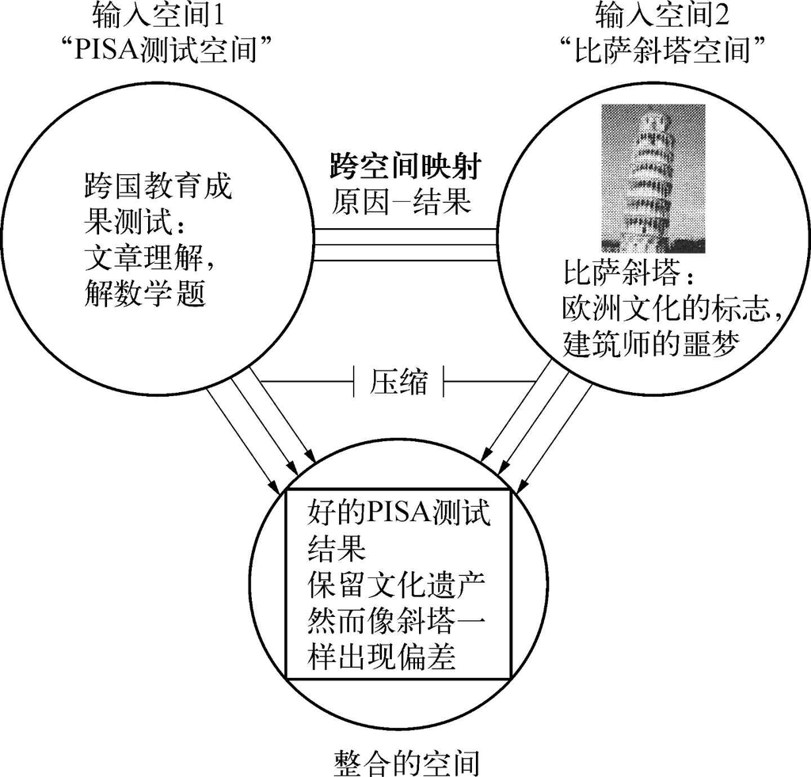

图6.4 PISA整合的网络表征（PISA测试也可以看作是先前整合过程的结果）

这一组合表示为6.4的网络图，其中，输入空间1提供的是缩略词意义的浓缩概念化（这可以看作是从一个相互分离的整合过程中产生的结构）。输入空间2提供的是对比萨斜塔的概念化，它是欧洲文化的一个重要标志，却得到了建筑师噩梦的名声。然而，两个输入空间之间存在着怎样的概念关联呢？如果我们不简单地否认存在某种关系，那么，可以假设存在一种不确定的跨空间映射，是输入空间1教育成就的测试结果（原因）和建筑遗产的文化声誉（结果）之间的一种原因-结果关系，就像输入空间2在文字及视觉上所暗示的那样。这种原因-结果关系在整合空间中压缩进一个新生结构，这个新生结构（也许是颇为模糊地）表示：好的Pisa测试结果保留为我们的文化遗产，但同时也表示教育也许出现了偏差，就像斜塔一样。

在英语构词背景下，这些缩略词（尤其是带有像斜塔一样的图画成分的组合）可能看起来像是很边缘的现象。然而，它们所引起的整合过程和在比萨整合之类的整合中产生的新生结构类型预示了此类整合在现今广告中似乎无处不在（将在下面的6.3节中讨论）。

### 概念整合，事件框架和构式

考察形态整合、复合词和缩略词产生过程中的心理空间时，我们注意到它们中的大多数都会被概念化为状态或情景。然而仍有一些心理空间具有事件的特性（如brunch（早午餐），swimming（游泳），testing students（测试学生）等），正像本章的第一个例子——shot-in-the-arm（在胳膊上打针，参见图6.1）——一样，它们可以描述为行为和参与者角色。这个整合依靠一个单一事件结构（施事/工具-行为-受事），这个结构为两个输入空间所共有，而更有趣的是那些涉及不同事件结构的例子。

举一个在5.4节构式语法语境中已经讨论过的例子，Frank sneezed the tissue off the table （Frank 打喷嚏把纸巾吹到桌下 ）这个句子也可以解释成一个在线整合，它包括三个不同的事件图式——请对照图6.5。这些事件图式中，致使事件（可解释为Frank sneezed （Frank 打了个喷嚏 ））和结果事件（可解释为the tissue fell off the table （纸巾掉到桌下 ））这两个事件图式在输入空间1中概念化（需要顺便说一下的是，这个双向的输入空间可理解为如下整合过程的产物：这个整合过程包含了对原因-结果这种重要关系的压缩）。第三个事件图式，即致使-位移事件（典型地解释为Frank pushed the tissue off the table （Frank 将纸巾推到桌下 ））包含在输入空间2中。假定两个输入空间中的事件参与者以经过压缩的同一性跨空间映射相联系，那么，结果就是整合空间中的一个新生结构，这个结构把施事 （AGENT）、行为 （ACTION）、受事 （PATIENT）和（方向性）位置 （（DIRECTIONAL）LOCATIVE）组合在一起 <sup>(11)</sup> 。换句话说，第一个输入空间的两事件形式和在第二个空间中被激活的构式合成一体，第一个空间的布局被融合原则控制。

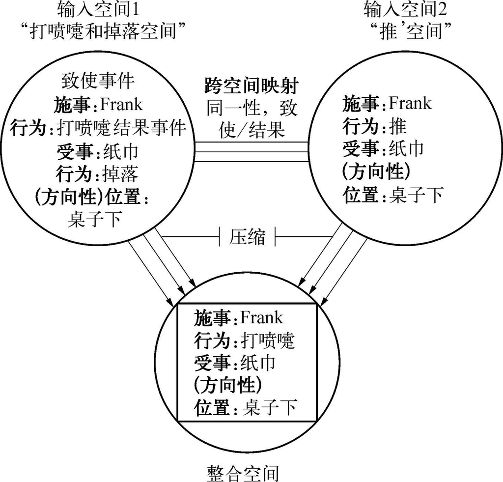

图6.5 Frank sneezed the tissue off the table （Frank打喷嚏把纸巾打到桌下）之中整合的网络表征

因为整合分析提供在线过程的表征，它也可以用来描写语言使用者面对外语学习者所使用一个构式的异常形式时脑子里可能发生的一切。以* “Susan remembered Tom of Grandma's birthday ”（Susan 使记得 Tom 奶奶的生日 ）这个句子为例。如图6.6（输入空间1）所示，动词remember （记得 ）在一个包含感事 （EXPERIENCER）-心理过程 （MENTAL PROCESS）-被感对象 （EXPERIENCED OBJECT）（即传统术语中的一个单及物形式）等成分的构式中活动，但Tom 这个名词未被说明。

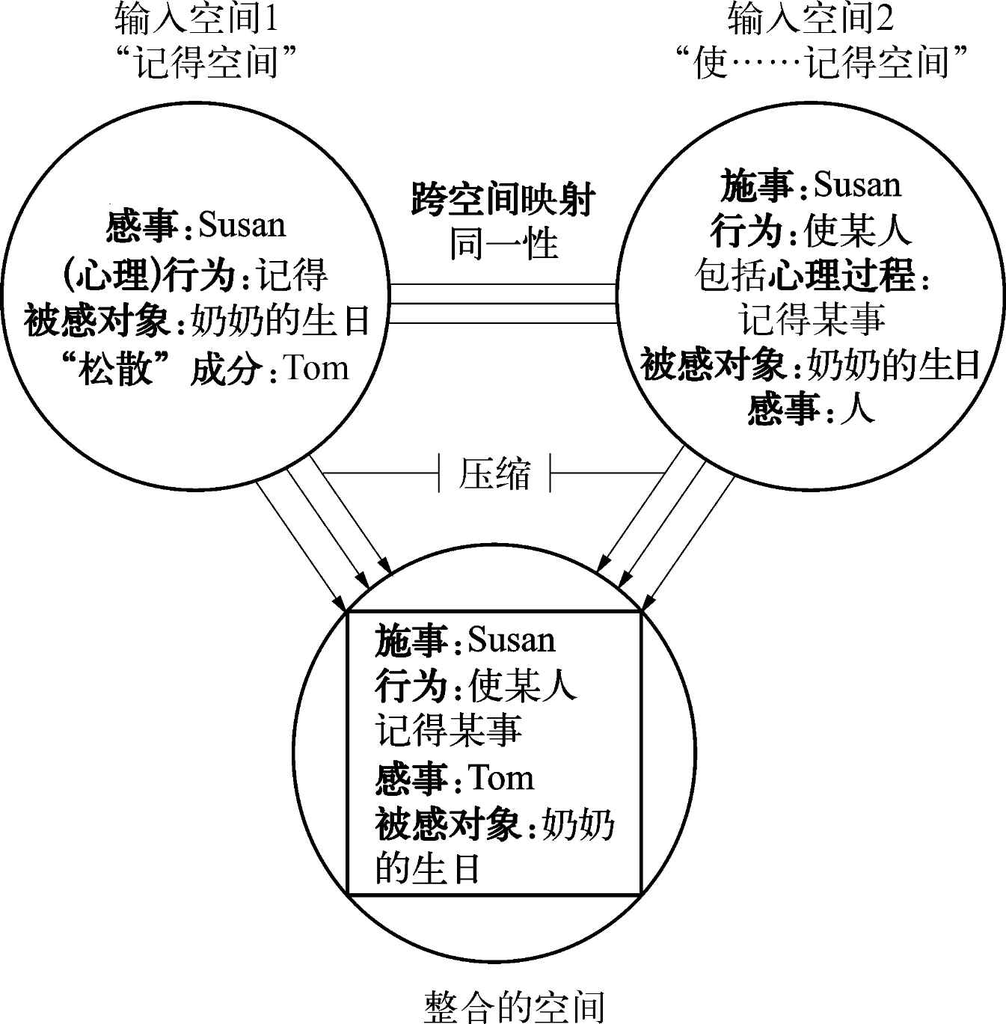

图6.6 外语学习者的错句* “Susan remembered Tom of Grandma's birthday ”（Susan使记得Tom奶奶的生日）所激活整合的网络表征

为了迁就动词remember （记得 ）的意义以及Tom 这一“松散”成分，语言使用者很可能建立了第二个输入空间，这个空间接受记得 （REMEMBER）的词汇概念，并提供一个可以安置Tom 这个成分的构式。致使-经验构式（致使-接受构式的一个变体；参见5.4节）满足了这些条件。正如输入空间2中所记录和动词remind （使……记起 ）所表达的那样，这个构式包含了施事 （AGENT）-心理行为 （MENTAL ACTION）-感事 （EXPERIENCER）-被感对象 （EXPERIENCED OBJECT）等四个成分（因为被感对象 （EXPERIENCED OBJECT）由介词of 或about 引入，这产生了一个传统术语所说的带介词宾语的双及物形式）。

假定包含在输入空间1和输入空间2中的心理过程 （MENTAL PROCESS，即“记得”）和被感对象 （EXPERIENCED OBJECT，即“奶奶的生日”）是由同一性这种跨空间关系联系起来的，那么，输入空间2中的施事 （AGENT，即“Susan”）角色映射到从输入空间1而来的错误感事 （EXPERIENCER，也是“Susan”）角色上，也就不难想像了；更重要的是，输入空间2中的感事 （EXPERIENCER） 角色被映射到从输入空间1衍生的“松散”成分Tom 之上。然而，结果却不是直接用动词remind （使……记起 ）来代替remember （记得 ），而是使用了一个最好刻画成意为“Susan caused Tom to remember Grandma's birthday”（Susan让Tom记住奶奶的生日）的新生结构。只有当学习者的错误造成了此整合这一事实被语言使用者意识到的时候，才会发生动词remind （使……记起 ）对remember （记得 ）替换，也许伴随一个像Oh，you mean ‘remind Tom’，not ‘remember Tom’ （哦，你的意思是“remind Tom”，而不是“remember Tom”）这样的句子。也就在此时介词of 在Susan reminded Tom of Grandma's birthday （Susan提醒Tom记住奶奶的生日）一句中找到了它的位置。这个整合至此实现了它的功用并将被抛弃。

### 整合，反事实假设条件句和空间建造者

像If I were you，I'd apply for the York position just for the experience （如果我是你，我只为经验也会申请 York这个职位 ）（来自ICE-GB（国际英语语料库英国英语分库））的反事实句涉及两个不同的“世界”，一个事实世界和一个反事实世界，这是语言学常识 <sup>(12)</sup> ；在整合理论中，这类句子把我们从小句型式讨论带到了言语事件和建议行为或想像行为这种语用层面上。对照图6.7，其中输入空间1关注的是当前的言语情景，I （我 ）指的是说者，you （你 ）指的是听者。说者持有某些信念和倾向，这是他或她对听者的建议的基础，其中，信念由状语just for the experience （只为经验）表达，也就是说申请工作产生必要的经验。输入空间2表示作决定这一建议（“反事实的”）行为。两个输入空间由两个空间中施事 （AGENT）角色之间的同一性关系相联系。这种联系的结果是说者从第一个输入空间被投射到听者空间的听者位置上，因此，整合是从如下的角度来看待听者的两难困境的：说者表现为不得不做决定。这表明尽管说者具有明确的自信来解释他或她自己和听者之间的“同一性”这种基本的跨空间关系，然而，做出决定的问题仍然主要是从说者的立场来看的。这个特殊的混合体在言词上强调同一性关系而同时又没有一直强调下去，也许就是它使这种表达在某种程度上产生了高人一等的口气。

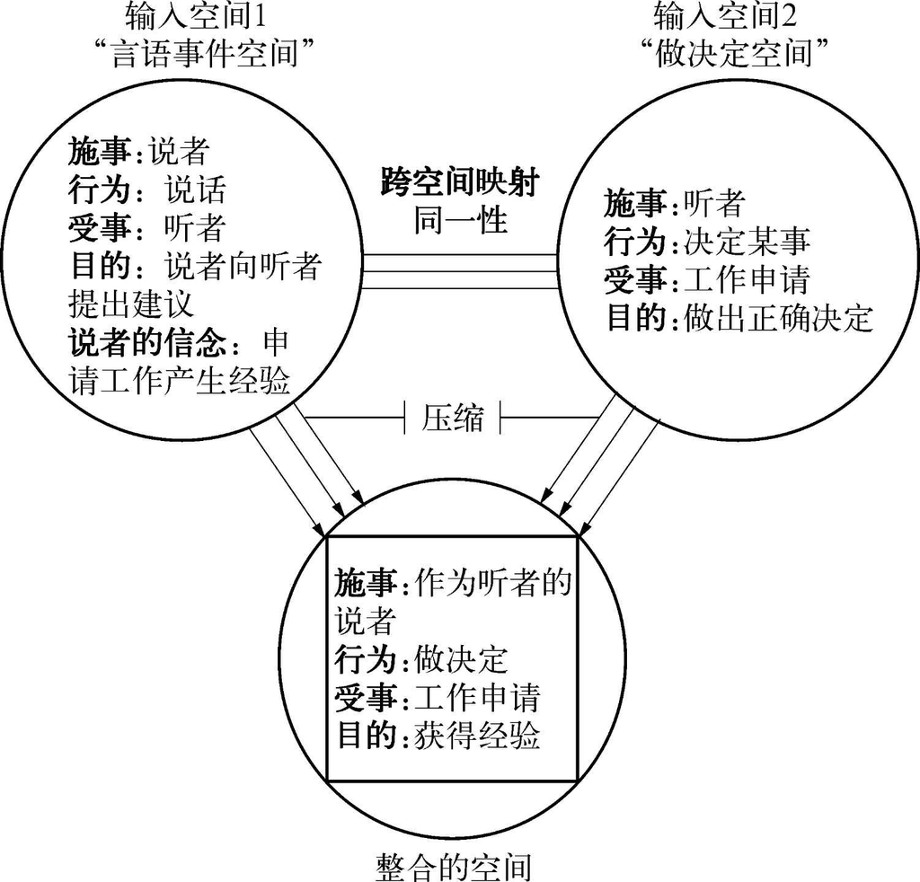

图6.7 York申请整合的网络表征（“If I were you，I'd apply for the York position just for the experience ”（如果我是你，我只为经验也会申请York这个职位））

用if （如果 ）引入的假设从句可能是建立反事实心理空间的最典型的方法，并因此可以起“空间建造者”（space builders） 的作用，但是，还有其他一些语言成分也起这种作用。按Fauconnier的定义，“空间建造者”是“一种语法表达式，它或者开启新空间，或者将注意焦点转移到现有空间上”（1997：40）。典型的例子是once upon a time （从前 ），in that story （在那个故事中 ），in the movie （在电影中 ），my daughter thinks that （我的女儿认为 ），last night I dreamt that （昨晚我梦到 ），等等。因为once upon a time （从前 ）立即激活的是一个童话空间，所以，当遇到说话的动物、鬼怪、巫婆和巫师，听到各种怪事时，没有人会觉得奇怪。同样，说in the movie （电影中 ）或in the novel （小说中 ）的时候，说者告诉听者建立一个虚构的空间，在这个空间中，如同在童话中一样，糟糕的现实中的法则被暂时中止。显然，这种空间建造者的观点给整合分析呈现了大量的语用和会话现象。

综上所述，本节讨论了各种语言实例，包括词汇整合、复合词、缩略词、论元结构构式和反事实假设条件句。分析表明，整合分析虽然完全能够描写词汇化词组或固定化构式的常见实例，然而，比起更传统的分析方法，它也可以处理更边缘但也更有意思的例子，因此它也很适合用来扩展语言学研究的领域。

### 练习

1．根据概念整合和新生结构，讨论下面较新的形态整合（选自《剑桥新词词典》，Knowles 1997）：

edutainment

＜education＋entertainment ：“带有教育性质的娱乐”

vegelate

＜vegetable＋chocolate ：“含有一定比例的植物脂肪而不是可可脂的巧克力”

feminazi

＜feminist＋nazi ：“对于激进女权主义者的蔑称”

2．把下面的复合词作为概念整合来分析一下：

Aga saga

“一种流行小说的形式，一般以乡村环境为背景、关注中产阶级的家庭、感情生活”；Aga 炉是中产阶级生活的典型特征并代表不变的安逸。

Riot girl

“年轻、好战的女权主义者”

讨论一下另一拼法riot grrl 的拟声效果在这个分析中是如何融合的。

3．对以下含有固定词的缩略词进行概念整合分析，并讨论一下源表达的首字母省略：

FIST ＜Federation of Interstate Truckers ＞（州际卡车司机联盟）

PEN ＜International Association of Poets，Playwrights，Editors，Essayists，and Novelists ＞（国际诗人、剧作家、编辑、随笔作家及小说家协会）

WAR ＜Women Against Rape ＞（反强奸妇女联盟）

4．把用于Frank sneezed the tissue off the table （Frank打喷嚏把纸巾吹到了桌子下边 ）等例子的整合分析应用到下面的结果构式例子上（参看5.4节）：

Terry wiped the table clean .（Terry把桌子擦干净了。 ）

The pupils chatted the teacher furious .（学生们闲聊把老师聊怒了。 ）

The crowd shouted the speaker silent .（群众大喊把演讲者喊沉默了。 ）

5．* I would never borrow Tom a book .（我永远不会向Tom借一本书。 ）

模仿图6.6，对英语的外语学习者造出的这个句子进行整合分析，并解释整合的过程。

6．“从前……”，从Little Red Riding Hood （《小红帽》）或Puss in Boots （《穿靴子的猫》）这类动物像人一样行动的童话中选择场景，并讨论一下整合分析如何解释这些“拟人隐喻”中的动物和人的行为的总在变化着的混合。

## 6.3 广告文本、谜语和笑话中的概念整合

大多数文本类型中都能发现概念整合，但在有些类型中概念整合采用了特殊的形式并达到了特殊效果。本节选取讨论的广告、谜语和笑话似乎就是如此。

### 作为“强加”整合的广告文体

我们对于广告文本的讨论将限于结合了文字和图画成分的印刷类广告。文字/图画组合在文献中尤其在符号学文献有过广泛地讨论，Roland Barthes（1977：38-41）已经就这种现象提出了“锚地”（anchorage，为图画提供明示和直指支持的文本）和“替班”（relay，具有互补关系的文本和图像）之间的基本区别 <sup>(13)</sup> 。因为第二类会产生更有趣的结果，我们的讨论将主要关注此类。

[figure not shown]

图6.8 www.pantene.com潘婷香波和护发素的广告（自Marie Claire ，2000年一月号）

我们所选取的例子是一个相当中规中矩的广告，来自Marie Claire 杂志英国版的2000年一月号（图6.8）；对这个广告的整合分析图示为6.9的网络形式。为了让分析简明一些，此则广告被解释为与两个输入空间有关，一个是（基于图像的）情人空间，另一个是潘婷空间（基于图像和文本的，包括实际上跨在广告两个部分中间的标题）。

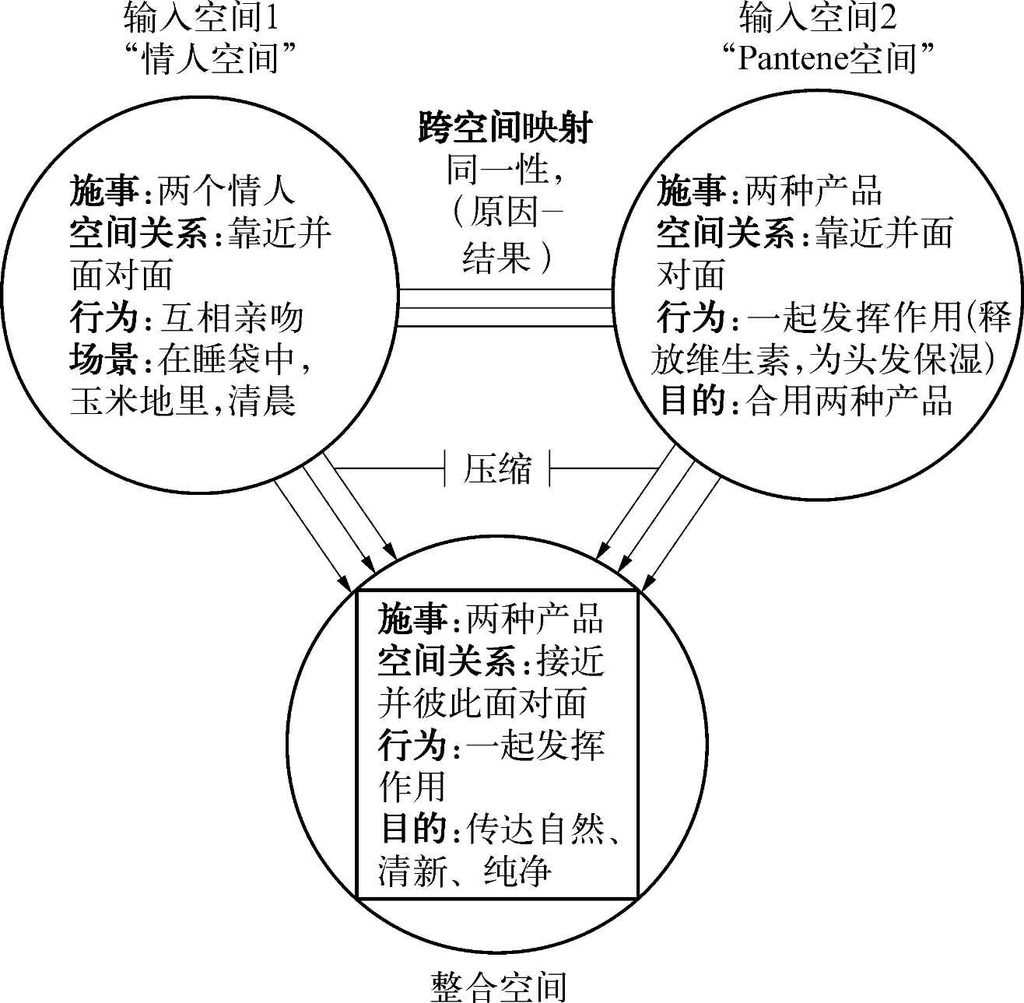

图6.9 Pantene广告整合的网络表征

在广告的图画和文字中，广告的建立，在于对参与者的跨空间同一性和涉及参与者的空间关系的明确使用。广告中有两个情人和两种产品（通过转喻用它们的瓶子来代表），并且两对都画得不仅彼此靠近，而且，甚至像瓶子那样，是面对面的。这种图画效果得到Don't go it alone and used in harmony （别单用，搭配着用 ）这种文字信息的支持。其明显意图是建立一个新生结构，在这个结构中，情人间的典型互动关系被映射到两个护发产品之间的关系上。这个文本另外强调的是无生命产品的主动性（香波提供维生素，护发素为头发保湿），即在Some things just work better together （有些事物在一起的时候会作用得更好） 这个广告标题中达到极点的一种特性。

### 谜语和笑话中的整合：把概念整合用作解决问题的工具

和广告相比，谜语和笑话可能是更边缘化的文体类型，但从理解和认知处理的角度来看，它们也是十分有趣的。因此，Fauconnier和Turner作概念整合分析时，用“佛教和尚谜语”这个谜语作为的重要的一例，就不足为奇了。这个谜语是他们从Arthur Koestler的《创造活动》（The Act of Creation ）（1964：183以次）概括成的，如下：

A Buddhist monk begins at dawn one day walking up a mountain，reaches the top at sunset，meditates at the top for several days until one dawn when he begins to walk back to the foot of the mountain，which he reaches at sunset．Make no assumptions about his starting or stopping or about his pace during the trips．Riddles：Is there a place on the path that the monk occupies at the same hour of the day on the two separate journeys？

（一天，有个和尚，拂晓开始爬山，日落时到达山顶，在山顶上打坐了几天，直到有一天拂晓，又开始往回走，日落时到达山脚。对他的出发或停留或者旅途的步速不作假定。出谜：在这两次不同的旅行中，在路上有没有一个地方是这个和尚在这天的同一时间在那里的？）

（Fauconnier和Turner 2002：39）

为了解这个谜，Fauconnier和Turner（2002：39）提出，应当想像和尚是在同一天沿着同一条路上、下山。这样假定以后，一定有一个地方，在这个地方他“遇见自己”，也就是说，他在两次旅行中都经过这个地方，即使想像中见面地点的确切位置并不清楚。

在讨论整合之后，这个解释看起来像是整合过程的另一种同义的说法（并因此被Fauconnier和Turner用作此理论的引导性例子）。把两次旅行合并起来，我们认识到，两次旅行之间一定存在跨空间的同一关系，这是一种由和尚体现的关系；此外，他两次旅行所走的线路之间一定存在空间关系，最后，也是最重要的，还一定存在时间关系。

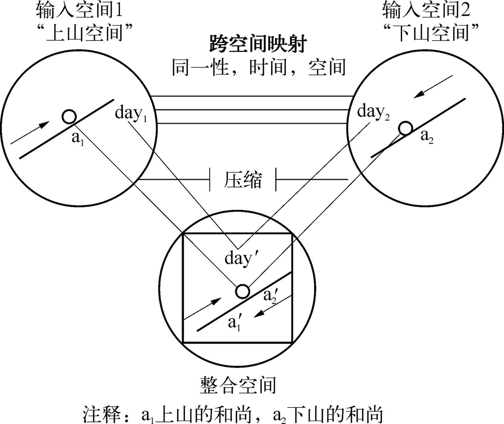

图6.10 和尚整合的网络表征（选自Fauconnier和Turner 2002：45）

虽然这个新生结构的开放性和不确定性就是如此被显性化的，但这个谜的破解，却也只能通过把两次旅行整合为一次才能达到。这表明概念整合不仅是话语（在某种程度上，还有其他的现象）解释中差不多无意识的过程，而且还可能是一个审慎选择的解决问题的策略（problem-solving strategy） 。在权衡商业、政治、当然还有私人领域中未来策略的正反两方面意见时，同样的假设情节也需要整合。这时，对几种可能的未来行为进行整合，并根据它们的假设结果作出评估。

整合理论也可以建立在更早一些的解释的基础上，尤其是Arthur Koestler的观点，他认为笑话中的原则是：

在两个内部一致而习惯上却不相容的参照框架M.1和M.2中理解一个情景或思想L［……］。两个参照框架在事件L中交叉在一起，事件L似乎被迫同时在两个不同的参照框架中来回摆动。

（Koestler 1964：35）

把笑话和两个不同的参考框架（或者两个不同的脚本，如Raskin（1985）所提出的那样）联系起来的想法，直接产生了两个输入空间的设想，而整合空间概念则恰如其分地解释了“同时在两个不同的参照框架中来回摆动” <sup>(14)</sup> 。

为了说明整合方法对于理解笑话的潜力，下面有一种孩子喜欢的例子，这个笑话中在学校的不端行为出现了出人意料的变化：

Mother：Why were you sent home early，Mary？

Mary：Well，Mum，the boy next to me was smoking．

Mother：But if he was smoking，why were you sent home？

Mary：I set him on fire．

（妈妈：玛丽，怎么你这么早被送回家了？

玛丽：啊，妈妈，我旁边的男生在抽烟。

妈妈：但是如果他在抽烟，怎么把你送回家了？

玛丽：我把他点着了。 ）

如图6.11所示，两个参照框架或脚本可以在两个输入空间中用参与者角色来表现。输入空间1记录Mary的第一句话，将施事 （AGENT）角色指派给男生，他正施行抽烟的行为。因为XY is smoking a cigarette/pipe （XY在抽香烟/烟斗）是比较固定的构式，它自动地隐含了香烟这个受事 （PATIENT）角色。Mary的主体被背景化，其地位降为旁观者 （BYSTANDER）。此外，这个心理空间还将包括了如下的百科知识：抽烟是一个常见的违反校规的行为。

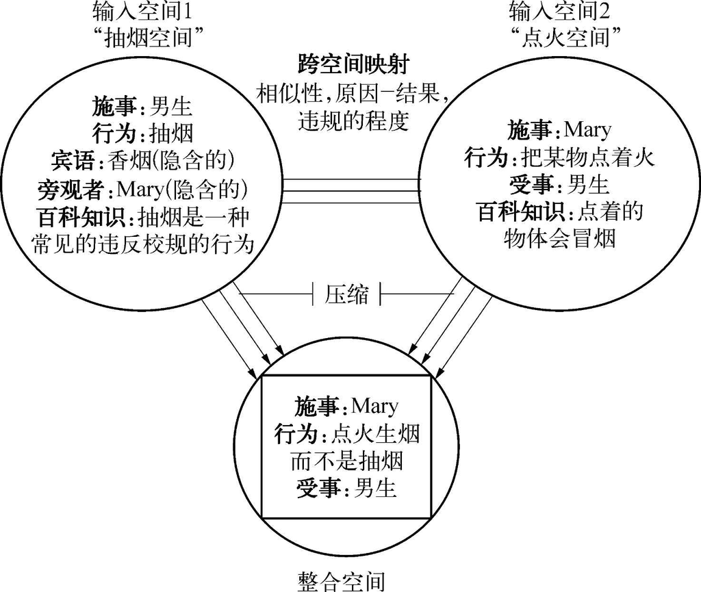

图6.11 点火笑话：整合的网络（network）表征

输入空间2用来表达笑料的内容。这时，Mary的作用是施事 （AGENT），参与了向受事 （PATIENT）身上点火的行为，由男生代表受事。因此输入空间2是一个点火空间，它包含了如下的百科知识：点着的物体会冒烟。

综上所述，本节讨论的所有各种文本有一个共同点，它们都显而易见地利用了整合中新生结构的在线特征。

· 广告文体鼓励甚至强迫读者把（常常由图像）暗示的积极效果和广告产品进行在线压缩。为了增强效果，它们通常会隐藏整合的不确定，而不是把它展现给读者。

· 有问题的谜（和未来行为的计划）是通过有策略地、审慎地整合不同事件场景并评估它们的可能结果来解决的。

· 笑话产生了一个新生结构，这个新生结构至少包括一些因为它们不相容使得整合不成功的成分，这是笑话幽默效果的来源。

### 练习

1．有一些广告努力把奢华、富有、美丽或名望等方面的联想映射到巧克力、啤酒或化妆品这类地地道道的日用品上，并因此创造了公司或品牌的某种“形象”。找出一些这种广告的例子，简要说明其中的心理空间，并指出在多大程度上它们之间的整合不是压缩的“自然”结果，而是强加于受众的。

2．根据激活的心理空间分析下面的谜，并讨论这些空间是如何在整合中被结合在一起的。是什么使得这些谜显得有趣？

Why do cows wear bells？（Because their horns don't works.）

（为什么母牛带铃铛？（因为它们的角吹不响。））

Why are mosquitoes so annoying？（Because they get under our skin．）

（为什么蚊子如此烦人？（因为它们钻到了我们的皮下。））“to get under someone's skin”作为习语，意为“让某人烦”。——译者加

What did the beach say when the tide came in？（Long time no sea.）

（当潮水涨起来的时候沙滩说了什么？（好久没海/不见。））

3．根据概念整合讨论下面的笑话，尽量找出整合中的不相容性：

After swallowing a（wind）surfer，the shark pensively looks at the empty board and sail．‘Nicely served，with breakfast tray and napkin.’

（吞下一个（风帆）冲浪运动者后，鲨鱼看着空空的冲浪板和帆沉思：“服务周到，还有早餐托盘和餐巾。”）

Everyone had so much fun diving from the tree into the swimming pool，we decided to put in a little water．

（从树上跳进游泳池里，每个人都得到那么多快乐，我们决定放一点水进去。）

（Coulson 2001：3）

A：Do you know the way to the station？

B：No，I don't!

C：Listen，you take a right turn at the next corner，then straight ahead ..．

（A：你知道怎么去车站吗？

B：不，我不知道！

A：听着，你在下一个街角向右拐，然后直走……）

Everybody likes the torero．I don't．I'm the bull．

（每个人都喜欢斗牛士。我不喜欢。我是公牛。）

## 6.4 关联：一种认知-语用现象

正如我们已经看到的那样，关联是Fauconnier和Turner提出的概念整合的一条控制原则。虽然关联概念最初被当作一条互动的语用原则，Sperber和Wilson（1995）给予了它认知转向。本节选择（并简化）看似与认知语言学思想类似的及认知语言学可能从中获益的一些方面来讨论他们的理论。

### 关联的寻找及认知环境概念

对关联的寻找似乎控制和主宰着人类对语言和非语言交际事件的理解。面对与一段与正在进行的对话显然不连贯的成分时，我们仍然禁不住追问“为什么在此时此地对我说这些？ ”例如，如前一节所说的，如果两种信息，比如广告的文本和图画，放在同一页呈现给我们，我们就会自动地假设，它们在一起出现，一定是有某种原因的，我们还会寻找它们之间某些合理的关系。同样，对话人通常会在前面的话语语境中寻找一句话的关联；即使他们没有立即意识到某个成分是如何结合进来的，他们也经常会竭尽全力来建立一种令人满意的联系。

借用Sperber和Wilson（1995：34）的一个例子，下面是一小段在饭后可能说出的对话，其中Peter的问题显然没有从Mary那里得到直接的回答：

Peter：Do you want some coffee？（你想喝点儿咖啡吗？）

Mary：Coffee would keep me awake．（咖啡会让我清醒。）

然而，虽然没有得到直接的回答，Peter还是将努力去理解这个回答，也许包括Mary不要咖啡以保证良好的晚间睡眠。很大程度上Mary的话会被Peter理解，因为他们共同拥有已是深夜这种情景信息和咖啡因影响睡眠的百科知识。用Sperber和Wilson的话来说，这两种知识就是Peter和Mary“认知环境”（cognitive environment） 的组成部分。它被定义为对Peter和Mary来说显而易见的所有假设的集合，因为他们能够在他们的物理环境中感知这些假设，或使用记忆和推理之类的认知能力推断出这些假设（1995：39）。简而言之，认知环境由假设（assumption） 构成，它们或者是储存于记忆中的，或是即时感知的，或者是即时推断的。

一个人获得的储存的知识很显然和他或她已经内化的所有认知模型（框架、脚本、情节）的总和相等。然而，虽然一些认知语言学家倾向于关注一群人共享的“理想化”认知模型，在大语用框架下进行研究的Sperber和Wilson还是强调：认知环境因人而异，也因情景而异。像前几节所提到的概念整合理论一样，Sperber和Wilson特别感兴趣的是即时意义建构，并因此强调认知能力也包括感知新增事实并因此形成新的假设和推论（new assumptions and inferences） 的能力。

举前面所引用的请喝咖啡的例子（并用它来为我们自己的解释服务），Mary“咖啡会让我清醒 ”这一晦涩的回答也会促使Peter生成新的推论，这些新推论又会生成不同的假设。其中有一个假设可能是：Mary也许想保持清醒来积极参与晚会中其他客人的谈话；另一个假设可能是：她害怕如果没有咖啡她也许在开车回家的路上睡着了。但是，Peter怎么知道这些附加推论也是Mary的认知环境的组成部分，也与她共享并因此可认为是有意传递信息的组成部分呢？

### 明示推论行为，主体/背景分离和交际关联

Peter理解Mary所思的钥匙当然是她实际所说。她确实说过的话，连同她的手势、表情和其他非语言信号，在关联理论中被称为她的“明示推论行为”（ostensive-inferential behaviour） 。从认知语言学的观点来看，这可以用主体/背景分离来理解：（所谓的）明示推论刺激 作为主体从所有那些没有被（用语言或以非语言）显性编码的潜在假设构成的概念背景中突出出来。在我们的例子中，明示推论行为最明白的实现方式也许是一个清楚的语句：对照下面这组语句，其中第一种说法明确地支持影响睡眠的假设，而第二种则适合开车的假设：

不，谢谢你，咖啡会让我清醒。

好的，谢谢，咖啡会让我清醒。

利用不同的语调形式可能是没那么明确但仍然有所帮助的，降调表示对提议的拒绝，而升调则表示接受。

明示行为也可以用身体姿势、身体的移动和眼神来表达。Sperber和Wilson自己的例子是公园长椅情景（Sperber和Wilson 1995：48-49）：Peter正和Mary坐在公园长椅上，他用一个僵硬的向后靠的动作表示，他不是想换一个更舒服的姿势，而是想将Mary的注意力吸引到一个他移动前被隐藏在她视野之外的现象上。Mary意识到这个明示推论行为如何改变了他们共享的认知环境，她给予不同的假设以凸显性，而这也将在她那一方产生一个新的假设集合（我们将在下一小节简要讨论这个问题）。虽然让某种假设具有凸显性的认知操作可以很容易地用侧显来理解（参见第4章），但变化是由会话伙伴的有意行为激发的这个观点使互动成分变得显著，而这在认知语言学思想中是被忽视的。Wilson 和Sperber（2003：611以次） <sup>(15)</sup> 强调，Peter的明示行为所传递的意图不是一个，而是两个：一是把某事告诉Mary的意图，更重要的是，把他传递信息的意图告诉她的意图；这第二个“交际性意图”清楚地反映了作为明示推论行为结果的交际关联性（communicative relevance）。

### 关联：认知效果、认知效率以及认知经济性

假定Peter的明示行为获得了想达到的效果，这正是Sperber和Wilson认为Mary的认知环境所可能发生的：

想像一下，例如，作为Peter向后靠的结果她能看到的是，在其他事物中，三个人：一个是在她坐在长椅上之前已经注意到的那个卖冰淇凌的人，一个是她以前从未看见过的普通的散步者；还有一个是她的熟人William，他正向他们走过来，而且他是一个令人讨厌的家伙。关于这些人中每一位的很多假设对她来说都或多或少是显而易见的。她在首次注意那个卖冰淇凌人的时候，也许就已经考虑了他出现的含义；如果是这样，现在进一步注意他将是对处理资源的一种浪费。陌生的散步者的出现对她来说是一个新信息，但是从中推论出很少甚至推论不出什么；所以，她能从散步者身上感知和推论的还是不可能跟她有太多的关联。相反的，从William正向她走来这一事实，她可以得出许多结论，而这些结论又引出更多的结论。因此，这是在她认知环境中发生的唯一真正相关的变化；这是她应注意的特别现象。

（Sperber和Wilson 1995：48以次）

读了这个说明之后，关联要根据对人的认知环境的影响效果（effects） 和处理短期信息的效率（efficiency） 来理解，这一点就很清楚了。从这个角度来看，关于卖冰淇凌人的假设是对处理资源的浪费，关于涉及的第二个人，即散步者的假设也是如此。相反，鉴于在Mary的认知环境中浮现的大量关于见面的令人无比厌烦的记忆，William是唯一激发重要语境效果并值得作出认知努力的那个人（哪怕只是为了设计策略如何再次摆脱他）。并且由于在认知环境中已经存储了大量有关他的信息，因此，设计这些策略所需要的努力并不太巨大。简而言之，William的出现对Mary的认知环境有积极的认知效果，而她不用花太多的努力。

对这些描写进行概括，我们可以说，有关William见面的假设满足了由Sperber和Wilson所提出的个体关联的两个程度条件：

条件1：

一个假设达到如下程度时被认为与个体相关：当此假设被优先处理时获得了巨大的积极认知效果。

条件2：

一个假设达到如下程度时被认为与个体相关：获得这些积极认知效果所需的努力是小的。

（Sperber和Wilson 1995：265以次）

因此，关联还受制于下面两个补充要求：一方面，关联依赖于一个优先处理的假设在互动的一个参与者身上所能尽量取得的积极认知效果；另一方面，关联和认知效率有关，而认知效率要求经济地（economic） 使用处理资源。对于认知语言学家来说，认知效率这个术语强烈地让人想到了认知经济性 （cognitive economy）这个概念。它由Rosch（1978）提出，并用来证明基本层次范畴在对现实世界进行概念化过程中的优势地位。Rosch把认知经济性定义为：关于一个对象的最大量信息可以用最小认知努力获得（参见2.1节）。毫无疑问，Sperber和Wilson的认知效率概念比Rosch对基本层次概念化的说明要广泛全面得多，这也正是认知语言学思想可能再一次被关联理论触动的地方。很可能值得去检查一下认知效率与认知语言学家研究的、基本层次范畴之外的其他成分与操作是一种什么样的关系。有一个有趣的候选对象，那就是整体或完形感知，它被解释为先于并通常代替根据特性进行的详细概念化的捷径（参见1.2节）。至于转喻，也有很多例子，比如，a glass （of beer ）（一杯（啤酒） ）、drive a Ford （开福特 ）、wait for White House decision （等待白宫的决定 ）（参见3.1节），它们借助易于理解的源概念而使得经济性处理成为可能。甚至有意义的句法构式使用（参见5.4节）也可以从这个角度进行研究。最后，正如已经提到的那样，概念整合显然把关联——按定义也包括认知效率——融合为它的一项控制原则。

### 假设，重要关系和压缩

关联理论和概念整合理论都注重认知处理的在线特征，但是它们使用不同方式处理问题。在关联理论中，认知环境的变化被看作是由一个明示推论行为所触发的，这种行为引起了各种各样的假设——以一串语音已经发出这一事实为基础的假设和以这个语音链的语义内容为基础的假设。Sperber和Wilson继承语用推理的哲学传统，把这些假设转换为陈述的形式，如图6.12所示的“饭做好了 ”这个例子。即使忽略了这句话的语义内容，由Mary发出的［Itlgetkəuld］这一语音序列也改变了Peter的认知环境。这反映在假设集合{A}中。如果Peter认为这些假设中有些是有关联的并把它们选出来进行处理，如（3）—（5）这几个假设，说出It will get cold （它要凉了 ）这一明示行为获得了大致与Mary清嗓子相同的效果。只有当他决定处理（6）—（7）这些假设的时候，因为它们不需要太多处理努力就可能产生最大量的认知收获，这才会导致收在集合{I}中的假设。

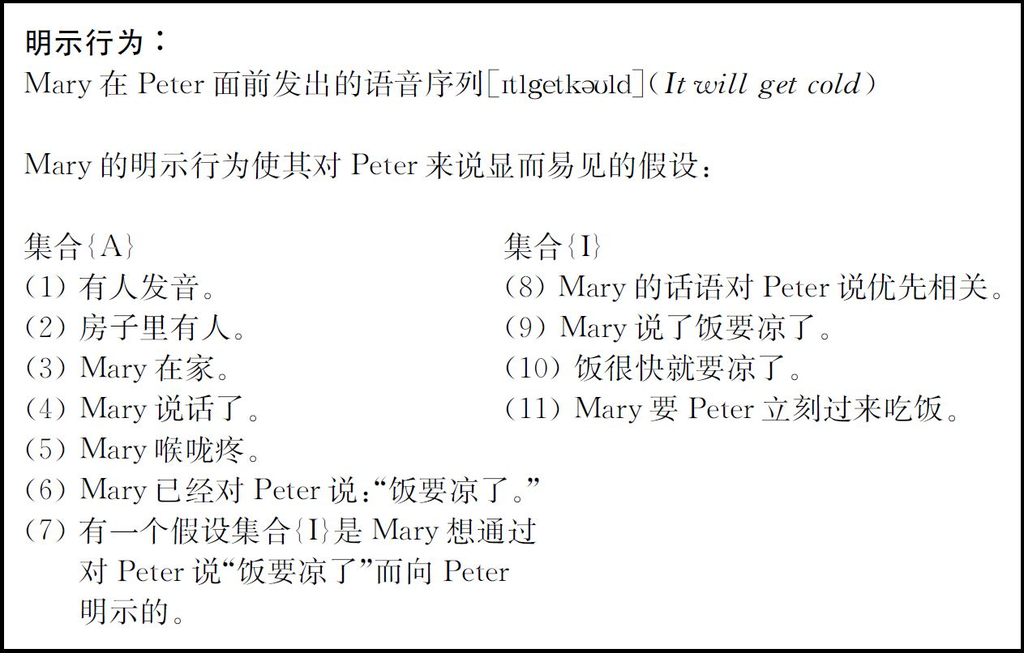

图6.12 为“饭做好了”这个例子生成的假设（选自Sperber和Wilson 1995：176-182）

这第二组假设首先陈述了（8）这个交际性关联的总原则，然后开始了下面三者之间的选择：（9）这个报告性陈述、（10）这个单纯的断言和（11）“Mary要Peter立刻过来吃饭”这个更复杂的评价。最后一个假设绝对不只是前几个假设的逻辑推论，因为它也依靠了Peter对于“在家吃饭”整个情节和Mary参与其中的记忆中的经验。对于Peter来说，它确实也高度关联，只要是为了家庭生活的和谐也很值得付出认知处理的努力。

当然，从更专业的层面看，像语音序列［Itlgetkəuld］这种明示行为是一种很间接的刺激；很显然，它所触发的所有假设，包括最后的假设Mary wants Peter to come and eat dinner at once （“Mary 要Peter 立刻过来吃饭” ），都只能被推导出来，并因此可看作隐涵（implicatures） <sup>(16)</sup> 。然而，即使Mary选择Peter，you must come at once to eat dinner because it's getting cold （“Peter ，你必须立刻过来吃饭，因为饭要凉了 ”）这种直白的语句，如果只考虑语句的词义而忽视从语句所在的认知环境得出的推论，那么，这个简单的显义（explicature） 例子（Sperber和Wilson 1995：180-183）也不能得到确切的处理。只要再回忆一下“在家吃饭”这个情节，此情节中包含的知识对于评价Mary请求的迫切性和Peter这一方迟滞反应的后果是十分必要的。

这个推论的假设系统和它的隐涵与显义的体现，如何与概念整合理论为在线处理而提出的分析方法进行比较呢 <sup>(17)</sup> ？假设系统植根于语用推理的传统，似乎为处理认知输入提供了一个颇为系统的、逻辑的方法。再次对照图6.12，其中，第一组“预备的”假设（即集合{A}：关于Mary身体的出现、她声音的状态以及话语的体现）为第二组更核心假设（即集合{I}）铺平道路，在考虑记忆中的经验之后，从第二组假设中选出最关联的一个。不论对非语言明示行为的思考的内容是什么，当这些行为包括语言成分的时候，并且当认知环境作为一个整体适用于建立假设链的时候，这个系统就运行得最好。

相反，在概念整合理论中对认知材料的处理看起来自由得多，但也模糊得多。认知输入的来源通常未真正得到探讨，但这些来源包括语言的、视觉的和听觉的刺激。认知输入集合到心理输入空间中，并得到以认知模型形式从长期记忆中抽取的材料和另外的语境材料的支持。就像6.1节讨论过的那样，在输入空间中，材料的构建和输入空间之间的跨空间投射依靠重要关系，尤其是依靠同一性关系、时空关系、特性关系、原因-结果关系以及部分-整体关系这些重要关系。重要的是这些关系没有形成一个连贯一致的系统，而作为整合空间中新生结构基础的压缩也不连贯一致。因为缺少层级性和系统序列，便产生了在概念整合中“怎么都行”的批评，也已经让Fauconnier和Turner在关联原则这种控制原则之外，还提出了其他控制原则（有拓扑学原则、融合原则和开包原则，参见6.1节）。然而，像重要关系一样，（也许是出于同样的原因）这些原则没有被组织成为一个系统层级，而实际上却在某些整合中互相起反作用及彼此抵消。

简而言之，关联理论显然更偏向于逻辑推断这一面，是典型的受哲学传统启发的语用学成果，而概念整合理论拥有更丰富、更多元的认知观，但也更含糊、更直观。此外，和本书讨论的其他认知语言学理论一样，概念整合赞成认知的整体观，这种整体观认为，语言的结构和使用与感知、注意和解决问题之类的一般认知能力交织在一起。而在另一方面，关联理论则提出了一个独立的推论模块，这个模块和一般认知只存在松散的联系 <sup>(18)</sup> 。

假定这两个理论之间更基础的思想体系差异可以调和，那么，二者是否能从一种彼此更密切的合作中得益？这是一个可以提出却无法回答的问题。例如，重要关系和压缩过程能否从存在于关联理论的认知环境和明示行为的反应更系统的组织中获益？或者，认知语言学，尤其遗憾的是在线处理理论普遍存在着对互动性成分的忽略，那关联理论的提法能否扭转这种忽略？或者，从互补的角度来看，关联理论能否通过吸收更“柔性”认知来丰富它解释的认知复杂性？

因为我们关注的是认知语言学的发展，我们将扼要重述讨论中产生的发展认知语言学的其他提法，以此来总结这个对于关联理论的简短而介绍性的简要描述 <sup>(19)</sup> ：

· 理想化认知模型的概念（框架、脚本、情节）应该推广到个体化的认知环境。

· 主体和背景的概念应该给予说者取向和听者取向的解释，以此来应对关系的认知方面。

· 与认知经济性和认知效率有关的概念在认知语言学中应该获得更广泛的适用（如在完形、转喻等的分析中）。

### 练习

1．想像一下在一条繁忙的单行道上驾驶一辆车，在乘客位置上坐着你的同伴。

街道边是树，橱窗贴着降价告示的商店，推着里面坐着婴儿的童车的年轻妈妈们，人行道上走着的貌似重要的政府官员，一群在路沿上玩球的小孩，一些沿着道路的另一边停着的车，一些正在倒入空停车位的车。

突然，你的同伴不安地喊道“小心！”，描述一下你和同伴的认知环境以及同伴的明示行为，并讨论一下从这个行为中你能推导出什么类型的假设。如果用主体和背景描写对这个分析有什么作用？

2．看看下列成对的句子，判断每对中哪一句会产生更高的认知处理效率。哪个涉及转喻，如果涉及，是什么转喻？

I'd like to have another half pint of White Label，please．（我再要半品脱White Label，谢谢。）

I'd like to have another glass，please．（我再要一杯，谢谢。）

Nine-eleven changed our view of the world．（“9·11”改变了我们对世界的看法。）

The terrorist attack against the World Trade Center in September 2001 changed our view of the world．（2001年9月对世贸中心的恐怖袭击改变了我们对世界的看法。）

If we take the car，we'll need a tankful of petrol for the journey．（如果我们用这辆车，这次旅行我们需要一箱的汽油。）

If we take the car，we'd better fill her up for the trip．（如果我们用这辆车，这次旅行我们最好加满它。）

You see the whole medical staff，doctors and nurse and all，are working to rule.（你看到全体医务人员，医生、护士和所有人正在怠工。）

You see the whole hospital is on strike．（你看到整个医院在罢工。）

3．想像一下Susan正在Tom面前读当地报纸的娱乐指南，指着Rooftop Band的一幅图片，在桌子上敲着节奏，发出了以下的语音序列［ðəIl bI ,səuld'aut baI nau］。

根据图6.12中例示的思路，指出这句话是如何在Tom身上激活一系列假设的。

### 进一步阅读建议

6.1节

本节和下几节以Fauconnier和Turner的著作（尤其是Fauconnier和Turner 2002）为基础。为了提供第一印象，他们复杂的理论已经被简化为一个易于掌握的分析工具集合。

(1) 参见Turner和Fauconnier（1995），Fauconnier和Turner（1996），Fauconnier（1997，第6章）。

(2) Grady，Oakley和Coulson（1999）讨论了隐喻和整合之间的关系。从隐喻的在线激活角度对概念隐喻理论提出的批评性说明，见Givόn（2005）；关于基本的“原发性”隐喻是整合过程的输入而不是结果的讨论，见Grady（2005）。Coulson和Oakley（2005）从概念整合的角度考察了字面意义和比喻意义之间的传统差异。

(3) 关于网络模型的概括和解释，见Fauconnier和Turner（1998：142以次），Coulson和Oakley（2000：178以次）和（2003：54以次）。

(4) 比我们所能提供的更细致的有关重要关系的讨论，见Fauconnier和Turner（2002：89-111和312-327）。

(5) 这个解释和Fauconnier和Turner（2002：99以次）所认为的“特性”是“空间内部关系”这种构建心理空间的重要关系的想法一致。注意，一方面，简单（内部空间）特性和整合的特性之间有一种平行关系，另一方面，在描写语法中所谓的内涵形容词和非内涵形容词之间也有一种平行关系（参见Quirk等1985：428以次，435以次）。

(6) 优选原则（这个名称是受音位学“优选论”启发而来的，参见Kager（1999）的介绍）最早由Fauconnier（1997：185以次）进行了简述，Fauconnier和Turner（1998）进行了论述，后来Fauconnier和Turner（2002）进行了修改并被部分更名，被称为“控制原则”。

6.2节

(7) 了解整合学者讨论的各种问题，最便捷的途径是查看概念整合理论网站：//markturner.org/blending.html。

(8) 关于词汇整合的其他认知语言学理论，见Lehrer（1996）和Kemmer（2003），从词形和概念之间同构的角度对词汇整合的研究，见Ungerer（1999）。

(9) Coulson（2001：128-133）对于有趣的名词性组合有更进一步的研究，其中有更特别的例子，但是没有充分强调它们的在线特征。Sweetser（1999）将整合理论应用来分析形容词-名词组合，并讨论了它们的可分解性。

(10) 根据输入空间之间的匹配和它们在整合空间中的相对优势，可以区分不同类型的网络，如“镜像网络”（mirror networks）、“简式网络”（simplex networks），“单域网络”（single-scope networks）和“双域网络”（double-scope networks）。 对这些类型的网络的研究，见Fauconnier和Turner（2002：119以次）。

(11) 见Mandelblit（2002：199-203），他提出了包含原因-结果事件的输入空间（提供词汇信息）和包含致使-位移构式（提供结构信息）的第二个输入空间之间的整合处理，还以此方法分析了5.4节中提到的其他位移事件构式。

(12) 有关条件句和反事实整合的研究，见Fauconnier（1996）和（1997：99以次），Sweetser（1996），Dancygier和Sweetser（1997），以及Fauconnier和Turner（2002：217以次）。关于if-I-were-you （如果我是你 ）构式的讨论，见Lakoff（1996：94-98）。

6.3节

(13) 有关图像隐喻的研究，见Forceville（1998），以隐喻和转喻方法对文本和图像之间关系进行的另一种解释，见Ungerer（2000a）。

(14) Koestler（1964）的经典模型被称为笑话的“双联理论”（bisociation theory）。Raskin和Attardo现在将他们的理论称为“言语幽默的一般原理”（历史考察，见Attardo 2001：1-29）。亦见Attardo（2003）中关于幽默的语用和认知理论的论文。关于在线笑话研究，见Coulson（2001），对卡通的概念整合研究，见Coulson（付印中）。

6.4节

这里从经验主义者的认知观角度对关联理论所做的介绍性说明，主要以Sperber和Wilson自己的论述为基础，结合了《关联》（Sperber和Wilson 1995；1986年第一版）第二版后记和最近的论文（Sperber和Wilson 2003）中作者提出的修改。关联理论现见于大量的介绍性著作，其中有Blakemore（1992）。对已经出版的语用学中关联理论的重要文献的最初概述，见Sperber和Wilson（1995：255-260）、Wilson和Sperber（2003）。

(15) 有关关联的交际原则及其在理解和认知中的作用的当今看法的简要说明，见Wilson和Sperber（2003）。

(16) 隐涵这个概念当然是由Grice（1975）在其合作原则的语境中最先引进语言哲学和语用学的，Sperber和Wilson从合作原则中的一个准则（关系准则）发展出了关联理论。

(17) 概念整合理论中语用方面的讨论，见Fauconnier（2003）。

(18) 关于赞成认知的模块性建构包括了一个专门的推导装置的论证，见Wilson和Sperber（2003：623-625），这是一个和经验主义者的认知语言学理论大相径庭的观点。在他们更早的论文中，Wilson和Sperber（2003：618）对范畴化的原型理论表示怀疑。

(19) 如何把互动成分包括在内这一灵感的另一个源头可能是Givόn的“作为其他心智的语境”，它的意思是，对认知输入成功的在线处理通常包括会话者信仰和意图状态的心智模型的系统在线构建（Givόn 2005：xiv；亦见1.1节和第4章）。

[1] 此例是由Markus Riedel，Rostock 向我们提供的。

[2] 流行于英国周末的一种卖货方式，一般以家庭为主，将要卖的物品放在后车厢内出售。——译者注。

[3] 美国社会的北欧后裔，通常被当作有权势、有影响的代号，通常为贬义。借用了黄蜂或马蜂（wasp）的词形，讽刺这类白人在历史上盛行的种族主义、排外主义、反犹太主义、反天主教和文化种族优越感心态，通常也会引起人们联想到其古板、自私、冷淡、势力、工作狂等典型特征。此词由于和wasp在词形上的关联，也可以用来指“易怒的人”、“刻毒的人”。——译者注。）

# 第七章 认知语言学的其他问题

## 7.1 象似性

在那些早就开始而非由认知语言学家首创的研究路子中，对象似性，或者更明确地说，对语言模仿世界的研究处于突出的位置。象似性起初是个哲学讨论的话题，后来符号学把它作为描写符号的一个重要参数，现在它被放在认知基础之上而已经受益匪浅。

### 象似性和任意的语言符号

词为什么有它们所具有的语音形式，词是否可以看作是真实物体与生命体的“图象”（或“模仿”），多少年来，哲学家们一直在讨论这个问题。柏拉图在他的理想国对话中 <sup>(1)</sup> ，区分出两类项目，一类是其形式和内容是由自然性质决定的，如bow-wow （汪汪 ），cuckoo （布谷 ）或splash （扑通 ），另一类的形式与内容之间的关系是以言语社团的约定为基础的，如bread （面包）或chair （椅子）。20世纪初，现代语言学的奠基人索绪尔接受了这种区别，他主张大多数词（或语言符号）的形式只是通过规约与它们表示的内容相联系，形式与意义的关系事实上是任意的。在他的理论中，像bow-wow （汪汪）这种声音象征的表达式充其量也只看作例外而已 <sup>(2)</sup> 。

然而，近来关于语言符号的这种刻板的观点已经遭到越来越多的批评。在这种背景下，19世纪美国哲学家C.S．Peirce的观点复活并成为现代符号学的支柱 <sup>(3)</sup> 。根据Peirce的观点，只有一类他称之为“象征”（symbol） 的符号，表征与对象的约定俗成的关系，因此接近于Saussure对任意符号的标准解释。Peirce提出的另两个主要的符号范畴，“指示”和“图象”，正像柏拉图已讨论过的那样，具有“自然的”基础特征。指示（index） 大致说来具有指明功能，这种功能常常通过对空间和时间中物体的定位的表达来实现。指示功能由人称代词、指示代词及处所、时间直指副词实现，如here （这里），there （那里），now （现在），then （那时）。不过，指示的概念也超出语言表达式的层次，常常以非语词形式表示，例如，天气风向标指明风向，或者，烟是火的信号。

然而，Peirce提出的第三类符号（图象（the icon） ）与象似性问题和象似性的认知解释最相关。Peirce用这个术语指那些表达与对象有一定相似性的符号。重要的是，Peirce并没有把“图象”的使用限制在对某个对象或多或少是现实的，非语词的模仿上（如计算机屏幕上使用的文件夹和文件的符号），或者，在语言层面上，也不限制在语音-象征的表达式上。除了这类图象（他称之为“映象”（image） ）之外，他把语言结构和现实中遇到的事件（以及其他现象）结构之间的相似性包括在内；对这类图象他使用的术语是“拟象”（diagram） 。

对结构的相似性的讨论把我们带入语法领域并提出了语言成分排列的问题。就这个领域提出的象似原则包括语言材料的象似顺序（iconic sequencing） 、象似邻近（iconic proximity） 和象似量（iconic quantity） <sup>(4)</sup> 。先看象似顺序，看下面两对句子：

He opened the bottle and poured himself a glass of wine．

（他打开瓶子给自己倒了一杯酒。）

★ He poured himself a glass of wine and opened the wine．

（★ 他给自己倒了一杯酒打开了瓶子。）

He jumped onto his horse and rode out into the sunset．

（他跳上马背，骑出去融入夕阳之中。）

★ He rode out into the sunset and jumped onto his horse．

（★ 他骑马出去融入夕阳之中，跳上马背。）

显然，在两对句子的第一句中，两个小句的顺序符合事件的自然时间顺序。相反，第二句至少说起来很奇怪，因为它们与这种自然顺序不相符。就句法规则本身而言，第二句没有什么毛病。然而，这两个句子还是不可接受，因为小句排列的顺序违反了象似顺序原则。

第二种象似性，即象似邻近，也许不那么明显，因为语言与语言外部的世界之间的相似关系没有那么突出。对比下列例子（基于Radden 1992：515以次）：

the famous delicious Italian pepperoni pizza

（著名的美味的意大利辣香肠比萨饼）

★ the Italian delicious famous pepperoni pizza

（★ 意大利美味的著名的辣香肠比萨饼）

★ the famous pepperoni delicious Italian pizza

（★ 著名的辣香肠的美味的意大利比萨饼）

★ the pepperoni delicious famous Italian pizza

（★ 辣香肠的美味的著名的意大利比萨饼）

这些例子表明，只有第一句是可接受的，而其他三句（以及所有其他可能的组合）都不可接受。原因在于只有第一句遵守了象似邻近原则，这条原则认为，关系近的成分必须靠近放在一起。因为pepperoni （意大利辣香肠） 是这种比萨饼的固有组成成分，所以这个词必须直接放在该名词前边；Italian （意大利） 表示产地，应得到第二接近的位置，而比萨饼的特点delicious （美味的） 和对它的评价famous （著名的） 则居于离名词较远的位置。问题在于，语言描述由线性序列成分组成，而在真实世界中，比萨饼的所有特色却融合为一个单一的物体。

在进一步研究这个问题之前，让我们看一看第三类象似性，即象似量或者量的象似性（Givόn 1990：966以次）。想想看下面的例子：

This guy is getting on my nerves．

（这个家伙 令我心烦。）

This aggressively impertinent egghead is getting on my nerves．

（这个好争吵的莽撞的学究 令我心烦。）

显然，这两个句子充当主语的名词短语的长度存在明显的差别。这种差别对应于用于描写所指人物而提供的信息量，而这被认为是象似量的表现。然而，这种观点给象似量带来了一个严重的问题：不管提供了多少信息，真实世界中被指称的那个人却还是同一个人。换言之，象似量确立了语言表达式与真实世界中的人（或物体）之间关系的观点不可能以这种简单的形式得到认可，而这正是认知语言学开始起作用的关键所在。

### 将象似性置于认知基础上：拟象象似性的例证

如果记得认知语言学家并不主张去描述真实世界的物体和生命体，而是处理我们所具有的关于真实世界的范畴和认知模型，这就为象似性关系提供了一个新的参照点。我们现在不将词和语法结构跟真实的物体与事件进行对比，而是跟我们真实世界的范畴和认知模型进行对比，这使得拟象对比容易得多，且合理得多。这意味着，就我们的例子而言，象似量就是语言表达式的长度与为描写那个粗鲁无礼的学究而引出的认知模型的复杂性之间的关系。回到我们比萨饼这个例子上，我们发现，现在，象似邻近就成了相关物体范畴（PIZZA、PEPPERONI、ITALY）和形容范畴GOOD（好） （存在于delicious 和famous 之中）的心理邻近问题。当然，第一组例子中（倒一杯葡萄酒，骑出去融入夕阳之中）的象似顺序也可以理解为语言成分序列与各自的事件范畴序列之间的相似性关系。

毫无疑问，给象似性以认知的重新解释已经推进了这个领域的研究。这项研究一个令人着迷的方面是，过去认为理所当然但实际上却未加解释的语言事实现在可以解释为象似性原则的表现。对动词形态变化的研究 <sup>(5)</sup> 已经表明，在许多语言中，体标记比时标记更靠近动词词干，而时标记又比情态标记更靠近动词词干。这在一定程度上也反映在英语动词短语中，就像下面这组例子所说明的那样：

She was working at that time．

（那时她正在工作。）

She worked a lot at that time．

（那时她工作很多。）

She could swim when she was three．

（当她三岁时，她就会游泳。）

★ She swim-could when she was three.

（★ 当她三岁时，她游泳-会。）

在第一个句子中，体标记-ing 因为用作后缀，所以最靠近动词词干，而时标记则是前置的辅助成分，因而与动词词干的联系就没有那么紧密。然而，正如第二个句子所示，不表达体时，时标记则可以附着在动词词干上，这证明它们的联系还是很紧的。而包含在第三个句子could这个形式中的情态标记“can”（could的另一个语法成分是时标记）的情况却不是这样。正如不合语法的第四个句子所表明的那样，情态标记不能移入离动词词干更近的位置，例如，把它变成一个后缀。

对认知语言学家来说，体标记与动词词干的邻近反映了DURATION（持续） 和PROGRESSION（进行） 这些语法上指定的概念与“动词的”行为范畴WORK（工作） 之间的密切关系。反之，TEMPORAL LOCATION（时间位置） （存在于时标记之中）这一概念与WORK（工作） 这一范畴之间的关系似乎就没有那么近。但是，这种联系还是比ABILITY（能力） 这种情态概念与SWIM（游泳） 这一词汇范畴之间的关系要更紧密。

再看名词的形态变化，我们发现复数标记和格标记（如与格和属格标记）的相对位置可以用同样的方式解释。最具体的物体和人被看作是易数的实体，所以表达它们的概念与存在于复数标记中的QUANTITY（量） 概念结合良好，而这就是复数标记直接附着在名词词干上的原因所在。格标记（比如，那些用介词和后缀表示的格标记）同样有其概念背景。与格标记（比如在give something to the girl （给这个女孩东西 ）中）可能是以方向意象图式为基础的（见2.4节），而属格标记（如在Peter's pen （彼得的钢笔 ）中）则可能与“部分-整体”图式有关系。这些图式也是我们经验中非常基本的部分，但比起QUANTITY（量） 这一复数范畴来，这些图式与物体和人范畴的关系似乎没有那么近。这种差异在名词形态变化中得到了充分的反映，在这种形态变化中，如果出现复数标记，格标记就通常会放在第二最近的位置。

因为英语丢失了名词大部分的形态变化，所以英语不是很好的试验场。在它所提供的少数几个例子中，有一个是属格复数形式children's （如在children's books （孩子们的书 ）中 ），这儿的“不规则”复数标记-ren 比属格标记-s 更靠近名词词干，而且这种排列顺序是不能倒过来的。

与象似邻近一样，量的象似性在认知研究中也得到了更广泛的解释。Givόn（1990）从语言表达式越长表达的概念信息量越大这个规则出发，认为语言材料的量与被处理信息的重要性和可预测性程度是相对应的。这适用于前文讨论过的那个关于学究的句子，但在下列例子中也许会更明显一些：

On the Brighton train from Victoria I met her ．

（在从维多利亚到布赖顿的火车上我遇见了她 。）

On the Brighton train from Victoria I met the girl from next door ．

（在从维多利亚到布赖顿的火车上我遇见了隔壁的女孩 。）

Just imagine! Last night on the Brighton train from Victoria I met this fair-haired，fragile，just unbelievably beautiful creature.

（想像一下吧！昨晚在从维多利亚到布赖顿的火车上我遇见了这个金发、纤弱、漂亮得简直令人无法相信的尤物 。）

显然，通常只有在所指的人既非特别重要、也非不认识，而且所指的人也不是出乎预料的情况下，（第一个句子的）代词her （她）才是合理的。（第二个句子的）the girl from next door （隔壁的女孩 ）表达了更高的概念重要性与意外性，但是这个句子很容易就被最后一个句子比下去了。在最后一个句子中，激增的语言表达式与信息的独特的概念重要性和它的意外性相匹配。在更普遍的层次上，量的象似性原则解释了为什么人称代词通常比完全的名词短语要短，为什么代词的标准形式往往比对比形式（它强调符号的重要性）要短。我们可以比较一下非重读的法语第一人称代词je （我）（在je sais （我知道 ）和 j'aime （我喜欢 ）中）和对比形式moi （我 ）。

### 拟声词（声音象征）的认知观

认知语言学家主张，在语言项和被谈论物体的概念化（不是物体本身）之间建立象似关系，有助于更好地理解声音象征词或者拟声词（即Peirce的映象） <sup>(6)</sup> 。从通常认为的原型的声音象征（在Peirce的术语中是“映象象似”（imagic iconicity） ）、对动作或者“自然的”动物的声音的模仿出发，如图7.1所示，不同语言的拟声词不同，这是不足为奇的。这不仅仅是从声音象征词被接受进入词汇开始，语言经历了不同的语音发展过程的问题——有一个例子是英语bow-wow （汪汪 ）和德语wauwau ，它们的开首唇音的发音（和拼写）不同。由于我们对世界的感知是由文化模型决定的，因此说不同语言的人在概念化过程中倾向于突出动物声音的不同方面——和阿拉伯语的haphap 比较一下，与它更接近的是英语的woof-woof （汪汪 ）以及法语中的ouaf ouaf ，而不是bow-wow 。与此相似，如crash （哗啦声） ，creak （嘎吱嘎吱声） ，crush （咔咔声） ，Crunchies （嘎吱嘎吱声） 中的辅音丛/kr/既可以传达对刺耳的讨厌的嘎吱声的概念化，也可以传达对吃谷物早餐时所经历的嘎吱嘎吱声的愉快印象。

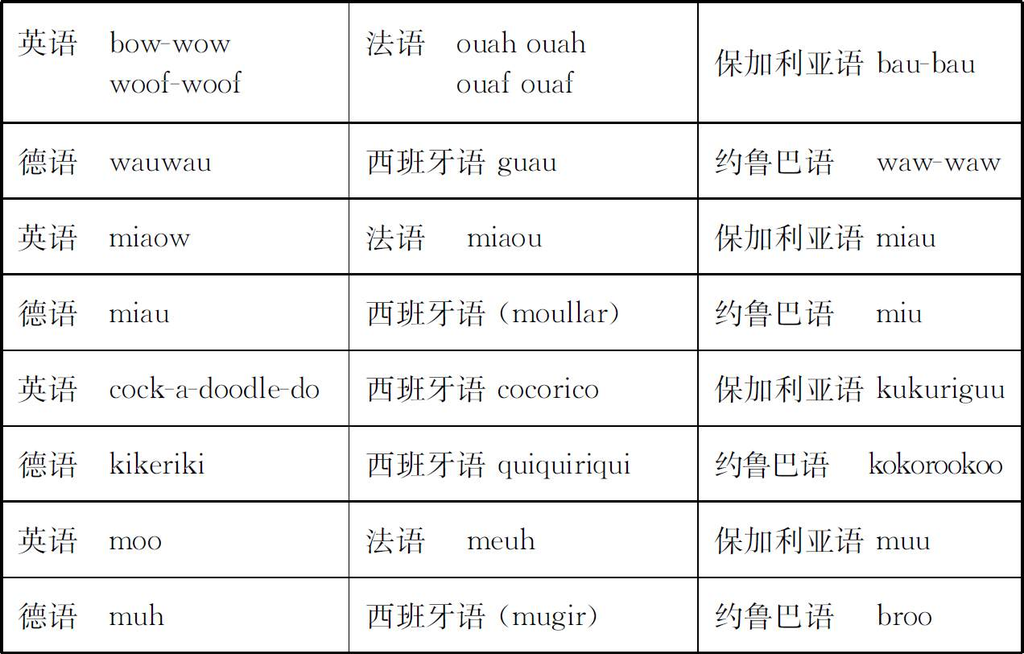

图7.1 精选的语言中动物声音的拟声表达

认知理论还解释了“次要”的语音-象征的辅音丛的效果，它从一组包含某个辅音丛并表达相关意义的词语发展而来。典型的例子是以辅音丛/sw/开头的英语词语，如swing （摇摆 ），sway （摇动 ），sweep （吹走 ），swirl （旋动 ），swagger （大摇大摆地走路 ）。因为所有这些词都表达摆动的意思，所以它们产生了这样的印象，即/sw/象似地反映了摆动的运动和声音。

最后，认知阐释还可以剖析那类最令人困惑的拟声词，即诱发联想或联想的声音象征，其中有一种说法是，前元音/i/代表小，明亮和令人愉快的感觉，而后元音/u/和/o/则意味着粗大，强大和令人不快的感觉。人们还注意到一个相似、但不那么明显的积极联想和消极联想，就是清辅音和浊辅音之间的差异（Masuda 2002）。从1929年Sapir的研究开始，这些联想在实验中得到反复证实，在Sapir的研究中，要求被试把最小的无意义的话段，如［mil］和［mal］指派给大的和小的物体。

好的/坏的联想也被作家用来给虚构的人物取名以及为这类人物创造人工语言。在这些例子中，象似性的认知观点尤其令人信服，因为这些名字的所指并不“活”在现实当中，而只是活在读者的想像中。有一个很好的例子，是Tolkien经典的Lord of the Rings （指环王），从该书选取了下面这些人物的名字（Podhorodecka，待刊） <sup>(7)</sup> ：

Aegnor，Carcharoth，Draugluin，Earendil，Gorthaur，Idril，Celebrindal，Lúthien Tinúviel，Míriel Serinde，Morgoth，Túrin Turanbar

当询问被试（他们中的大多数都不熟悉Tolkien的作品）他们认为这些名字中哪些适合正面人物，哪些适合反面人物时，大多数人与Tolkien的指派一致，这种指派的基础是前元音对正面人物、后元音对反面人物强势性：

正面人物：Aegnor，Earendil，Idril，Celebrindal，Lúthien Tinúviel，Míriel Serinde

反面人物：Carcharoth，Draugluin，Gorthaur，Morgoth

中间的：Túrin Turambar

在Tolkien编造的三种人工语言，即Sindarin和Quenya这两种“正面的”Elve人语，与Black Speech这种“反面的”Ork人的语言中，也观察到前元音/i/和/e/与后元音/u/的分布呈相似的关系，这种分布还伴随着辅音和元音比例上的显著区别，如图7.2所示。

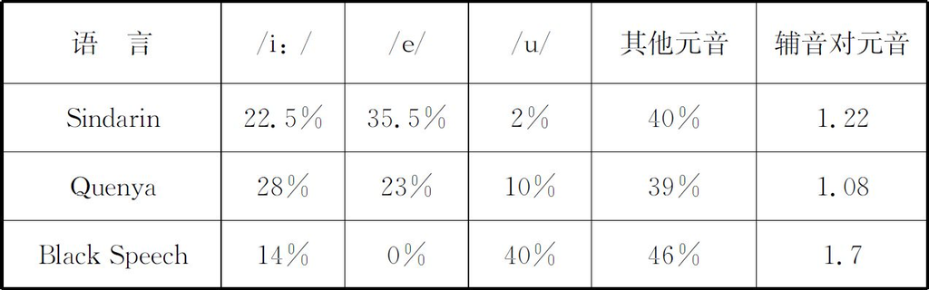

图7.2 Tolkien人工语言中元音的分布，辅音和元音的配比（选自Podhorodecka，待刊）

Tolkien对诱发联想的声音象征的使用只是一个极端的例子，在很多文学文本中，尤其是在抒情诗中，都能找到这种现象，如Leech（1969）说明的Tennyson的“Oenone”（俄诺涅）——见图7.3。读这首诗时，没人能否认众多的前元音（包含在11.1-4中）有助于创造一种愉快的基调，而后元音（11.7-8中）则倾向于描绘忧郁的气氛 <sup>(8)</sup> 。

Oenone

［1］There lies a vale in Ida，lovelier

［2］Than all the valleys of Ionian hills．

［3］The swimming vapour slopes athwart the glen，

［4］Puts forth an arm，and creeps from pine to pine，

［5］And loiters，slowly drawn．On either hand

［6］The lawns and meadow-ledges midway down

［7］Hang rich in flowers，and far below them roars

［8］The long brook falling thro，the clov'n ravine

［9］In cataract after cataract to the sea．

Alfred Tennyson

图7.3 Tennyson的诗歌“俄诺涅”

所不同的是，不像Tolkien的例子，这些诗歌的词语不是编造的，而是自然语言的一部分，具有由语音-象征效果支持的词汇意义。

当我们尝试以诗歌中观察到的诱发联想的声音象征转而观察整个语言时，问题就产生了。在诗歌中，艺术家将词汇的和声音象征的“意义”精心融合成一种共生关系，但在日常语言使用中进行检验时，这种关系就破裂了。不论我们有多少这种共生关系，在词汇的音系形式之下都不存在语音-象征原则。有点儿讽刺意味的是，英语中，前后元音相应的小/大（small/big）和好/坏（good/bad）联想被表达这些概念的两对形容词的语音形式取消了，在很多其他语言中也是如此。

面对词汇意义和语音-象征意义之间的矛盾，传统的语言学家很难接受诱发联想的声音象征的存在和关联，这并不令人吃惊。在Peirce传统之下进行研究的符号学家则认为这比较容易，因为他们会把词汇符号，如big （大） 和small （小） 归入“象征”范畴，而把矛盾的语音-象征效果看作象似映象。然而这只是一种实际上向这个问题妥协的认知语言学解释。首先，最核心的联想，也就是小/大的对立，可以分别与发/i/和/u/语音时口腔产生的共鸣腔的小和大这些身体经验相联系（Masuda 2000）。其次，也是更重要的，经验主义的研究已经表明，人类的概念化承认不同的，甚至是矛盾的概念，并能够轻松地处理相互竞争的语言表达式。例如，我们能不费吹灰之力根据恰当的语境换着使用拟声的bow-wow （汪汪 ）或miaow （喵喵 ）和词汇形式dog （狗）或cat （猫），既然如此，我们并不难承认诸如small 和big 这样非象似词汇象征与称小语音/i/象似用法的共存，也就顺理成章了。

### 文本策略的象似解释

在语言层面，映象象似性一般影响各个词语，而拟象象似性，正如前面所讨论的，似乎与语言输出的数量、与短语和句子中的语言成分的排列有关。然而没有理由阻止我们将象似解释推广到更全面的文本结构上，并把它们与对世界的范畴化中使用的复杂的行为形式联系起来 <sup>(9)</sup> 。

有一个最为明显的例子，那就是路径策略（path strategy） 。它可以在很多文本类型中观察到，同时牢固地扎根于我们的概念化中。正如前面章节讨论过的，路径概念不仅被看作是反映我们身体体验的基本意象图式之一（2.3节），而且是主体/背景对立的一个不可缺少的组成部分，因而提供了射体这个概念，而射体概念是主体的动态解释的基础（4.1节）。路径也是位移事件图式的核心（5.1节），对视窗开启做出不同的选择（5.2节），而且作为位移事件的组成部分，它在不同语言中以不同方式得到反映（5.3节），更不用说它支撑着重要的句法构式（5.4节）。

要用路径概念来理解文本，我们必须考虑——至少在可读的而易用的文本中——读者不是完全不受拘束并被迫在文本中“找到自己的道路”，而是受到作者温和的引导。因此设想路径策略的较为恰当和实际的方法是设想一个这样的情景：某人沿着一条路径引导另一个人，例如本地人引导外国游客到新的目的地，或者导游带领旅游团参观古堡、花园或公园。从这个视角看，路径策略所包含的要比简单的A-引导-到-B关系多得多。它包括沿着某一路径行走的行为，这种行为就其本身而言就是一个复杂的行为。这个行为结构的其他成分是：邀请某人同行时达到高潮的揭幕仪式，在不同路线中作出选择，指出在行程中遇到的有趣的事物，对它们进行解释，最后是恰当的结束仪式。所有这些都是典型的旅游指南和手册的作者在描写游览建筑、城镇等的导游行程时将包括在他们作品中的东西，也是读者希望在这些文本中找到的东西，因为他们自动地将他们的路径和导游观念从他们自己的认知体验转移到他们的文本理解上。然而这并不意味着支撑旅游指南的象似关系要依赖路径策略个人属性逐个的转移，即使用一种核查清单的方法。更有可能的是，某个文化模型中形成的综合行为结构的整体转移（holistic transfer） ，这是一个可以和具体物体的整体感知或完形感知相比照的认知过程（1.2节）。读一段威尔士庄园主宅第旅游情况的介绍手册的简短选段，它说明了像step over （跨过 ）和enter （进入） 以及“路径动词”guide （带领） 这类一般位移动词是如何与讲话的祈使形式、问候程式以及描写的细节（穿着当时的服饰 等）结合起来、以创造出被带领着参观这所建筑获得的丰富而生动的印象的。

Step over the threshold of Llancaiach（pronounced glan kayack）Fawr and travel back over 350 years to a time of great unrest and Civil War in Wales．As you enter the manor house you are greeted by the servants of ‘Colonel’ Edward Prichard，dressed in period costume and speaking in the style of the 17th century，who guide you around the manor's many beautiful rooms with fascinating tales of life in a Civil War gentry household．

（跨过Llancaiach（念做glan kayack）Fawr的门槛，回到350多年前的大动乱和威尔士内战时期。当你进入庄园主宅第，你会受到Edward Prichard上校的仆人迎候，他们穿着当时的服饰，用17世纪的风格说话，他们会带领你参观庄园里很多漂亮的房间，讲述内战时期上流社会家庭引人入胜的生活故事。）

（选自：Llancaiach Fawr 庄园。这里复活历史！；旅游手册 ）

诚然，如果文本路径策略仅限于旅游指南，那么它不值得受到那么多注意。重要的是这种原型策略为说明书、程序文本（菜谱、教人自己动手的手册等）、按序时记录（非虚构的文献资料，历史小说，传记等）等大量的各式各样的文本结构充当参考。提出路径和导游的整体转移的观念，还有另一好处：它的效果超出了语言媒介，也就是说，它得到把语言、视觉和听觉要素及其相互影响综合起来的动态解释，而这对理解景点推介和其他电视类型是非常重要的。

面对这种情形，人们也许会问是否存在其他路径策略，或者，它是不是可利用的唯一得到象似支持的文本策略。考察电话号码簿（或词典）和新闻报道这类相距甚远的文本类型，很难把它们的基础理解为引导读者从一项到下一项这样的策略。在按字母排列的文本中并不存在真正的引导性质，而且，如果我们看一看典型的新闻报道，它们遵循着自上而下的原则，按照递减的重要性顺序排列项目，这常常和空间路径或时间先后顺序观念有出入。然而，如果要找一个我们如此自然地接受这些文本排列的原因，那似乎就是这类文本也能够依靠象似支持。

有一个讨论的起点可能是这样的观察结果，那就是，按某些结构排列物体的才能（甚至是冲动），小孩子就已表现出来且为我们终生受用的能力之一。尽管乍一看也许不明显，但是这种分类策略（sorting strategy） 也是一种内容丰富的策略，它包括汇集材料、分析分类参数（大小、形状、颜色和价值）、找出最合适的分类原则（分成对、三个的组合、四个的组合、十二个的组合），把分类过程分成合适的阶段，最终决定分类结果的显示（线条的、圆形的表现等）。分类策略常常和加权策略（weighting strategy） 结合在一起，意思是按照分类参数向上或向下排列项目，这为加权过程提供了起始焦点或结尾焦点。这在语言中有一个应用，那就是在语言信息单位的分析中，分类-加权策略能够为指派给主题凸显（或起始焦点）和结尾焦点的角色提供概念支持。更为重要的是，再次假定一个综合认知策略的整体象似转移，分类-加权策略可以用于解释对地址簿中字母分类的普遍接受，还可以解释新闻报道自上而下的结构的成功之处或者像运用于注重修辞的演讲、奇闻轶事、笑话中的结尾焦点策略。

综上所述，认知语言学理论把象似性理解为语言（还有视觉的、听觉的）层面 <sup>(10)</sup> 和概念化层面之间的关系，有几大好处：

· 指称自然声音（风、浪）和动物叫声（bow-wow 汪汪，miaow 喵喵）的拟声词（象似映象）不必和它们现实中的模型进行客观地对照。像次要的声音象征效果（/sw/表达摆动）一样，它们传达了我们依赖文化的概念化。诱发联想的声音象征也是如此（语音/i/表达小），它和在音系上有冲突的词项一起得到承认。

· 应当把拟象象似性看作语言层面及其概念化之间的关系，而不是连接语言表达和现实对象的联系。按信息量、邻近度和顺序进行比较是可能的，这可以对大量的形态现象和句法结构进行象似解释。

· 整体经验的象似文本结构在甚至更高的层面上接受了象似性概念，为很多主要的文本策略和这些策略的结合体提供了概念主义背景。

### 练习

1．可能有人认为下面的例子违反了象似顺序原则。不过这些句子为什么是可接受的呢？

Before he found a new position he gave up his job at the local supermarket．

（在他找到新岗位以前，他就放弃了在当地超市的工作。）

We moved to Canada as soon as we sold our house in England．

（我们一卖掉在英国的房子就搬到了加拿大。）

Last night we had dinner with Sue and Jack．We met them on holiday a couple of years ago．

（昨晚我们和苏、杰克一起吃晚饭。我们是几年前度假时认识他们的。）

The photographs in his book remind me of what life was like when I was a child．

（这本书里的照片使我想起孩提时的生活。）

2．下面的句子为什么很奇怪？修饰成分该如何调整以使句子更易接受？它们和哪种象似性有关？

★ He bought a blue-and-yellow cotton striped oversize shirt．

（★ 他买了一件蓝黄棉条纹特大号衬衫。）

★ I was led into a poorly furnished，crowded，dirty，rundown，repulsive，basement two-room flat．

（★ 我被带进一套陈设简陋、拥挤、肮脏、失修、恶心的地下室两居室公寓。）

3．正文中有一些主张是关于名词词干、复数标记和格标记的邻近性、动词词干、体、时和语气标记的邻近性的。分析下面来自土耳其语的例子，看看是如何支持这些主张的：

| ev | ‘house’，singular（nominative case unmarked） |
| --- | --- |
|  | “房子”，单数（无标记主格） |
| ev＋ler | ‘house’＋plural（nominative case unmarked）“房子”＋复数（无标记主格） |
| ev＋ler＋im | ‘house’＋plural ＋dative“房子”＋复数＋与格 |
| ev＋e | git＋met isti＋yor＋um |

‘house’‘home’/dative ‘go’＋infinitive ‘want’＋present prog.＋1st person singular

“房子”“家”/与格 “去”＋ “want”不定式＋现在时进行体＋第一人称单数

‘I am wanting（＝I want）to go home.’

“我正想（＝我想）回家。”

4．选出为另一本畅销书Harry Potter （《哈利·波特》）中的人物所取的名字（Hermione，Dumbledore，Voldemort，Sirius Black，Hagrid，Malfoy，Severus Snape，Sybill Trelawney，Quirrell等），看看它们正面或反面的隐含意义在多大程度上依靠本节所描述的诱发的声音象征的联想。选择这些名字看来还和哪些因素有关？

5．从英语文学作品或你自己国家的文学作品中找出更多的，能体现诱发联想的声音象征的重要性的抒情诗，并探讨诗歌中声音象征的效果。

6．选择简短的技术说明书，说明它在多大程度上遵循路径策略（各个步骤及其他指导要素的按序排列）。用自上而下的分类-加权策略来分析一篇短新闻报道，如对一起事故的报道。

## 7.2 词汇演变和原型性

象似性植根于语言哲学，只是最近才更多地吸引了语言学家的注意，而语言演变的研究从大约1800年刚刚开始起就成为语言学关注的一个焦点。然而，尽管它有悠久的研究传统，在英语词汇史等方面的探索上投入了巨大的努力，认知理论似乎还是能够为词汇演变的一些关键问题提供新的解释。

传统上，词义的演变被描写为泛化、特化、比喻用法，更不用说，也被描写为替代或语义转移这种彻底的变化。图7.4中收集的是一些常见的这些演变过程的例子。

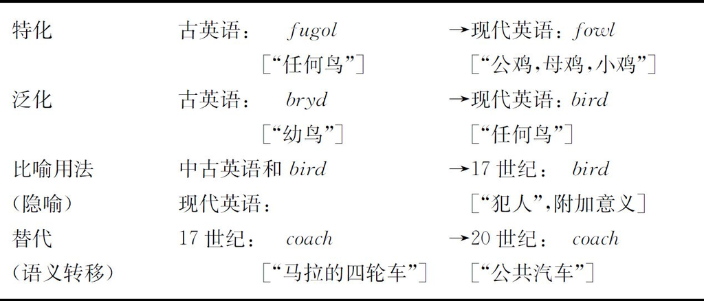

图7.4 传统观点的词汇演变的主要过程

正如这些例子所示，词汇演变可以对词义产生相当大的影响。但是由于某种原因，英语（以及其他语言）的词汇从未有被这些演变压垮的危险。语言似乎有一种内在的稳定性，即说话人可以依靠的一个意义核心。同时，语言似乎很灵活，足以使实质的词汇演变成为可能。

### 词汇范畴BIRD（鸟） 的发展

根据Geeraerts（1992，1997）的说法 <sup>(11)</sup> ，如果我们站在认知立场上，用原型范畴来理解词汇意义，那么词汇发展过程中稳定性与灵活性的共存就可以得到最好的解释。这意味着，我们第一章里关于原型范畴的内容与词汇演变的历史视角也有关。由于我们无法把Geeraerts广博的体系全部表现出来，因此我们将选择几个关键的方面，并用本书中一直陪伴着我们的那些例子来说明它们，我们从BIRD（鸟） 范畴开始。

图7.5说明了图7.4中所列的词汇演变的前三种类型：特化、泛化和隐喻，并显示了它们是如何影响BIRD（鸟） 的范畴结构的。该表的中心部分是第一章图1.8的简图，图1.8汇集了BIRD（鸟） 的范畴成员，或者更确切地说是BIRD（鸟） 的下位范畴，以及把这些成员联系在一起的属性。因为这些属性在现在这个图中没有显示，所以也许我们应该扼要重复一下，BIRD（鸟） 的典型属性绝大多数为范畴的中心成员（如＞ROBIN＜（知更鸟），＞SPARROW＜（麻雀），＞BLACKBIRD＜（乌鸫） ）所有，而较边缘的成员（如＞OSTRICH＜（鸵鸟），＞FLAMINGO＜（火烈鸟） ）具有少数的典型属性，并依靠家族相似性和其他次中心成员（例如鸵鸟、火烈鸟和天鹅、鹳一样，都有长长的脖子）相联系。考虑到传统上认为词汇演变牵涉一个词的整体意义，我们也许可以假设词汇演变也影响存在的整个范畴，包括范畴中心。看图7.5，你会发现情况并非如此。

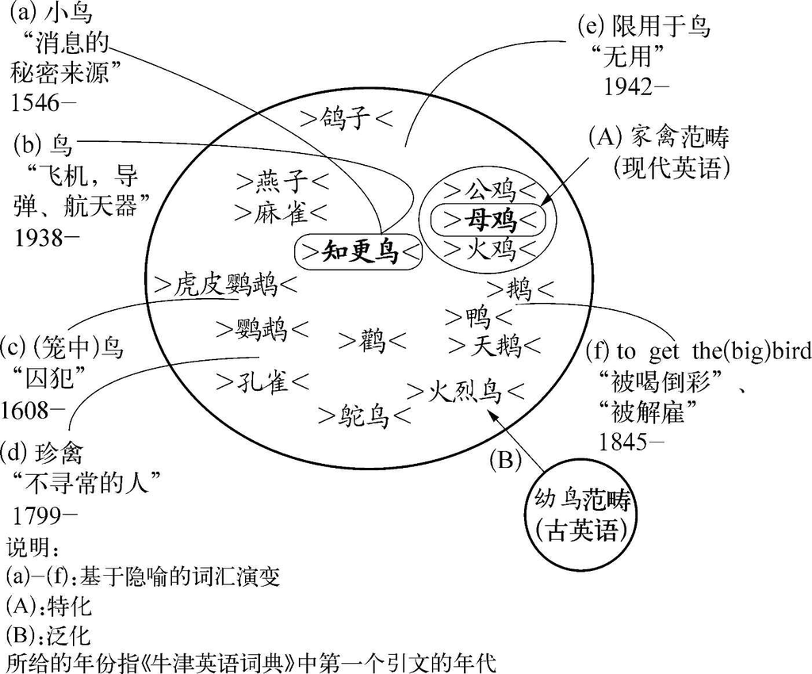

图7.5 关于BIRD（鸟）范畴的词汇演变的例子

先看隐喻演变，当然有这样的例子，它们映射基础是BIRD（鸟） 这个原型的属性，例如“啁啾或歌唱”，“小而轻”，“会飞”和“有翅膀”。这样，“提供秘密消息的小鸟”（例（a））着重于前三个属性（啁啾/轻/会飞），而“飞机”（b）这一隐喻用法则主要依靠后两个属性（会飞/有翅膀）。

然而大多数隐喻用法似乎源自把BIRD范畴的边缘统一起来的家族相似性，而不是源自范畴的中心。以用bird （鸟） 指囚犯（c）为例，它是由属性“关在笼子里”决定的。尽管这个隐喻也使人想起了鸟的很多其他特征，其中有中心属性“会飞”和“有翅膀”，但被关起来这种概念只是鹦鹉、虎皮鹦鹉及其他供观赏的笼中鸟的特点，不是所有的鸟都有的。用bird （鸟 ）指“不寻常或古怪的人”（d）似乎是着重于边缘属性“奇特的外表”，这适用于鸵鸟、火烈鸟、孔雀，也适用于鹦鹉和虎皮鹦鹉，而不适用于中心范畴成员。图中列在右边的例子甚至更极端。根据《牛津英语词典》中American Speech （美国语）的引文，限用于鸟（strictly for the birds ） （e），意思是“完全无用”，这个用法和“吃马粪或牛粪的鸟”有关。尽管很多种鸟显然也在粪和垃圾堆中寻找谷物和昆虫的幼虫，但这无疑不属于和BIRD这一范畴有关的最突出的属性。最后，get the big bird 用作“向演员喝倒彩”或“解雇某人”（f）的意思，则是源自鹅（但不是所有的鸟）发出的噪音。

回顾这些隐喻映射的例子，很容易看出它们实际上并不影响BIRD的范畴结构，更不用说改变它了。但是当整个部分从范畴中切除出来时，结果会是什么？BIRD这一范畴就经历了这个过程，当人们为了肉、蛋和羽毛而饲养母鸡和其他鸟时，它们汇集为一个独立的范畴。当BIRD范畴的原名，即古英语的fugol （现代英语fowl （家禽））被用来指这个新范畴时（见图7.5中的（A）），问题就更为复杂。

在古英语中，词语fugol 指所有种类的鸟。我们现在不确知在盎格鲁-撒克逊时代BIRD这个范畴的状况，因为很显然无法获得主要的范畴结构描写工具，即让被试排出样本合格性等级和列举属性。但是除了像鸵鸟和火烈鸟这样外表奇特的鸟外，大多数鸟在现存的古英语文本中都有所提及，因此我们可以假定那时的范畴结构和我们现在的并非完全不同。即使我们没有把握准确描述盎格鲁-撒克逊时代的原型，但是BIRD范畴好样本的主要属性可能和现在的相似。

那么，这个范畴名称转而指现代英语fowl 所指的BIRD范畴的边缘成员，这个范畴结构是如何历经这个转变保存下来的？传统的解释会说，fugol 被词语bird 代替，bird 的意义经历了泛化的过程（图7.4）。其背景是它的古英语形式bryd 已经用于有密切关系的YOUNG BIRD（幼鸟） 范畴（见图7.5中的（B））。这意味着即使在盎格鲁-撒克逊时代，bryd 里的范畴结构就包括了BIRD范畴所有主要的属性（正如古英语fugol 所表示的那样）。结果，这个范畴的中心区域就保持不变。它的稳定性保证了持续了几个世纪的从fugol 到bird 转换顺利完成。有段时间存在用bird 指较小的鸟的倾向，而fugol （或中古英语foule ）则越来越多地指较大的鸟，这使得转换过程更顺利。从认知上来说，这可以看作利用幼鸟的重要属性，即小这一属性的手段，看作帮助这个词语 bird （ 鸟） 从YOUNG BIRD（幼鸟） 范畴转换为BIRD（鸟） 范畴的拐杖。

总结一下我们关于BIRD（鸟） 范畴的历时讨论，范畴结构跨多个世纪而表现出来的稳定性的确给人留下了深刻的印象。主要原因似乎是范畴的中心区域，尤其是原型，在很大程度上未受隐喻演变的影响，甚至也未受涉及BIRD（鸟） 范畴的特化和泛化过程的影响。

### 原型转移和原型分裂：范畴COACH和IDEA

即使BIRD（鸟） 不是这样，也有范畴的核心属性被替换的情况，这通常是语言外部变化的结果。这在传统上被称为替代或语义转移（图7.4），恰当的认知术语是原型转移（prototype shift） 。COACH（四轮大马车） 这个范畴的历史为这个过程提供了一个相当直观的说明，如图7.6所示 <sup>(12)</sup> 。

词语coach 于16世纪引入英语，用来指大的、封闭的、四个轮子的、里外都有座位、马拉的车。在16和17世纪，这样的车主要是皇室和其他官员使用的。图7.6（a）说明了这种情况，图中范畴原型＞STATE CARRIAGE＜（贵宾马车） 用粗线圈起。但是正如＞STAGE COACH＜（公共马车） 的圆圈所示，随着马车越来越多地用来为普通公民常规的跨乡村服务，这第二个用法逐渐得到广泛使用。图（b）勾画了19世纪的情况，＞STAGE COACH＜（公共马车） 取代了＞STATE CARRIAGE＜（贵宾马车） 成为原型的下位范畴，但是把coach 用来指铁路客车这种技术创新的成果时，新的竞争就出现了。最后，在图（c）中，为了帮助＞MOTOR COACH＜（公共汽车） 成为新的原型，＞STAGE COACH＜（公共马车） 被推向了范畴边缘，这再次反映了工业技术的发展。

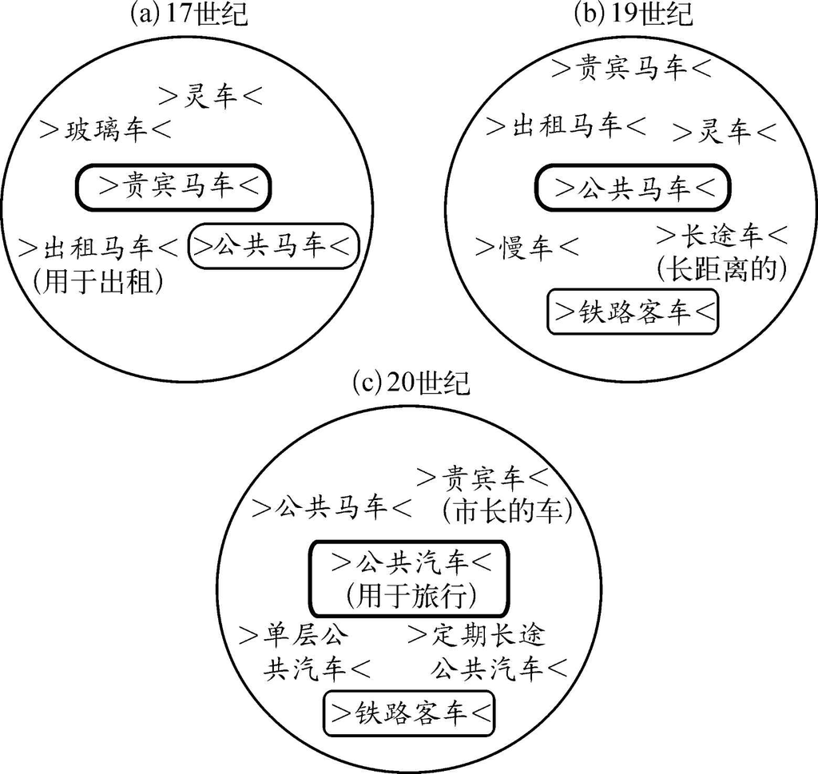

图7.6 原型转移：COACH范畴的发展

面对这个原型的概念内容所发生的这些巨大的变化，尤其是从＞STAGE COACH＜（公共马车） 到＞MOTOR COACH＜（公共汽车） 的变化，语言使用者受到的干扰是那么小，这是令人惊讶的。尽管原型发生了转移，但概念结构看起来似乎保持不变。如何解释这种显著的稳定性？

从认知的角度看，主要的原因是大多数重要属性，如“用于客运”，“大而封闭的车厢”，“有四个轮子”，“里面有座位”，都从老的范畴原型转到了新的范畴原型上了。在这些属性中，最重要的是“用于客运”这一功能属性。这个属性似乎已经把范畴成员拢在一起，即使其他方面的属性发生显著的变化。这种变化有一个例子是“动力来源”方面的发展，该属性从＞公共马车 ＜（＞STAGE COACH＜）的“马拉”，经过＞铁路客车 ＜（＞RAILWAY CARRIAGE＜）的“机车拖行”，再变到＞公共汽车 ＜（＞MOTOR COACH＜）的“自动推进”。这方面属性的发展变化确实显著。然而它并没有导致范畴完整性的瓦解，因为“用于客运”这一功能属性和上面提到的其他属性的联合力量取得了胜利。

但是有一个例外。如我们所见，尽管coach 用作铁路客车可能满足了＞STAGE COACH＜（公共马车） 和＞MOTOR COACH＜（公共汽车） 之间的转换功能，但它反映出另一方面的新的背离。不像所有其他类型的车，铁路客车不能当作一个独立的单位单元使用，它不在公路上而在铁路上运行。尽管它们有共同的功能，如今公共汽车和铁路客车之间的差别一清二楚，以至于coach 用于指＞RAILWAY CARRIAGE＜（铁路客车） 的用法可以看作是分裂出了另一个原型。

这样的原型分裂（prototype splits） 在具体物体领域中并不常见，但在抽象范畴中则常见得多。看看第三章3.1节隐喻部分已经论述过的IDEA（思想） 这个范畴的演变，就可以证明这一点。在那一节中，我们试图说明某些隐喻（＋CONTAINER＋（＋容器＋） 隐喻，＋OBJECT＋（＋物体＋） 隐喻等等）如何影响这个大致可解释为“思想”（‘thought’）的范畴IDEA的全面的范畴化。为了得出更为细微的、也与历史相关的概念差别，我们首先应该看看图7.7中的例句。

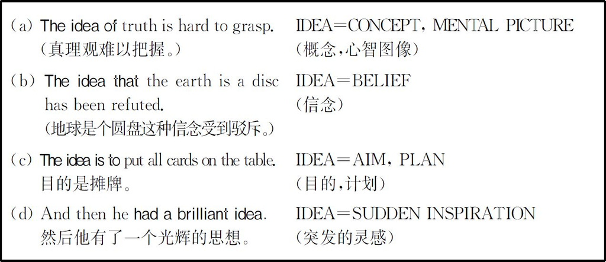

图7.7 IDEA（思想）范畴：例句和语义标签

粗略一看这些例子和附着其上的语义标签就能明白，变体（a）得到最普遍的语义标签，而变体（b）到（d）则被赋予更具体的释义。在认知语境中，可以认为这些标签大致表示了原型，因而我们期望每个标签都能代表定义不够清楚的例子（或者次要的范畴成员；Schmid 1993：188以次）。为了介绍历史视角，必须指出：尽管出于方便，所有例句都取自当代英语，但事实上这些例句确实反映了自15世纪词语idea 进入英语以来，IDEA这个范畴所经历的阶段性。如果我们认为这暗示着从一个全局性的原型演变到更具体的“局部性”原型，我们就可以把这个发展过程理解为原型分裂的一个实例。对照图7.8，这个图的基础是对《牛津英语词典》中例子的分析（Schmid，1996b）。

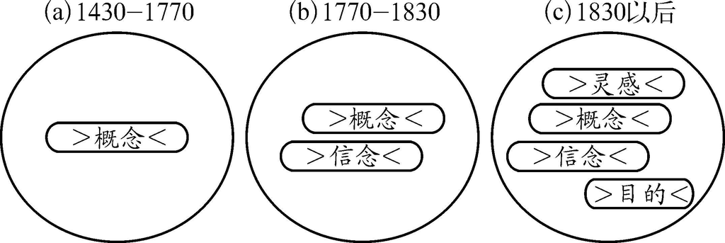

图7.8 原型分离：IDEA范畴的演变（Schmid，1996b）

如果把图7.8与图7.5及图7.6（分别讨论范畴BIRD（鸟） 和COACH（四轮大马车） ）进行比较，任何关于抽象范畴结构的说明显然都比对具体物体范畴的描述要笼统得多。在缺乏明确的属性以及多数概念隐喻的模糊性面前，没有可靠的语义标准可以作为IDEA（想法） 这个范畴的历史描写的基础，更不用说对它的稳定性进行评估了。

唯一可获得的参数似乎是idea 这样的抽象词语出现的句法环境。IDEA（想法） 范畴的历史中最古老的原型，即原型＞CONCEPT＜（＞概念＜） ，和句法结构the idea of 有紧密的联系。原型＞BELIEF＜（＞信念＜） 和the idea that 这个构式联系在一起，原型＞AIM＜（＞目的＜） 和the idea is to 有关，最后，原型＞SUDDEN INSPIRATION＜（＞突发的灵感＜） 则和have/get an idea 这一结构相联系（见图7.7，这些结构用粗体字表示）。正如对《牛津英语辞典》中IDEA例子的分析所示，处理抽象范畴的“语境法”在描写词汇演变时是可行而有用的，也能解释某些构式的出现（见5.4节关于外壳-内容构式的部分）。

如果你在本节末尾回顾一下这个讨论开始时的传统分类，有一点就应该变得非常明确，即总体而言，认知语言学给词汇演变提供了更丰富的描写，开辟了一条有益的可以进一步探索的研究道路 <sup>(13)</sup> 。

### 练习

1．正如Geeraerts（1997：33-41）指出的，词汇发展的稳定性在最新词汇增加的“快速运动”中也能得到证明。他的用例是荷兰语概念LEGGING，自1988年引入后，在增加另外的表示不同类型的材料之类的东西的同时，仍保持着原型的相对固定。用这个方法来分析MOBILE PHONE（手机） 这一概念，看一看因尺寸、形状、颜色、附加的电子功能和设备、电池托架等因素的改变而增加附加意义时，其核心意义是否也保持稳定。

2．在古英语中，词语man 指称人类，而“male human being”（男人）通常用另一个词表达（古英语的wer ）。与man 现在的用法进行对比，并根据原型范畴来讨论有关的语义演变。跟fugol/fowl 的演变进行对比可能会有帮助。

讨论如今备受批评的man 表现性别歧视的用法是从盎格鲁-撒克逊时代就存在于这种语言中呢，还是说它是较现代的产物。

3．这里是《牛津英语辞典》中car 词条的摘录：

1．A wheeled vehicle or conveyance（带轮子的交通或运输工具）

a．generally — a carriage，chariot，cart，wagon，truck，etc．（quotations from the fourteenth to the eighteenth century）（通常——四轮马车、二轮战车、马车、小型客车、卡车，等（引自14至18世纪文献））

b．From sixteenth to nineteenth century，chiefly poetic with associations of dignity，solemnity and splendor．Applied also to the fabled chariot of Phaeton or the sun …（从16至19世纪，主要用于诗体，产生体面、庄重、壮观的联想。也用于神话中法厄同（太阳神之子）的二轮战车或太阳……）

d．transf ．a miniature carriage or truck used in experiments，etc．（quotation from the nineteenth century）（转义。实验用微型四轮马车或运货车等。（引自19世纪文献））

e．＝motor car（quotations from the late nineteenth and the twentieth century）（汽车。（引自19世纪末到20世纪的文献））

4．a．The part of a balloon in which aeronauts sit（quotations from the eighteenth and the nineteenth century）（气球上驾驶员坐的部分（引自18、19世纪文献））

b．The cage of a lift．Chiefly U.S．（quotations from the nineteenth and the twentieth century）（电梯间。主要用于美国英语（引自19和20世纪文献））

试以这些信息为基础勾勒出这个范畴结构的发展变化。

4．通过分析《牛津英语辞典》中的词条，勾勒名词liquor （烈酒） 和sensation （感觉） 中的概念的发展。你能发现原型转移（就liquor 而言）或者原型分裂（就sensation 而言）的证据吗？

## 7.3 语法化的认知方面

除了词汇演变，语法形式（时标记、复数标记和格标记等）的起源和发展过程是语言学长期关心的问题。这时证明，认知理论不但有助于解释个别语法形式的发展，而且似乎也能为全部的语法化过程提供一个框架。

在19世纪，对语言的语源的普遍兴趣激发了对语法形式发展过程的研究。“语法化”这个术语可能是法国语言学家Meillet首次使用的。根据Meillet（1912）的看法，研究语法化的目的在于探索“自主的词转变为语法成分的角色”（1912：133），或者用较近的定义，是表明“词汇单位……在何处承担了一项语法功能，或一个语法单位在何处承担了一项更具语法性质的功能。”（Heine 等1991：2） <sup>(14)</sup> 。从认知语言学视角来解释这两个阶段的第一个阶段，即从词汇单位向语法形式的转变这个阶段，似乎是最令人满意的。

### 位移事件，语法化中的隐喻和转喻

我们的测试用例子是英语中语法化最著名的例子之一：实义动词go （去）演变成用来表达将来时的助动词 <sup>(15)</sup> 。认知分析合适的起点是Talmy（2000）提出的位移事件概念。如4.1节和5.2节所示，一个位移事件基本上可以看作是主体在背景上移动的路径。假设有一条从A通往B的开放路径，主体（或射体）的移动总是指向终点B，换句话说，它有目标取向的特点。同时，射体的位置只有沿着路径不断变化，才能到达目的地或目标，这个发现证明了“动作/变化＜＞位移”（见3.1节）这种基本的相互关系。主体及其路径与背景形成对照，背景充当方向的参照点或“界标”，并且通常受说话人对世界现状看法的制约；这可以在“（当前）视点＜＞界标”这种相互关系中获得。

用这种方式分析位移事件，我们已经汇集了三个方面，即目标取向、变化和视点，它们将在所谓的going-to 将来时的语法化中起着重要作用。为了使说明完整，我们应该考虑：射体的路径可以在概念上通过不同的注意力视窗来获取。Talmy自己的路径-视窗的开启的例子是：

The crate that was in the aircraft's cargo bay fell out of the plane through the air into the ocean.（见图5.10）

（飞机货舱中的板条箱掉出了飞机，从空中落到大海里。）

在这个例子中，汇集了路径-视窗开启所有的三种可能性：开启起始视窗（out of the cargo bay ），开启中间视窗（through the air ），开启结尾视窗（into the ocean ），但最后一种可能性更大，也是相当清楚的。对位移动词go来说，情况更是如此，它最可能和指称具体目的地的趋向状语相结合，而起始和中间视窗则被隔断，如例（1）所示。

Susan's going to London next month．

（苏珊下个月去伦敦。）

She's going to hospital/college/prison．

（她要去医院/学院/监狱。）

She's going to London to work at our office．

（她要去伦敦到我们办公室工作。）

She's going to work at our office．

（她要去我们办公室工作。）

You're going to like her．

（你会喜欢她的。）

You're going to be friends．

（你们会成为朋友的。）

You're gonna like her．

（你会喜欢她的。）

You gonna like her．（非标准英语）

（你会喜欢她的。）

根据语法化，例（1）代表这个过程的第一阶段，对照图7.9，它选择了“开启结尾视窗”，并把“终点”选为前景。例（2）和例（3）显示了位移事件的前景化方面如何导致概念的扩展：具体目的地“可用其有关的目的来限定”（《牛津现代高级英语辞典》）（就像例（2）中的医院、学院 或监狱 这类“目的地”）；如果加上与趋向状语多少有点密切关系的目的状语（如例（3）中的to work at our office ），那就出现了第二种扩展。两个例子都强调位移事件的目标取向并因此指出目的地这个概念在语法化过程的第二阶段可向哪个方向扩展。如图7.9所示，第二阶段可以理解为一种转喻转移，其基础是＋目标取向的移动代表有意的行为＋（＋GOAL-ORIENTED MOVEMENT STANDS FOR INTENDED ACTION＋）这种关系，对于这种关系，“部分-整体”意象图式和“目的＜＞目标”（见3.1节）这种基本经验关系决定了它的映射域。受这个映射域控制，目标取向的移动 （GOAL-ORIENTED MOVEMENT）这一源概念与有目的的或有意的行为 （PURPOSEFUL OR INTENDED ACTION）这一更宽的目标概念（如例（4）中的going to work at our office ）发生了概念转喻关系。因为有目的的或有意的行为这种概念是伴随将来设定的期望一起出现的，所以is going 这一动词形式就在这个构式中获得了将来时特征。反过来，将来时和其他时态一样，在英语中通常用助动词表达，因此，出现从going-to 将来时到助动词地位的降格，也就不足为奇了。

在这个层次的语法化的基础上，产生了一个隐喻扩展（图7.9中的第三阶段），在这个扩展中，有意的将来行为 （INTENDED FUTURE ACTION）这个源概念转移到断定的将来状态 （PREDICATED FUTURE STATE）这一目标概念上——或者，用通常使用的给隐喻加标签的格式，可表示为＋断定的状态是有意的行为＋（＋PREDICATED STATE IS INTENDED ACTION＋）。比较例（5）和例（6），挚爱的态度或友谊的状态是建立在说话者评价基础上的断言。这个隐喻映射再次受到以其位移事件（下面要较详细讨论的一个话题）为基础的映射域的控制。

和第二、第三阶段相比，最后一个阶段（第四阶段，由例（7）和（8）代表，但不在图7.9中）不再改变其意义，而只是记录随着最后降格为助动词地位而发生的音系和书写的变化。

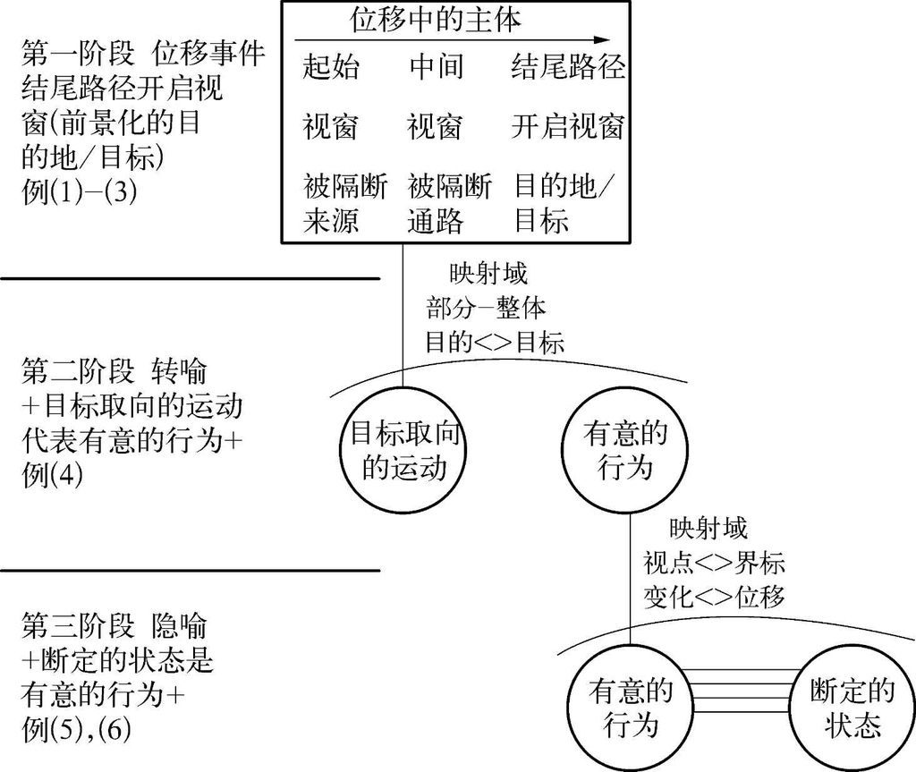

图7.9 going-to 将来时语法化的认知观：第一至第三阶段

传统的描写把第二阶段刻画为句法的重新分析（而不是转喻），把第三阶段刻画为类推（而不是隐喻），与这种传统的描写相比，这种认知解释有什么优点？看来，认知解释不仅阐明了与going to 的语法化有关的语义演变，还对描写这个过程的限制因素特别有用。

再看看图7.9中位移事件的表征，为什么这个语法化过程选的是go 这个位移动词，而不是leave （离开 ）（着重于开启起始视窗或位移的起点）、pass （经过 ）（强调中间视窗或通路）或stagger （蹒跚 ）、ride （骑 ）和fly （飞 ）（三个都特别强调位移的方式这种成分）之类的其他位移动词，也就昭然若揭了。只有像go 一样强调结尾路径视窗的动词才具有目标取向，才使得添加具有内在意图潜势的不定式（而不是分词或动名词）成为可能。最后，也许更有趣的是，位移事件也决定着＋断定的状态是有意的行为＋（＋PREDICATED STATE IS INTENDED ACTION＋）这一隐喻的映射域如何把握熟练的英语说话人使用going-to 将来时的时候仍感到的限制。正如本节开头所示，“（当前）视点＜＞（位移事件的）界标”这一基本相互关系意味着以当前时间一定有用来建立预言某种参照点，或者是现在的评价（如例（5）和例（6）），或者是现在的观察结果或证据，如证明It's going to rain （要下雨了 ）的作为预兆的云。其次，以我们对沿着路径移动的射体的概念化为基础的“变化＜＞位移”这一相互关系把going-to 将来时的预言用法限于用来表示人的好恶（本质上是非永久而易于变化，见例（5））这种态度和不排斥变化观念的状态。这个映射限制解释了（6）You are going to be friends （你们会成为朋友的 ）这类例子为什么完全可以接受，而The earth is going to be round for ever （地球将永远是圆的 ）却不可接受。

尽管going-to 将来时的出现也许是最好的例子，但是，动词的分词given 、provided 、granted 和祈使式的suppose 演变为条件连词之类的其他语法化过程也能得益于认知分析（另见后面的练习1）。然而，正如前边所主张的那样，只有把认知观点用作整个语法化过程的统一框架的时候，它真正的解释力才会明显起来。这正是Heine在描述时、体和语气标记的演变时想努力做到的（Heine 1993）。

### 语法化的认知框架

Heine的出发点是一个所谓的命题图式（propositional schemas） 系统 <sup>(16)</sup> ，这些图式表征过程和事件，它们由三个成分组成，是传统句型和构式语法中很著名的结构（见5.4节）。虽然很多过程和它们的命题图式是相当具体的（如X EAT Y（X吃Y）或X WRITE Y（X写Y）），但是其中也有一些，如X GO Y（X去Y），X COME Y（X来Y），X BE AT Y（X在Y）等则要一般得多，语法范畴也正是从这些一般的命题图式发展而来的。

图7.10汇集了在很多语言体和时态中的主要命题图式。如图所示，这些图式可以分为两组：三个基本图式（即：方位（Location），位移（Motion），动作（Action））和一些由这些基本图式派生出来的图式（即：等式（Equation），伴随（Accompaniment），拥有（Possession），方式（Manner），状态变化（Change of State），意愿（Volition））。尤为显著的是作为派生图式的主要来源的方位图式的作用；这一判断得到了长期存在的方位主义思想的非认知主义者传统的支持，也与空间是我们主要的体验领域这个日常发现相一致。

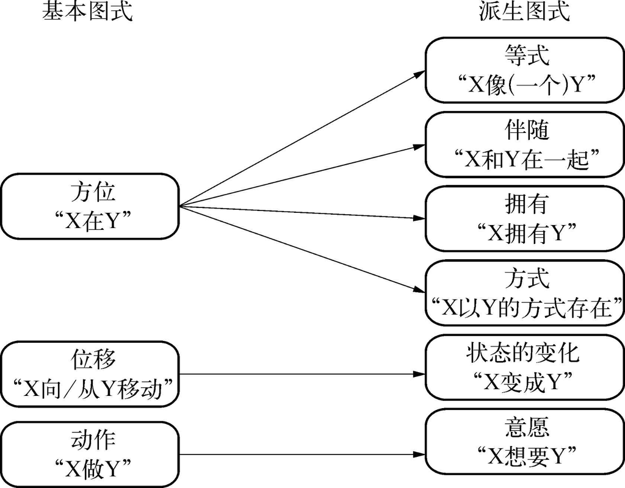

图7.10 构成体和时语法范畴基础的主要命题图式（摘自Heine的事件图式，Heine 1993：图2.1）

说到由个别命题图式引起的这种语法过程（比较图7.11），我们发现其中有一些是十分明显的：意愿产生将来时（英语中的will- 将来时），状态变化也产生将来时（德语中的werden （＝“变成”）-将来时）；很多非洲语言记录了伴随发展成为进行体标记。其他的命题图式，尤其是基本图式，语法化的可能性比较模糊。所以，位移图式既可用于向前，也可用于向后看，从而产生了将来时或完成体和过去时。而动作图式则可能用来表达进入体（动作的开始）和动作的完成。如果考虑到这些相互冲突的语法化类型，那么，各种语言从一个共同的概念基础发展出相当不同的时/体系统也就不足为奇了 <sup>(17)</sup> 。

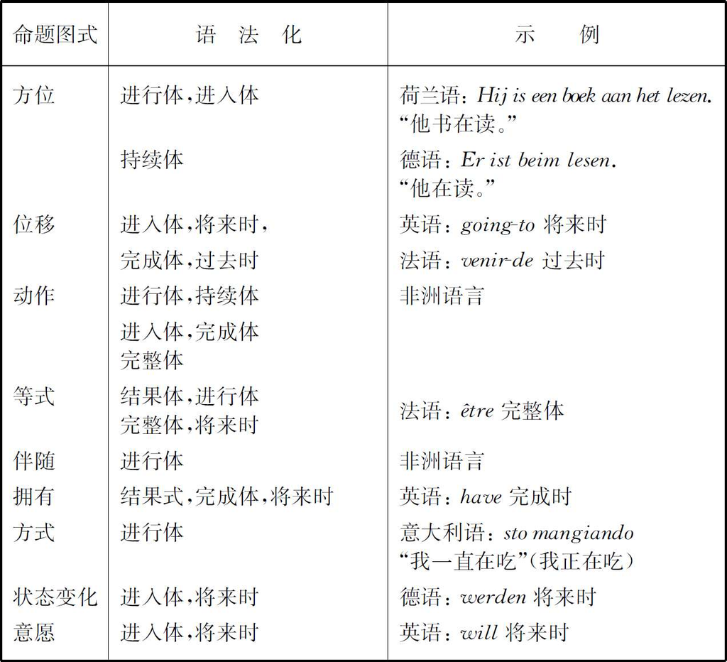

图7.11 命题图式及可能的语法化（摘自Heine 1993：47）

在结束这一节之前，我们要给近年来热烈讨论的一个问题加个注释，也就是这个问题：语法化是否应当看成从词汇单位向具有语法功能的单位，并从语法功能向更虚的语法功能发展的单向过程。在我们看来，就本节集中讨论的第一阶段来说，认知分析似乎证明了从词汇单位向语法单位的单向演化。有些情况下，从一种语法功能向另一个语法功能的转换（如从连接主要小句的副词到从属连词）是否不可逆转是另一个问题。不过，从我们的观点来看，可以说的是即使从语法项到词汇项的“去语法化”（de-grammaticalization）这种反向演变的例子应该得到揭示，但认知语言学家也应该有充分的准备去处理这些语言现象。

### 练习

1．在下列例子中，如何区分GIVE和GRANT的概念意义？试用语法化解释这些概念和功能的变化。

Aunt Mable gave me a piece of cake．

（梅布尔阿姨给了我一块蛋糕。）

We waited for him at the given place and time，but he didn't come．

（我们在指定的地点和时间等他，但他没有来。）

Given her youth，she is quite experienced in the field．

（考虑到她年轻，她在这个领域是相当有经验的了。）

Given that he has lost all his money gambling，he is still surprisingly optimistic．

（考虑到他赌输了所有的钱，他仍然惊人地乐观。）

Regrettably，the bank didn't grant me the loan．

（令人遗憾的是，银行没有同意给我贷款。）

It's an ingenious project，I grant you，but will it work？

（我承认，它是一项别出心裁的计划，但是它会行得通吗？）

Granted，it's not a perfect cake，but it should be edible．

（诚然，它不是一个完好的蛋糕，但它应该可以吃。）

Granted（that）your grandfather was rich，why didn't he pay for your education？

（假定你爷爷很富有，那他为什么不供你上学？）

2．英语的后缀-ly 和-like 的基础都是意为“appearance”，“form”，“body”的日耳曼语词根。比较fishlike/fishy ，foxlike/foxy ，roomlike/roomy 之类的词对，指出这种源范畴在哪些地方还更加活跃，从语法化角度看，这又意味着什么。

3．皮钦英语，一种在世界各地接触状态中讲的初级语言，据说代表了语法化的早期阶段，其中的语法标记的源范畴仍很容易辨认。试找出下面喀麦隆皮钦语中的语法标记是以哪些英语词（及其中存在的范畴）为基础的：

| go | （将来时标记） |
| --- | --- |
| don | （肯定的完整体标记） |
| neva | （否定的完整体标记） |
| sei | （引导间接言语的成分） |
| fit | （情态助动词‘can’） |
| mek | （引导礼貌祈使句的成分） |

4．如果你的母语不是英语，找出在你自己的语言中，哪些时态形式、情态形式和表达领有的方法是建立在位移和动作图式基础上的（亦见图7.11）。